# Entrega final · ¿Cuántos buses despachar y cada cuánto?

**Data Challenge Pro Extreme – Sobusa 2026** · Machine Learning, Pregrado en Ciencia de Datos, Universidad del Norte

**Equipo:** Abrahan Basto Martínez, Rubén Esguerra Fernández y Paula Gómez · Universidad del Norte, Barranquilla, Colombia.

Este cuaderno cuenta el proyecto completo con código: el problema, los datos, la tabla de modelado, el modelo de pronóstico **entrenado aquí mismo**, su evaluación frente a la regla que usa Sobusa hoy, el optimizador que convierte el pronóstico en salidas por hora (también **ejecutado en vivo**), lo que esa decisión gana y arriesga, lo que todavía no sabemos y el piloto para medirlo.

**Reglas del cuaderno.**

- No se conecta a la base de datos del reto (compartida y de solo lectura): todo sale de archivos locales del proyecto.
- Ninguna cifra está escrita a mano. Cada número del texto se calcula en una celda anterior o se lee del archivo de resultados que lo produjo, y se contrasta con el mapa verificado de cifras de la app (`app/DATOS.md`) y con el informe (`documentos/informe_resultados.md`). La tabla de contraste está en la sección 8.
- Semilla 42. Corre de principio a fin en pocos minutos en un portátil (el tiempo exacto se imprime al final).
- No usa datos personales: no hay identificadores de conductores ni de vehículos.

## Índice

0. Preparación
1. El problema y los datos
2. La tabla de modelado y las variables
3. El modelo en vivo: un pliegue del protocolo
4. La evaluación completa · 4.1 Error global · 4.2 Por ruta, tipo de día y mes · 4.3 Un mes, día a día · 4.4 Híbrido frente al modelo final · 4.5 La comparación de 51 modelos
5. La decisión: el optimizador D5 · 5.1 Un día en vivo · 5.2 El plan de todo 2025 · 5.3 El canje y la elasticidad β
6. Lo honesto: lo que el plan todavía no sabe
7. El piloto para medir β
8. Conclusiones y recomendaciones para Sobusa · Contraste de cifras
9. Cómo reproducir y dónde está cada cosa

**Cómo ejecutarlo** (desde la carpeta `EntregaFinal/`, con las versiones de `requirements_cuaderno.txt`):

```
python -m nbconvert --to notebook --execute --inplace --ExecutePreprocessor.timeout=1800 entrega_final.ipynb
python -m nbconvert --to html entrega_final.ipynb
```

Necesita la carpeta `datos/` del proyecto (Parquet del ETL de la Entrega 1; no se versiona) y los resultados guardados de los experimentos (`experimentos/`, `costos/`, `simulacion_ahorro/`, `sistema_tiempo_real/`).

## 0. Preparación

Bibliotecas, localización de la raíz del proyecto (el cuaderno funciona abierto desde `EntregaFinal/` o desde la raíz), formato de números en español, colores y tres utilidades: lectura de los archivos de resultados, el lector de `app/DATOS.md` y la función `verificar`, que compara cada cifra calculada con la que ese mapa registra (con la precisión con que la registra).

Colores de todas las figuras: **real** en negro, **regla manual** en gris, **E1** (primer modelo) en ámbar, **modelo final** en turquesa y **híbrido** en índigo.

```python
%matplotlib inline
import sys, os, re, json, time, gzip, base64, platform, warnings
from pathlib import Path

sys.dont_write_bytecode = True                     # no dejar __pycache__ en las carpetas del proyecto
warnings.filterwarnings("ignore")
import numpy as np
import pandas as pd
import matplotlib
import matplotlib.pyplot as plt
import matplotlib.dates as mdates
from matplotlib.ticker import FuncFormatter
from IPython.display import display, Markdown

T0 = time.time()
SEMILLA = 42
np.random.seed(SEMILLA)


def _es_raiz(p):
    return (p / "experimentos" / "E11_modelo_mejorado" / "comun_e11.py").exists() and (p / "Entrega1" / "tablas").exists()


RAIZ = next((p for p in [Path.cwd(), Path.cwd().parent, Path.cwd().parent.parent] if _es_raiz(p)), None)
if RAIZ is None:
    raise FileNotFoundError("Abra el cuaderno desde la carpeta EntregaFinal/ o desde la raíz del proyecto.")
EXP = RAIZ / "experimentos"
E11 = EXP / "E11_modelo_mejorado"
E12 = EXP / "E12_comparacion_modelos"
COSTOS = RAIZ / "costos" / "resultados"


def rel(p):
    """Ruta relativa a la raíz del proyecto (el cuaderno nunca muestra rutas absolutas)."""
    return Path(p).resolve().relative_to(RAIZ.resolve()).as_posix()


# ---------------- formato de números en español ----------------
MENOS = "−"


def num(x, d=0, signo=False):
    """1234.5 -> '1.234,5'; negativos con el signo menos tipográfico; signo=True antepone '+' a los positivos."""
    if x is None:
        return "—"
    x = float(x)
    if not np.isfinite(x):
        return "—"
    s = f"{abs(x):,.{d}f}".replace(",", "X").replace(".", ",").replace("X", ".")
    if x < 0 and set(s) - set("0,."):
        s = MENOS + s
    elif signo and x > 0 and set(s) - set("0,."):
        s = "+" + s
    return s


def pct(x, d=1, signo=False):
    return num(x, d, signo) + " %"


def ic(a, b, d=2):
    return f"[{num(a, d, True)}; {num(b, d, True)}]"


def horas_txt(hs):
    hs = [str(int(h)) for h in hs]
    if not hs:
        return "ninguna"
    return (", ".join(hs[:-1]) + " y " + hs[-1] if len(hs) > 1 else hs[0]) + " h"


def md(texto):
    display(Markdown(texto))


def tabla(df, dec=2, enteros=()):
    """Muestra un DataFrame con los números en formato español."""
    out = df.copy()
    for c in out.columns:
        s = out[c]
        if pd.api.types.is_bool_dtype(s):
            out[c] = s.map({True: "sí", False: "no"})
        elif pd.api.types.is_numeric_dtype(s):
            d = 0 if c in enteros else (dec.get(c, 2) if isinstance(dec, dict) else dec)
            out[c] = s.map(lambda v, d=d: num(v, d))
    display(out)


# ---------------- lectura de archivos de resultados ----------------
def leer_json(p):
    return json.loads(Path(p).read_text(encoding="utf-8"))


def leer_csv_es(p):
    """CSV con ';' y coma decimal (los de costos/, simulacion_ahorro/ y replay/dias/calles/)."""
    return pd.read_csv(p, sep=";", decimal=",", encoding="utf-8-sig")


def a_float(x):
    return float(str(x).replace(",", "."))


def leer_js(p):
    """Archivo .js de la forma 'window.X = {...};' -> dict."""
    s = Path(p).read_text(encoding="utf-8")
    return json.loads(s[s.index("=") + 1:].strip().rstrip(";"))


def leer_calles(fecha):
    """Día del modelo persona a persona de la vista 3D (sistema_tiempo_real/replay/dias/calles/AAAA-MM-DD.js, JSON comprimido)."""
    s = (RAIZ / "sistema_tiempo_real" / "replay" / "dias" / "calles" / f"{fecha}.js").read_text(encoding="utf-8")
    return json.loads(gzip.decompress(base64.b64decode(re.search(r'=\s*"([^"]+)"', s).group(1))))


def wape(y, p):
    """WAPE = suma de errores absolutos / suma de lo real, en %."""
    y, p = np.asarray(y, float), np.asarray(p, float)
    m = ~np.isnan(y) & ~np.isnan(p)
    return float(np.abs(y[m] - p[m]).sum() / y[m].sum() * 100)


# ---------------- mapa verificado de cifras de la app (app/DATOS.md) ----------------
_RX_NUM = re.compile(r"^[-−]?(\d{1,3}(\.\d{3})+|\d+)(,\d+)?$")


def _cifra(s):
    s = s.strip()
    if s in ("sí", "no"):
        return (s == "sí", None)
    if not _RX_NUM.match(s):
        return None
    dec = len(s.split(",")[1]) if "," in s else 0
    return (float(s.replace("−", "-").replace(".", "").replace(",", ".")), dec)


def cargar_datos_md(p):
    out = {}
    for linea in Path(p).read_text(encoding="utf-8").splitlines():
        if not linea.startswith("| `"):
            continue
        c = [x.strip() for x in linea.replace("\\|", "¦").strip().strip("|").split("|")]
        if len(c) < 8:                              # tabla de «cifras ausentes»: solo id y motivo
            continue
        valor = _cifra(c[2])
        if valor is None and c[2].startswith("{") and c[2].endswith("}"):
            valor = {}
            for par in c[2][1:-1].split(";"):
                if ":" in par:
                    k, v = par.split(":", 1)
                    valor[k.strip()] = _cifra(v)
        out[c[0].strip("`")] = dict(que=c[1], texto=c[2], valor=valor, archivo=c[4].strip("`"), clave=c[5])
    return out


DATOS_MD = cargar_datos_md(RAIZ / "app" / "DATOS.md")
INFORME = (RAIZ / "documentos" / "informe_resultados.md").read_text(encoding="utf-8")
VERIF = []
SECCION = "0"


def verificar(ident, calculado, clave=None):
    """Compara un valor calculado en el cuaderno con el de app/DATOS.md (id y, si es un objeto, su clave),
    con la precisión con que DATOS.md lo registra."""
    fila = DATOS_MD.get(ident)
    ref = None if fila is None else fila["valor"]
    if clave is not None:
        ref = ref.get(clave) if isinstance(ref, dict) else None
    if ref is None:
        ok, ref_txt, calc_txt = None, "—", num(calculado, 4)
    elif isinstance(ref[0], bool):
        ok = bool(calculado) == ref[0]
        ref_txt, calc_txt = ("sí" if ref[0] else "no"), ("sí" if calculado else "no")
    else:
        v, d = ref
        # DATOS.md muestra el valor guardado (6 cifras significativas bajo 1.000) redondeado otra vez: se admiten los dos redondeos
        tol = 0.5 * 10 ** (-d) + (0.5 * 10 ** (np.floor(np.log10(abs(v))) - 5) if 0 < abs(v) < 1000 else 0.0)
        ok = abs(float(calculado) - v) <= tol * 1.0001 + 1e-9
        ref_txt, calc_txt = num(v, d), num(calculado, d)
    VERIF.append({"sección": SECCION, "cifra": ident + (f" · {clave}" if clave else ""),
                  "qué es": (fila["que"][:95] + ("…" if len(fila["que"]) > 95 else "")) if fila else "(no está en DATOS.md)",
                  "calculado": calc_txt, "referencia": ref_txt, "fuente de la referencia": "app/DATOS.md", "coincide": ok})


def verificar_ref(nombre, calculado, referencia, fuente, tol=1e-9, dec=4):
    """Compara un valor calculado con el que guarda un archivo de resultados (la fuente que DATOS.md cita)."""
    if isinstance(referencia, (bool, np.bool_)):
        ok = bool(calculado) == bool(referencia)
        c, r = ("sí" if calculado else "no"), ("sí" if referencia else "no")
    else:
        ok = abs(float(calculado) - float(referencia)) <= tol
        c, r = num(calculado, dec), num(referencia, dec)
    VERIF.append({"sección": SECCION, "cifra": nombre, "qué es": "", "calculado": c, "referencia": r,
                  "fuente de la referencia": fuente, "coincide": ok})


def mostrar_verif():
    v = pd.DataFrame([x for x in VERIF if x["sección"] == SECCION])
    if v.empty:
        return
    n_ok = int((v["coincide"] == True).sum())  # noqa: E712
    v = v.drop(columns="sección").assign(coincide=v["coincide"].map({True: "sí", False: "NO", None: "sin valor"}))
    md(f"**Contraste de las cifras de esta sección:** {n_ok} de {len(v)} coinciden con su referencia.")
    display(v.set_index("cifra"))


# ---------------- estilo de las figuras ----------------
REAL, GRIS, AMBAR, TURQ, INDIGO = "#111111", "#8e8e93", "#d97706", "#0e7974", "#5856d6"
GRIS_CLARO, TINTA = "#c7c7cc", "#3a3a3c"
plt.rcParams.update({"figure.dpi": 100, "savefig.dpi": 100, "font.size": 10, "axes.titlesize": 11, "axes.titleweight": "bold",
                     "axes.labelsize": 10, "axes.spines.top": False, "axes.spines.right": False, "axes.grid": True,
                     "grid.color": "#e5e5ea", "grid.linewidth": 0.7, "axes.axisbelow": True, "legend.frameon": False,
                     "lines.linewidth": 2, "axes.edgecolor": "#8e8e93", "xtick.color": TINTA, "ytick.color": TINTA})
FMT_MILES = FuncFormatter(lambda v, _: num(v, 0))
FMT_PCT = FuncFormatter(lambda v, _: num(v, 0) + " %")
MESES = ["enero", "febrero", "marzo", "abril", "mayo", "junio", "julio", "agosto", "septiembre", "octubre", "noviembre", "diciembre"]
ORDEN_RUTAS = ["SILENCIO", "CRA 54", "CL 72"]
TIPOS = ["Laboral", "Sábado", "Domingo/festivo"]
pd.set_option("display.max_colwidth", 140)
pd.set_option("display.width", 200)
md(f"Raíz del proyecto localizada (el cuaderno corre desde `{Path.cwd().name}/`). Python {platform.python_version()}, "
   f"pandas {pd.__version__}, numpy {np.__version__}. `app/DATOS.md` trae {len(DATOS_MD)} cifras con su archivo y su clave.")
```

Raíz del proyecto localizada (el cuaderno corre desde `EntregaFinal/`). Python 3.13.3, pandas 3.0.5, numpy 2.5.2. `app/DATOS.md` trae 202 cifras con su archivo y su clave.

## 1. El problema y los datos

**El problema.** Sobusa opera tres rutas de bus entre Soledad y Barranquilla (SILENCIO, CRA 54 y CL 72). Hoy programa cada ruta y cada hora con una regla manual: **el promedio de las 8 semanas anteriores**, misma ruta, misma hora y mismo día de la semana. El reto pide decidir **cuántos buses despachar y cada cuánto** según la demanda. Lo resolvemos en dos pasos:

1. **Pronosticar** los pasajeros de cada ruta × día × hora de salida con una semana de antelación (el plazo con que se arma la programación).
2. **Optimizar** las salidas de cada hora con ese pronóstico, sus costos y lo que se pierde cuando salen menos buses.

**Los datos.** Salen de la base del reto, exportada a Parquet en el ETL de la Entrega 1 (`Entrega1/01_etl.ipynb`; la base no se vuelve a consultar). La tabla principal es `progvehiculos` (un viaje programado por fila: ruta, hora de salida, estado y pasajeros); `conteo_viajes` resume por viaje los eventos GPS de los contadores. El mapa completo de fuentes, con el archivo y la clave de cada cifra, está en `app/DATOS.md`. Aquí se resume lo que hay y se listan los archivos que usa este cuaderno.

```python
SECCION = "1 · Problema y datos"
TAB = pd.read_parquet(RAIZ / "Entrega1" / "tablas" / "tabla_modelado.parquet")
DIC = pd.read_csv(RAIZ / "Entrega1" / "tablas" / "diccionario_variables.csv", sep=";", encoding="utf-8-sig")
RFE = leer_json(RAIZ / "Entrega1" / "tablas" / "resumen_fe.json")
DASH = leer_js(RAIZ / "dashboard_datos.js")          # tablero del EDA (Entrega 1)
KP = DASH["kpis"]
KM = {r["nombre"]: r["km"] for r in DASH["meta"]["rutas"]}

N_DIAS, N_RUTAS, N_HORAS = TAB["dia"].nunique(), TAB["ruta"].nunique(), TAB["hora"].nunique()
POR_ANIO = TAB.groupby(TAB["dia"].dt.year).agg(dias=("dia", "nunique"), viajes_validos=("viajes_validos", "sum"),
                                                 pasajeros=("pasajeros_total", "sum"))
POR_ANIO.index.name = "año"
POR_ANIO["pasajeros por día"] = POR_ANIO["pasajeros"] / POR_ANIO["dias"]
POR_ANIO["variación anual (%)"] = POR_ANIO["pasajeros"].pct_change() * 100
POR_RUTA_25 = (TAB[TAB["dia"].dt.year == 2025].groupby("ruta")[["viajes_validos", "pasajeros_total"]].sum().loc[ORDEN_RUTAS])
POR_RUTA_25["pasajeros por viaje"] = POR_RUTA_25["pasajeros_total"] / POR_RUTA_25["viajes_validos"]
POR_RUTA_25["km de la ruta"] = [KM[r] for r in ORDEN_RUTAS]

resumen = pd.DataFrame([
    ("Periodo", f"{TAB['dia'].min():%d-%m-%Y} a {TAB['dia'].max():%d-%m-%Y}"),
    ("Días", num(N_DIAS)),
    ("Rutas", ", ".join(f"{r} ({num(KM[r], 1)} km)" for r in ORDEN_RUTAS)),
    ("Horas de salida programada", f"{TAB['hora'].min()} a {TAB['hora'].max()} h ({N_HORAS} franjas por día)"),
    ("Viajes programados (todo el día)", num(KP["viajes_programados"])),
    ("Viajes válidos (finalizados y no cancelados)", num(KP["viajes_validos"])),
    ("Pasajeros en viajes válidos", num(KP["pasajeros_total"])),
    ("Viajes válidos con salida de 4 a 20 h (tabla de modelado)", num(TAB["viajes_validos"].sum())),
    ("Filas × columnas de la tabla de modelado", f"{num(len(TAB))} × {TAB.shape[1]}"),
], columns=["Qué hay", "Valor"]).set_index("Qué hay")
display(resumen)
tabla(POR_ANIO, dec={"pasajeros por día": 0, "variación anual (%)": 2}, enteros=("dias", "viajes_validos", "pasajeros"))
tabla(POR_RUTA_25.rename(columns={"viajes_validos": "viajes válidos 2025", "pasajeros_total": "pasajeros 2025"}),
      dec={"pasajeros por viaje": 1, "km de la ruta": 1}, enteros=("viajes válidos 2025", "pasajeros 2025"))

verificar("metodo_datos_crudos", KP["viajes_validos"], "viajes_validos")
verificar("metodo_datos_crudos", KP["viajes_programados"], "viajes_programados")
verificar("metodo_datos_crudos", KP["pasajeros_total"], "pasajeros_total")
verificar_ref("Pasajeros de la tabla de modelado = pasajeros del EDA", TAB["pasajeros_total"].sum(), KP["pasajeros_total"],
              "dashboard_datos.js · kpis.pasajeros_total", dec=0)
for a in (2023, 2024, 2025):
    verificar("inicio_demanda_por_anio", POR_ANIO.loc[a, "pasajeros"], str(a))
verificar("inicio_caida_anual", POR_ANIO.loc[2024, "variación anual (%)"], "2024_original")
verificar("inicio_caida_anual", POR_ANIO.loc[2025, "variación anual (%)"], "2025_original")
verificar("modelo_final_pliegues", len(TAB), "filas_panel")
verificar("modelo_final_pliegues", N_DIAS, "dias")
```

| Qué hay | Valor |
| --- | --- |
| Periodo | 01-01-2023 a 31-12-2025 |
| Días | 1.096 |
| Rutas | SILENCIO (62,9 km), CRA 54 (56,4 km), CL 72 (57,0 km) |
| Horas de salida programada | 4 a 20 h (17 franjas por día) |
| Viajes programados (todo el día) | 564.837 |
| Viajes válidos (finalizados y no cancelados) | 520.639 |
| Pasajeros en viajes válidos | 42.166.279 |
| Viajes válidos con salida de 4 a 20 h (tabla de modelado) | 520.638 |
| Filas × columnas de la tabla de modelado | 55.896 × 129 |

| año | dias | viajes_validos | pasajeros | pasajeros por día | variación anual (%) |
| --- | --- | --- | --- | --- | --- |
| 2023 | 365 | 180.665 | 15.305.192 | 41.932 | — |
| 2024 | 366 | 172.117 | 13.988.686 | 38.220 | −8,60 |
| 2025 | 365 | 167.856 | 12.872.401 | 35.267 | −7,98 |

| ruta | viajes válidos 2025 | pasajeros 2025 | pasajeros por viaje | km de la ruta |
| --- | --- | --- | --- | --- |
| SILENCIO | 48.211 | 3.434.509 | 71,2 | 62,9 |
| CRA 54 | 90.143 | 7.152.615 | 79,3 | 56,4 |
| CL 72 | 29.502 | 2.285.277 | 77,5 | 57,0 |

```python
# Archivos que usa este cuaderno (todos locales; ninguno se modifica)
FUENTES = [
    ("datos/progvehiculos.parquet", "un viaje programado por fila (ruta, salida, estado, pasajeros)", "ETL de la Entrega 1"),
    ("datos/conteo_viajes.parquet", "resumen por viaje de los eventos GPS de los contadores", "ETL de la Entrega 1"),
    ("Entrega1/tablas/tabla_modelado.parquet", "tabla ruta × día × hora con objetivos y variables", "03_feature_engineering"),
    ("Entrega1/tablas/diccionario_variables.csv", "definición, familia, fuente y uso de cada columna", "03_feature_engineering"),
    ("experimentos/E11_modelo_mejorado/predicciones_2025.parquet", "predicciones de 2025: regla manual, E1 y modelo final", "E11"),
    ("experimentos/E12_comparacion_modelos/predicciones/hibrido_V4_chronos2cov.parquet", "predicciones de 2025 del híbrido", "E12"),
    ("experimentos/E12_comparacion_modelos/ranking.csv", "los 51 candidatos y sus referencias, ordenados", "E12"),
    ("experimentos/D5_optimizacion_milp/decisiones_2025.parquet", "insumos y decisiones de D5 por ruta × día × hora", "D5"),
    ("costos/resultados/d5_reoptimizado.csv", "totales del plan que reasigna (costos con fuente)", "costos/reoptimizar_d5.py"),
    ("costos/resultados/d5_reoptimizado_decisiones.parquet", "salidas por hora del plan que reasigna, 2025", "costos/reoptimizar_d5.py"),
    ("experimentos/E7_elasticidad/resultados.json", "elasticidad β de los pasajeros a las salidas", "E7"),
    ("sistema_tiempo_real/replay/dias/calles/resumen_2025.csv", "modelo persona a persona de la vista 3D, todo 2025", "sistema_tiempo_real"),
    ("experimentos/P2_piloto_beta/resultados.json", "diseño del piloto para medir β", "P2"),
    ("app/DATOS.md", "mapa verificado de las cifras de la app (archivo y clave)", "app/generar_datos_app.py"),
    ("documentos/informe_resultados.md", "informe de resultados", "equipo"),
]
FU = pd.DataFrame(FUENTES, columns=["archivo", "qué contiene", "lo produjo"])
FU["existe"] = [(RAIZ / f).exists() for f in FU["archivo"]]
FU["MB"] = [(RAIZ / f).stat().st_size / 1e6 if (RAIZ / f).exists() else np.nan for f in FU["archivo"]]
tabla(FU.set_index("archivo"), dec={"MB": 1})
assert FU["existe"].all(), "falta algún archivo de resultados"
```

| archivo | qué contiene | lo produjo | existe | MB |
| --- | --- | --- | --- | --- |
| datos/progvehiculos.parquet | un viaje programado por fila (ruta, salida, estado, pasajeros) | ETL de la Entrega 1 | sí | 41,9 |
| datos/conteo_viajes.parquet | resumen por viaje de los eventos GPS de los contadores | ETL de la Entrega 1 | sí | 11,9 |
| Entrega1/tablas/tabla_modelado.parquet | tabla ruta × día × hora con objetivos y variables | 03_feature_engineering | sí | 10,6 |
| Entrega1/tablas/diccionario_variables.csv | definición, familia, fuente y uso de cada columna | 03_feature_engineering | sí | 0,0 |
| experimentos/E11_modelo_mejorado/predicciones_2025.parquet | predicciones de 2025: regla manual, E1 y modelo final | E11 | sí | 1,3 |
| experimentos/E12_comparacion_modelos/predicciones/hibrido_V4_chronos2cov.parquet | predicciones de 2025 del híbrido | E12 | sí | 0,2 |
| experimentos/E12_comparacion_modelos/ranking.csv | los 51 candidatos y sus referencias, ordenados | E12 | sí | 0,0 |
| experimentos/D5_optimizacion_milp/decisiones_2025.parquet | insumos y decisiones de D5 por ruta × día × hora | D5 | sí | 1,6 |
| costos/resultados/d5_reoptimizado.csv | totales del plan que reasigna (costos con fuente) | costos/reoptimizar_d5.py | sí | 0,0 |
| costos/resultados/d5_reoptimizado_decisiones.parquet | salidas por hora del plan que reasigna, 2025 | costos/reoptimizar_d5.py | sí | 0,1 |
| experimentos/E7_elasticidad/resultados.json | elasticidad β de los pasajeros a las salidas | E7 | sí | 0,1 |
| sistema_tiempo_real/replay/dias/calles/resumen_2025.csv | modelo persona a persona de la vista 3D, todo 2025 | sistema_tiempo_real | sí | 0,0 |
| experimentos/P2_piloto_beta/resultados.json | diseño del piloto para medir β | P2 | sí | 0,2 |
| app/DATOS.md | mapa verificado de las cifras de la app (archivo y clave) | app/generar_datos_app.py | sí | 0,1 |
| documentos/informe_resultados.md | informe de resultados | equipo | sí | 0,1 |

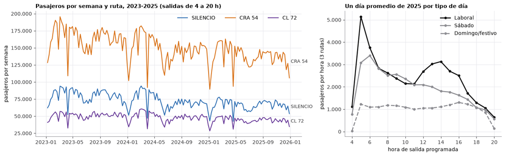

```python
# Figura 1: la demanda semana a semana y su forma dentro del día
COL_RUTA = {"SILENCIO": "#2f6fb3", "CRA 54": "#d9731a", "CL 72": "#6a3d9a"}     # colores de ruta de E11
dias_sem = TAB.groupby(pd.Grouper(key="dia", freq="W-SUN"))["dia"].nunique()
sem = TAB.groupby(["ruta", pd.Grouper(key="dia", freq="W-SUN")])["pasajeros_total"].sum().reset_index()
sem = sem[sem["dia"].isin(dias_sem[dias_sem == 7].index)]
t25 = TAB[TAB["dia"].dt.year == 2025]
PERFIL = (t25.groupby(["tipo_dia", "hora"])["pasajeros_total"].sum() / t25.groupby("tipo_dia")["dia"].nunique()).unstack(0)
PERFIL.columns = [ {0: "Laboral", 1: "Sábado", 2: "Domingo/festivo"}[c] for c in PERFIL.columns]

fig, (a1, a2) = plt.subplots(1, 2, figsize=(14, 4.4), gridspec_kw={"width_ratios": [1.7, 1]})
for r in ORDEN_RUTAS:
    x = sem[sem["ruta"] == r]
    a1.plot(x["dia"], x["pasajeros_total"], color=COL_RUTA[r], lw=1.6, label=r)
    a1.text(x["dia"].iloc[-1] + pd.Timedelta(days=6), x["pasajeros_total"].iloc[-8:].mean(), r, color=TINTA, va="center", fontsize=9)
a1.yaxis.set_major_formatter(FMT_MILES)
a1.set_ylabel("pasajeros por semana")
a1.set_title("Pasajeros por semana y ruta, 2023-2025 (salidas de 4 a 20 h)", loc="left")
a1.legend(loc="upper right", ncol=3)
for t, est in zip(TIPOS, [dict(color=REAL), dict(color=GRIS), dict(color=GRIS, ls="--")]):
    a2.plot(PERFIL.index, PERFIL[t], marker="o", ms=4, label=t, **est)
a2.yaxis.set_major_formatter(FMT_MILES)
a2.set_xticks(range(4, 21, 2))
a2.set_xlabel("hora de salida programada")
a2.set_ylabel("pasajeros por hora (3 rutas)")
a2.set_title("Un día promedio de 2025 por tipo de día", loc="left")
a2.legend()
fig.tight_layout()
plt.show()
```

```python
pa, pm = PERFIL.loc[4:10, "Laboral"].idxmax(), PERFIL.loc[11:20, "Laboral"].idxmax()
md(f"""**Lectura.** Hay {num(N_DIAS)} días ({TAB['dia'].min():%d-%m-%Y} a {TAB['dia'].max():%d-%m-%Y}) de {N_RUTAS} rutas, con
{num(KP['viajes_validos'])} viajes válidos de {num(KP['viajes_programados'])} programados y {num(KP['pasajeros_total'] / 1e6, 2)} millones
de pasajeros. La demanda **cae año a año**: de {num(POR_ANIO.loc[2023, 'pasajeros'] / 1e6, 2)} millones en 2023 a
{num(POR_ANIO.loc[2025, 'pasajeros'] / 1e6, 2)} millones en 2025 ({pct(POR_ANIO.loc[2024, 'variación anual (%)'], 1, True)} en 2024 y
{pct(POR_ANIO.loc[2025, 'variación anual (%)'], 1, True)} en 2025). CRA 54 lleva {pct(POR_RUTA_25.loc['CRA 54', 'pasajeros_total'] / POR_RUTA_25['pasajeros_total'].sum() * 100, 0)}
de los pasajeros de 2025. Dentro del día laboral hay dos picos (las {pa} h y las {pm} h) y un valle entre ellos, y los domingos y festivos
llevan menos de la mitad de pasajeros que un laboral en casi todas las horas: por eso la decisión se toma **por ruta, día y hora**, y por eso
un promedio de 8 semanas falla cuando cambia el calendario (festivos, vacaciones) o el nivel de la demanda.

La unidad de todo lo que sigue es la **franja ruta × día × hora de salida** de 4 a 20 h: {num(len(TAB))} franjas en los tres años.""")
mostrar_verif()
```

**Lectura.** Hay 1.096 días (01-01-2023 a 31-12-2025) de 3 rutas, con 520.639 viajes válidos de 564.837 programados y 42,17 millones de pasajeros. La demanda **cae año a año**: de 15,31 millones en 2023 a 12,87 millones en 2025 (−8,6 % en 2024 y −8,0 % en 2025). CRA 54 lleva 56 % de los pasajeros de 2025. Dentro del día laboral hay dos picos (las 5 h y las 14 h) y un valle entre ellos, y los domingos y festivos llevan menos de la mitad de pasajeros que un laboral en casi todas las horas: por eso la decisión se toma **por ruta, día y hora**, y por eso un promedio de 8 semanas falla cuando cambia el calendario (festivos, vacaciones) o el nivel de la demanda.

La unidad de todo lo que sigue es la **franja ruta × día × hora de salida** de 4 a 20 h: 55.896 franjas en los tres años.

**Contraste de las cifras de esta sección:** 11 de 11 coinciden con su referencia.

| cifra | qué es | calculado | referencia | fuente de la referencia | coincide |
| --- | --- | --- | --- | --- | --- |
| metodo_datos_crudos · viajes_validos | Datos de partida: viajes programados, válidos, pasajeros, vehículos, conductores, días, eventos… | 520.639 | 520.639 | app/DATOS.md | sí |
| metodo_datos_crudos · viajes_programados | Datos de partida: viajes programados, válidos, pasajeros, vehículos, conductores, días, eventos… | 564.837 | 564.837 | app/DATOS.md | sí |
| metodo_datos_crudos · pasajeros_total | Datos de partida: viajes programados, válidos, pasajeros, vehículos, conductores, días, eventos… | 42.166.279 | 42.166.279 | app/DATOS.md | sí |
| Pasajeros de la tabla de modelado = pasajeros del EDA |  | 42.166.279 | 42.166.279 | dashboard_datos.js · kpis.pasajeros_total | sí |
| inicio_demanda_por_anio · 2023 | Pasajeros por año en viajes válidos (de 15,31 a 12,87 millones: cae ~8 % al año) | 15.305.192 | 15.305.192 | app/DATOS.md | sí |
| inicio_demanda_por_anio · 2024 | Pasajeros por año en viajes válidos (de 15,31 a 12,87 millones: cae ~8 % al año) | 13.988.686 | 13.988.686 | app/DATOS.md | sí |
| inicio_demanda_por_anio · 2025 | Pasajeros por año en viajes válidos (de 15,31 a 12,87 millones: cae ~8 % al año) | 12.872.401 | 12.872.401 | app/DATOS.md | sí |
| inicio_caida_anual · 2024_original | Variación anual de la demanda, objetivo original frente al corregido (contando los viajes marca… | −8,6017 | −8,6017 | app/DATOS.md | sí |
| inicio_caida_anual · 2025_original | Variación anual de la demanda, objetivo original frente al corregido (contando los viajes marca… | −7,9799 | −7,9799 | app/DATOS.md | sí |
| modelo_final_pliegues · filas_panel | Validación: pliegues, franjas de prueba y panel | 55.896 | 55.896 | app/DATOS.md | sí |
| modelo_final_pliegues · dias | Validación: pliegues, franjas de prueba y panel | 1.096 | 1.096 | app/DATOS.md | sí |

## 2. La tabla de modelado y las variables

La Entrega 1 hizo el ETL, el análisis exploratorio y la ingeniería de variables, y dejó la **tabla de modelado** (`Entrega1/tablas/tabla_modelado.parquet`) con su **diccionario** (`diccionario_variables.csv`). Aquí se reutilizan tal cual; no se reconstruye nada. Cada fila es una franja ruta × día × hora de salida y trae:

- **Objetivo:** `pasajeros_total`, los pasajeros de los viajes válidos que salieron en esa franja.
- **Variables conocidas con antelación:** calendario (día de la semana, festivos, Carnaval, Semana Santa, vacaciones escolares y universitarias, quincena), climatología (lluvia típica del mes y la hora, no la observada) y **rezagos** de la propia serie (hace 7, 14, 21 y 28 días, la media de esas 4 semanas, la regla de 8 semanas, medias móviles). Con una semana de antelación, ningún rezago mira menos de 7 días atrás.
- **Calidad (solo como peso, nunca como variable):** días atípicos no predecibles (paro, aguaceros, fallas de datos) y franjas con muchos viajes sin registro (equipo a bordo caído). El modelo final aprende menos de ellas.

La tabla ya trae los rezagos corregidos por viajes sin registro que usa el modelo final (variante V4 de E11). El módulo `comun_e11.py` de E11 define qué variables entran, los pesos y el entrenamiento; se importa sin modificarlo.

```python
SECCION = "2 · Tabla de modelado"
sys.path.insert(0, str(E11))
import comun_e11 as C                               # módulo común de E11 (variables, pesos, entrenamiento)
warnings.filterwarnings("ignore")
CFG = C.VARIANTES["V4"]
VARS = C.variables_variante(CFG, 7)                 # variables del modelo final con una semana de antelación

FAM = (DIC.groupby("familia").agg(columnas=("variable", "size"), en_el_modelo=("en_modelo_h7", lambda s: int((s == "sí").sum())),
                                    ejemplos=("variable", lambda s: ", ".join(s.head(3))))
       .sort_values(["en_el_modelo", "columnas"], ascending=False))
tabla(FAM, enteros=("columnas", "en_el_modelo"))
EN_H7 = set(DIC.loc[DIC["en_modelo_h7"] == "sí", "variable"])
verificar_ref("Variables marcadas en el diccionario = variables de V4 en comun_e11", EN_H7 == set(VARS), True,
              "Entrega1/tablas/diccionario_variables.csv · en_modelo_h7")
verificar("modelo_final_variables", len(VARS), "E11_h7")
verificar("modelo_final_variables", RFE["variables"]["e1_h7"], "E1_h7")
```

| familia | columnas | en_el_modelo | ejemplos |
| --- | --- | --- | --- |
| rezagos de carga_max | 13 | 10 | carga_max_lag1, carga_max_lag2, carga_max_lag7 |
| rezagos de pasajeros_por_viaje | 13 | 10 | pasajeros_por_viaje_lag1, pasajeros_por_viaje_lag2, pasajeros_por_viaje_lag7 |
| rezagos de pasajeros_total | 13 | 10 | pasajeros_total_lag1, pasajeros_total_lag2, pasajeros_total_lag7 |
| rezagos de viajes_validos | 13 | 10 | viajes_validos_lag1, viajes_validos_lag2, viajes_validos_lag7 |
| calendario base | 10 | 10 | dia_semana, mes, dia_mes |
| calendario escolar y universitario | 6 | 6 | vac_escolar, vac_univ, dias_desde_pago |
| calendario especial | 6 | 6 | carnaval, carnaval_central, primero_enero |
| totales diarios rezagados | 8 | 5 | tot_pax_lag1, tot_viajes_lag1, tot_pax_lag7 |
| climatología | 4 | 4 | clim_p_mes_hora, clim_prob_mes_hora, clim_p_viaje4 |
| eventos | 4 | 4 | partido_dia, partido_franja, evento_otro_dia |
| identificación | 10 | 2 | idruta, dia, hora |
| objetivo corregido (E13) | 12 | 0 | y_corr, n_corrio, n_canc_corrio |
| nowcast (cota, no desplegable) | 5 | 0 | p_h, max_prev3, p_viaje4 |
| calidad (solo peso) | 4 | 0 | viajes_sin_registro, frac_sin_registro, atipico |
| objetivo | 4 | 0 | viajes_validos, pasajeros_total, pasajeros_por_viaje |
| agregado contemporáneo | 3 | 0 | viajes_pax_ok, viajes_limpios, viajes_carga |
| referencia (línea base) | 1 | 0 | b1_manual |

```python
# Pesos de entrenamiento: la columna 'peso' de la tabla frente a la regla de comun_e11 (0,25 a días atípicos, 0,1 a franjas con fallas)
ATIP = TAB["atipico"] == 1
FALLA = TAB["frac_sin_registro"] >= C.UMBRAL_FALLA_FRANJA
W_REGLA = C.pesos(TAB, CFG, pd.Timestamp("2026-01-01"))
PESOS = pd.DataFrame({"filas": TAB["peso"].value_counts().sort_index(ascending=False)})
PESOS.index = [num(v, 2) for v in PESOS.index]
PESOS.index.name = "peso en el entrenamiento"
tabla(PESOS, enteros=("filas",))
verificar_ref("Columna peso = regla de pesos de comun_e11 (55.896 filas)", float(np.abs(W_REGLA - TAB["peso"].values).max()), 0,
              "experimentos/E11_modelo_mejorado/comun_e11.py · pesos()")
verificar("modelo_final_pesos", TAB.loc[ATIP, "dia"].nunique(), "dias_atipicos_no_predecibles")
verificar("modelo_final_pesos", ATIP.sum(), "filas_peso_0_25")
verificar("modelo_final_pesos", FALLA.sum(), "franjas_con_fallas_peso_0_1")
verificar("modelo_final_pesos", FALLA.mean() * 100, "pct_franjas_con_fallas")
verificar("metodo_pesos_entrenamiento", (TAB["peso"] == C.PESO_ATIPICO).sum(), "filas_0_25")
verificar("metodo_pesos_entrenamiento", (TAB["peso"] == C.PESO_FALLA).sum(), "filas_0_1")
verificar("metodo_pesos_entrenamiento", (ATIP & FALLA).sum(), "filas_ambas_reglas")
verificar("metodo_pesos_entrenamiento", (TAB["peso"] == 1).sum(), "filas_peso_1")

# Una fila de ejemplo, leída con el diccionario: CRA 54, martes 3 de junio de 2025, salida de las 8 h
EJ = TAB[(TAB["ruta"] == "CRA 54") & (TAB["dia"] == pd.Timestamp("2025-06-03")) & (TAB["hora"] == 8)].iloc[0]
COLS_EJ = ["pasajeros_total", "pasajeros_total_b1", "pasajeros_total_m4sem", "pasajeros_total_lag7", "pasajeros_total_roll7_h7",
           "viajes_validos_m4sem", "tipo_dia", "festivo", "vac_escolar", "frac_vac_escolar_ventana", "dias_desde_pago",
           "clim_p_mes_hora", "frac_sin_registro", "peso"]
EJDF = DIC.set_index("variable").loc[COLS_EJ, ["familia", "en_modelo_h7", "definicion"]]
EJDF.insert(0, "valor", [num(EJ[c], 2) for c in COLS_EJ])
display(EJDF)
```

| peso en el entrenamiento | filas |
| --- | --- |
| 1,00 | 53.148 |
| 0,25 | 1.336 |
| 0,10 | 1.412 |

| variable | valor | familia | en_modelo_h7 | definicion |
| --- | --- | --- | --- | --- |
| pasajeros_total | 1.798,00 | objetivo | no | Σ numeropasajeros de los viajes válidos con dato y ≤ 300, ceros incluidos (R4) |
| pasajeros_total_b1 | 1.548,75 | rezagos de pasajeros_total | sí | pasajeros_total: media de las 8 semanas anteriores de la misma ruta, hora y día de la semana (mínimo 4): regla manual de Sobusa |
| pasajeros_total_m4sem | 1.600,25 | rezagos de pasajeros_total | sí | pasajeros_total: media de lag7, lag14, lag21 y lag28 ignorando vacíos (4 mismas semanas) |
| pasajeros_total_lag7 | 1.572,00 | rezagos de pasajeros_total | sí | pasajeros_total: valor de hace 7 días (mismo día de la semana) |
| pasajeros_total_roll7_h7 | 1.416,21 | rezagos de pasajeros_total | sí | pasajeros_total: media de los días 7 a 13 atrás (mínimo 3 valores) |
| viajes_validos_m4sem | 15,25 | rezagos de viajes_validos | sí | viajes_validos: media de lag7, lag14, lag21 y lag28 ignorando vacíos (4 mismas semanas) |
| tipo_dia | 0,00 | calendario base | sí | 2 domingo o festivo; 1 sábado; 0 laboral |
| festivo | 0,00 | calendario base | sí | Festivo nacional de Colombia (incluye los trasladados a lunes por la Ley Emiliani) |
| vac_escolar | 0,00 | calendario escolar y universitario | sí | Receso de los colegios oficiales de Barranquilla (inicio de año, Semana Santa, mitad de año, octubre, fin de año) |
| frac_vac_escolar_ventana | 0,00 | calendario escolar y universitario | sí | Fracción de los 4 días de referencia (d−7, d−14, d−21, d−28) en receso escolar |
| dias_desde_pago | 3,00 | calendario escolar y universitario | sí | Días desde el último día 15 o último día del mes (0 el día de pago) |
| clim_p_mes_hora | 0,12 | climatología | sí | Lluvia media (mm/h) por mes × hora en 2013-2022 |
| frac_sin_registro | 0,05 | calidad (solo peso) | no | viajes_sin_registro / viajes_validos (0 si no hay viajes) |
| peso | 1,00 | calidad (solo peso) | no | Peso de entrenamiento: 1; 0,25 si atipico; 0,1 si frac_sin_registro ≥ 0,25 |

```python
pf = RFE["prueba_fugas"]
md(f"""**Lectura.** La tabla tiene {num(len(TAB))} filas ({N_RUTAS} rutas × {num(N_DIAS)} días × {N_HORAS} horas) y {TAB.shape[1]} columnas
en {len(FAM)} familias; el modelo final usa {len(VARS)} de ellas (E1 usaba {RFE['variables']['e1_h7']}): las {int(FAM.loc[FAM.index.str.startswith('rezagos'), 'en_el_modelo'].sum())}
de rezagos de los cuatro objetivos, el calendario, la climatología y los totales diarios rezagados. El diccionario y el código de E11 dicen
lo mismo ({'coinciden' if EN_H7 == set(VARS) else 'NO coinciden'}). La fila de ejemplo lo muestra: a las 8 h del 3 de junio subieron
{num(EJ['pasajeros_total'])} pasajeros en CRA 54; la regla de 8 semanas decía {num(EJ['pasajeros_total_b1'])} y la media de las 4 mismas
semanas {num(EJ['pasajeros_total_m4sem'])}.

Los pesos bajan la influencia de lo que es error de datos, no demanda: {num(TAB.loc[ATIP, 'dia'].nunique())} días atípicos no predecibles
({num(ATIP.sum())} filas) pesan {num(C.PESO_ATIPICO, 2)} y las {num(FALLA.sum())} franjas con al menos {pct(C.UMBRAL_FALLA_FRANJA * 100, 0)} de viajes
sin registro ({pct(FALLA.mean() * 100, 1)} del total) pesan {num(C.PESO_FALLA, 1)}. La prueba de fugas de la Entrega 1 (corte {pf['T']}:
cambiar todo lo posterior al corte no mueve ninguna variable de antes) {'pasó' if pf['h7_ok'] and pf['controles_ok'] else 'NO pasó'}.""")
mostrar_verif()
```

**Lectura.** La tabla tiene 55.896 filas (3 rutas × 1.096 días × 17 horas) y 129 columnas en 17 familias; el modelo final usa 77 de ellas (E1 usaba 67): las 40 de rezagos de los cuatro objetivos, el calendario, la climatología y los totales diarios rezagados. El diccionario y el código de E11 dicen lo mismo (coinciden). La fila de ejemplo lo muestra: a las 8 h del 3 de junio subieron 1.798 pasajeros en CRA 54; la regla de 8 semanas decía 1.549 y la media de las 4 mismas semanas 1.600.

Los pesos bajan la influencia de lo que es error de datos, no demanda: 31 días atípicos no predecibles (1.547 filas) pesan 0,25 y las 1.412 franjas con al menos 25 % de viajes sin registro (2,5 % del total) pesan 0,1. La prueba de fugas de la Entrega 1 (corte 2025-03-10: cambiar todo lo posterior al corte no mueve ninguna variable de antes) pasó.

**Contraste de las cifras de esta sección:** 12 de 12 coinciden con su referencia.

| cifra | qué es | calculado | referencia | fuente de la referencia | coincide |
| --- | --- | --- | --- | --- | --- |
| Variables marcadas en el diccionario = variables de V4 en comun_e11 |  | sí | sí | Entrega1/tablas/diccionario_variables.csv · en_modelo_h7 | sí |
| modelo_final_variables · E11_h7 | Número de variables del modelo final (y de E1) | 77 | 77 | app/DATOS.md | sí |
| modelo_final_variables · E1_h7 | Número de variables del modelo final (y de E1) | 67 | 67 | app/DATOS.md | sí |
| Columna peso = regla de pesos de comun_e11 (55.896 filas) |  | 0,0000 | 0,0000 | experimentos/E11_modelo_mejorado/comun_e11.py · pesos() | sí |
| modelo_final_pesos · dias_atipicos_no_predecibles | Filas con peso bajo en el entrenamiento | 31 | 31 | app/DATOS.md | sí |
| modelo_final_pesos · filas_peso_0_25 | Filas con peso bajo en el entrenamiento | 1.547 | 1.547 | app/DATOS.md | sí |
| modelo_final_pesos · franjas_con_fallas_peso_0_1 | Filas con peso bajo en el entrenamiento | 1.412 | 1.412 | app/DATOS.md | sí |
| modelo_final_pesos · pct_franjas_con_fallas | Filas con peso bajo en el entrenamiento | 2,5261 | 2,5261 | app/DATOS.md | sí |
| metodo_pesos_entrenamiento · filas_0_25 | Filas con peso bajo en el panel | 1.336 | 1.336 | app/DATOS.md | sí |
| metodo_pesos_entrenamiento · filas_0_1 | Filas con peso bajo en el panel | 1.412 | 1.412 | app/DATOS.md | sí |
| metodo_pesos_entrenamiento · filas_ambas_reglas | Filas con peso bajo en el panel | 211 | 211 | app/DATOS.md | sí |
| metodo_pesos_entrenamiento · filas_peso_1 | Filas con peso bajo en el panel | 53.148 | 53.148 | app/DATOS.md | sí |

## 3. El modelo en vivo: un pliegue del protocolo

**El modelo final** es un *gradient boosting* de árboles (LightGBM) con pérdida de **Poisson**, adecuada para conteos de pasajeros que no pueden ser negativos y cuya varianza crece con la media. Es la variante **V4** de E11: las variables de E1 más calendarios escolar y universitario y climatología, con los pesos de calidad de la sección anterior y los rezagos corregidos por viajes sin registro. Los hiperparámetros son los de E1 (el ajuste anidado de E11 los empeoraba) y se leen de `experimentos/E11_modelo_mejorado/seleccion.json`.

**El protocolo** de todos los experimentos: cada mes de 2025 se pronostica con un modelo entrenado solo con lo anterior a ese mes (12 pliegues), con una semana de antelación, y se compara con la regla manual. Aquí se entrena **un pliegue en vivo**, junio de 2025 (el mes del día de ejemplo del optimizador), con todo lo anterior al 1 de junio, y se comprueba que sus predicciones coinciden con las guardadas por E11. Se conserva `n_jobs = 2` de E11: el entrenamiento tarda segundos, y cambiar el número de hilos puede mover los últimos decimales.

```python
SECCION = "3 · Modelo en vivo"
SEL = leer_json(E11 / "seleccion.json")
PARAMS = dict(SEL["params"])
assert SEL["variante"] == "V4" and PARAMS == C.PARAMS_BASE
MES = 6
INI = pd.Timestamp(2025, MES, 1)
FIN = INI + pd.offsets.MonthBegin(1)
TR = TAB[TAB["dia"] < INI]
TE = TAB[(TAB["dia"] >= INI) & (TAB["dia"] < FIN)].copy()
USADAS = TR["pasajeros_total"].notna() & (TR["excluido"] == 0) & TR["pasajeros_total_m4sem"].notna()   # las que usa C.entrenar

t = time.time()
MODELO = C.entrenar(TR, VARS, CFG, INI, PARAMS)
T_ENTRENAR = time.time() - t
TE["pred_vivo"] = np.clip(MODELO.predict(TE[VARS]), 0, None)

P11 = pd.read_parquet(E11 / "predicciones_2025.parquet")
GUARD = P11[(P11["horizonte"] == 7) & (P11["dia"] >= INI) & (P11["dia"] < FIN)]
CMP = TE[["idruta", "dia", "hora", "pasajeros_total", "pred_vivo"]].merge(
    GUARD[["idruta", "dia", "hora", "real", "prediccion", "variante"]], on=["idruta", "dia", "hora"], how="inner", validate="one_to_one")
assert len(CMP) == len(TE) == len(GUARD) and (CMP["variante"] == "V4").all()
DIF_MAX = float(np.abs(CMP["pred_vivo"] - CMP["prediccion"]).max())
DIF_REAL = float(np.abs(CMP["pasajeros_total"] - CMP["real"]).max())
assert DIF_MAX < 1e-6, "el modelo en vivo no reproduce las predicciones guardadas"
R11 = leer_json(E11 / "resultados.json")
VAR11 = {v["clave"]: v for v in R11["variantes"]}
W_VIVO = wape(CMP["pasajeros_total"], CMP["pred_vivo"])
W_JSON = VAR11["V4_h7"]["metricas_por_mes"][str(MES)]["WAPE"]

HECHOS = pd.DataFrame([
    ("Variante e hiperparámetros", f"{SEL['variante']} · {SEL['hiperparametros']} · objetivo Poisson"),
    ("Árboles / tasa de aprendizaje / hojas / mín. por hoja",
     f"{PARAMS['n_estimators']} / {num(PARAMS['learning_rate'], 2)} / {PARAMS['num_leaves']} / {PARAMS['min_child_samples']}"),
    ("Semilla / hilos", f"{PARAMS['random_state']} / {PARAMS['n_jobs']}"),
    ("Entrenamiento", f"{TR['dia'].min():%d-%m-%Y} a {TR['dia'].max():%d-%m-%Y}: {num(USADAS.sum())} filas usadas de {num(len(TR))}"),
    ("Prueba", f"{MESES[MES - 1]} de 2025: {num(len(TE))} franjas"),
    ("Tiempo de entrenamiento", f"{num(T_ENTRENAR, 1)} s"),
    ("Diferencia máxima con la predicción guardada", ("0" if DIF_MAX == 0 else f"{DIF_MAX:.1e}") + " pasajeros"),
    ("WAPE del mes: en vivo / guardado en resultados.json", f"{pct(W_VIVO, 3)} / {pct(W_JSON, 3)}"),
], columns=["Pliegue en vivo", "Valor"]).set_index("Pliegue en vivo")
display(HECHOS)
verificar_ref("Predicción en vivo frente a predicciones_2025.parquet (dif. máx.)", DIF_MAX, 0, "E11 · predicciones_2025.parquet", tol=1e-6, dec=6)
verificar_ref("Objetivo de la tabla = 'real' guardado (dif. máx.)", DIF_REAL, 0, "E11 · predicciones_2025.parquet")
verificar_ref(f"WAPE de {MESES[MES - 1]} 2025 en vivo", W_VIVO, W_JSON, "E11 · resultados.json · variantes[V4_h7].metricas_por_mes")
for k in ("n_estimators", "learning_rate", "num_leaves", "min_child_samples"):
    verificar("modelo_final_hiperparametros", PARAMS[k], k)
```

| Pliegue en vivo | Valor |
| --- | --- |
| Variante e hiperparámetros | V4 · C0 base E1 · objetivo Poisson |
| Árboles / tasa de aprendizaje / hojas / mín. por hoja | 600 / 0,03 / 31 / 40 |
| Semilla / hilos | 42 / 2 |
| Entrenamiento | 01-01-2023 a 31-05-2025: 44.522 filas usadas de 44.982 |
| Prueba | junio de 2025: 1.530 franjas |
| Tiempo de entrenamiento | 7,0 s |
| Diferencia máxima con la predicción guardada | 0 pasajeros |
| WAPE del mes: en vivo / guardado en resultados.json | 15,974 % / 15,974 % |

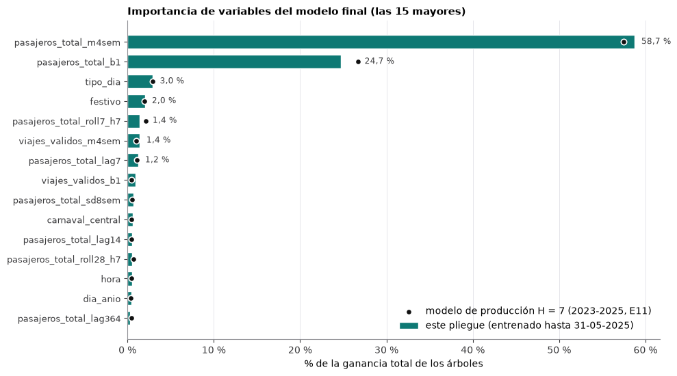

|  | % ganancia (pliegue) | % ganancia (producción) | familia | definicion |
| --- | --- | --- | --- | --- |
| pasajeros_total_m4sem | 58,72 | 57,46 | rezagos de pasajeros_total | pasajeros_total: media de lag7, lag14, lag21 y lag28 ignorando vacíos (4 mismas semanas) |
| pasajeros_total_b1 | 24,68 | 26,67 | rezagos de pasajeros_total | pasajeros_total: media de las 8 semanas anteriores de la misma ruta, hora y día de la semana (mínimo 4): regla manual de Sobusa |
| tipo_dia | 2,96 | 2,92 | calendario base | 2 domingo o festivo; 1 sábado; 0 laboral |
| festivo | 2,04 | 1,95 | calendario base | Festivo nacional de Colombia (incluye los trasladados a lunes por la Ley Emiliani) |
| pasajeros_total_roll7_h7 | 1,43 | 2,12 | rezagos de pasajeros_total | pasajeros_total: media de los días 7 a 13 atrás (mínimo 3 valores) |
| viajes_validos_m4sem | 1,41 | 1,05 | rezagos de viajes_validos | viajes_validos: media de lag7, lag14, lag21 y lag28 ignorando vacíos (4 mismas semanas) |
| pasajeros_total_lag7 | 1,25 | 1,09 | rezagos de pasajeros_total | pasajeros_total: valor de hace 7 días (mismo día de la semana) |
| viajes_validos_b1 | 0,95 | 0,48 | rezagos de viajes_validos | viajes_validos: media de las 8 semanas anteriores de la misma ruta, hora y día de la semana (mínimo 4): regla manual de Sobusa |

```python
# Importancia de variables (ganancia de los árboles, %): este pliegue frente al modelo de producción H = 7 (entrenado con 2023-2025)
IMP = pd.Series(MODELO.booster_.feature_importance("gain"), index=VARS)
IMP = (IMP / IMP.sum() * 100).sort_values(ascending=False)
META = leer_json(E11 / "modelos" / "metadatos.json")
IMP_PROD = pd.Series(META["modelos"]["H7"]["importancia_top20"])
NUEVAS = C.CAL_NUEVO + C.CLIM
TOP = IMP.head(15)[::-1]

fig, ax = plt.subplots(figsize=(10, 5.6))
y = np.arange(len(TOP))
ax.barh(y, TOP.values, color=TURQ, height=0.7, edgecolor="white", linewidth=1, label=f"este pliegue (entrenado hasta {INI - pd.Timedelta(days=1):%d-%m-%Y})")
ax.scatter(IMP_PROD.reindex(TOP.index).values, y, color=REAL, s=36, zorder=3, edgecolor="white", linewidth=1.2,
           label="modelo de producción H = 7 (2023-2025, E11)")
for yi, v, vp in zip(y, TOP.values, IMP_PROD.reindex(TOP.index).fillna(0).values):
    if v >= 1:
        ax.text(max(v, vp) + 0.8, yi, pct(v, 1), va="center", fontsize=8.5, color=TINTA)
ax.set_yticks(y)
ax.set_yticklabels([v + ("  (nueva en E11)" if v in NUEVAS else "") for v in TOP.index], fontsize=9)
ax.xaxis.set_major_formatter(FMT_PCT)
ax.set_xlabel("% de la ganancia total de los árboles")
ax.set_title("Importancia de variables del modelo final (las 15 mayores)", loc="left")
ax.grid(axis="y", visible=False)
ax.legend(loc="lower right")
fig.tight_layout()
plt.show()

DEF = DIC.set_index("variable").loc[IMP.head(8).index, ["familia", "definicion"]]
DEF.insert(0, "% ganancia (pliegue)", [num(v, 2) for v in IMP.head(8)])
DEF.insert(1, "% ganancia (producción)", [num(IMP_PROD.get(v, np.nan), 2) for v in IMP.head(8).index])
display(DEF)
for v in ("pasajeros_total_m4sem", "pasajeros_total_b1", "tipo_dia", "pasajeros_total_roll7_h7"):
    verificar("modelo_final_importancia", IMP_PROD[v], v)
```

```python
md(f"""**Lectura.** El pliegue de {MESES[MES - 1]} se entrenó en {num(T_ENTRENAR, 1)} s con {num(USADAS.sum())} filas y sus
{num(len(TE))} predicciones son **las mismas** que guardó E11 (diferencia máxima {'0' if DIF_MAX == 0 else f'{DIF_MAX:.1e}'} pasajeros), con un WAPE del mes de
{pct(W_VIVO, 2)}. No hizo falta cambiar `n_jobs`: con los {PARAMS['n_jobs']} hilos de E11 tarda segundos.

Qué aprende el modelo: la media de las 4 mismas semanas (`{IMP.index[0]}`, {pct(IMP.iloc[0], 1)} de la ganancia) y la regla de 8 semanas
(`{IMP.index[1]}`, {pct(IMP.iloc[1], 1)}) se llevan juntas {pct(IMP.iloc[:2].sum(), 0)}; después vienen el tipo de día, los festivos y las medias
recientes. Es decir, **el modelo es la demanda reciente de esa misma franja corregida por el calendario**, aprendida sin dejarse arrastrar por
los días con datos rotos. Las {len(NUEVAS)} variables nuevas de calendario escolar y universitario y de climatología suman apenas
{pct(IMP[NUEVAS].sum(), 2)}: casi todo lo que saben ya estaba en los rezagos. El modelo de producción (entrenado con 2023-2025) reparte la
importancia casi igual ({pct(IMP_PROD.iloc[0], 1)} y {pct(IMP_PROD.iloc[1], 1)} para las dos primeras).""")
mostrar_verif()
```

**Lectura.** El pliegue de junio se entrenó en 7,0 s con 44.522 filas y sus 1.530 predicciones son **las mismas** que guardó E11 (diferencia máxima 0 pasajeros), con un WAPE del mes de 15,97 %. No hizo falta cambiar `n_jobs`: con los 2 hilos de E11 tarda segundos.

Qué aprende el modelo: la media de las 4 mismas semanas (`pasajeros_total_m4sem`, 58,7 % de la ganancia) y la regla de 8 semanas (`pasajeros_total_b1`, 24,7 %) se llevan juntas 83 %; después vienen el tipo de día, los festivos y las medias recientes. Es decir, **el modelo es la demanda reciente de esa misma franja corregida por el calendario**, aprendida sin dejarse arrastrar por los días con datos rotos. Las 10 variables nuevas de calendario escolar y universitario y de climatología suman apenas 0,66 %: casi todo lo que saben ya estaba en los rezagos. El modelo de producción (entrenado con 2023-2025) reparte la importancia casi igual (57,5 % y 26,7 % para las dos primeras).

**Contraste de las cifras de esta sección:** 11 de 11 coinciden con su referencia.

| cifra | qué es | calculado | referencia | fuente de la referencia | coincide |
| --- | --- | --- | --- | --- | --- |
| Predicción en vivo frente a predicciones_2025.parquet (dif. máx.) |  | 0,000000 | 0,000000 | E11 · predicciones_2025.parquet | sí |
| Objetivo de la tabla = 'real' guardado (dif. máx.) |  | 0,0000 | 0,0000 | E11 · predicciones_2025.parquet | sí |
| WAPE de junio 2025 en vivo |  | 15,9741 | 15,9741 | E11 · resultados.json · variantes[V4_h7].metricas_por_mes | sí |
| modelo_final_hiperparametros · n_estimators | Hiperparámetros (los de E1; el ajuste anidado empeoraba) | 600 | 600 | app/DATOS.md | sí |
| modelo_final_hiperparametros · learning_rate | Hiperparámetros (los de E1; el ajuste anidado empeoraba) | 0,03 | 0,03 | app/DATOS.md | sí |
| modelo_final_hiperparametros · num_leaves | Hiperparámetros (los de E1; el ajuste anidado empeoraba) | 31 | 31 | app/DATOS.md | sí |
| modelo_final_hiperparametros · min_child_samples | Hiperparámetros (los de E1; el ajuste anidado empeoraba) | 40 | 40 | app/DATOS.md | sí |
| modelo_final_importancia · pasajeros_total_m4sem | Qué variables pesan más (modelo H7, % de la ganancia) | 57,46 | 57,46 | app/DATOS.md | sí |
| modelo_final_importancia · pasajeros_total_b1 | Qué variables pesan más (modelo H7, % de la ganancia) | 26,67 | 26,67 | app/DATOS.md | sí |
| modelo_final_importancia · tipo_dia | Qué variables pesan más (modelo H7, % de la ganancia) | 2,92 | 2,92 | app/DATOS.md | sí |
| modelo_final_importancia · pasajeros_total_roll7_h7 | Qué variables pesan más (modelo H7, % de la ganancia) | 2,12 | 2,12 | app/DATOS.md | sí |

## 4. La evaluación completa

Se usan las predicciones guardadas de los **12 pliegues de 2025** con una semana de antelación (h = 7):

- **Regla manual (B1):** el promedio de las 8 semanas anteriores, misma ruta, hora y día de la semana (lo que hace Sobusa).
- **E1:** el primer LightGBM con calendario y demanda reciente (variante V0 de E11, que lo reproduce exactamente).
- **Modelo final:** V4 de E11, el de la sección anterior.
- **Híbrido:** el modelo final con 4 columnas más, el pronóstico de Chronos-2 (un modelo fundacional de series de tiempo de Amazon, usado sin reentrenar) con calendario (E12). Chronos-2 no está instalado en este entorno, así que el híbrido se evalúa con sus predicciones guardadas (`experimentos/E12_comparacion_modelos/predicciones/hibrido_V4_chronos2cov.parquet`, el archivo del que la app lee sus cifras y su serie diaria).

**Métrica:** WAPE = suma de los errores absolutos ÷ suma de los pasajeros reales. Se lee como «pasajeros mal estimados de cada 100».

### 4.1 Error global

```python
SECCION = "4 · Evaluación"
P7 = P11[P11["horizonte"] == 7].copy()
HIB = pd.read_parquet(E12 / "predicciones" / "hibrido_V4_chronos2cov.parquet")
HIB["dia"] = HIB["dia"].astype(P7["dia"].dtype)
EV = P7.merge(HIB[["idruta", "dia", "hora", "real", "prediccion"]].rename(columns={"real": "real_hib", "prediccion": "pred_hibrido"}),
              on=["idruta", "dia", "hora"], how="left", validate="one_to_one")
assert len(HIB) == len(P7) and EV["pred_hibrido"].notna().all()
assert float(np.abs(EV["real"] - EV["real_hib"]).max()) == 0          # mismo objetivo en E11 y E12
EV["mes"] = EV["dia"].dt.month
MOD = {"Regla manual (B1)": "pred_B1_manual", "E1 (primer LightGBM)": "pred_V0_E1",
       "Modelo final (E11, V4)": "prediccion", "Híbrido (E12)": "pred_hibrido"}
COL_MOD = dict(zip(MOD, [GRIS, AMBAR, TURQ, INDIGO]))
B1, E1M, V4, HB = list(MOD)


def metricas(df, col):
    y, p = df["real"], df[col]
    dia = df.groupby(["ruta", "dia"])[["real", col]].sum()
    return {"WAPE (%)": wape(y, p), "MAE (pasajeros por franja)": float((y - p).abs().mean()),
            "sesgo (pasajeros por franja)": float((p - y).mean()), "sesgo (% del total)": float((p.sum() / y.sum() - 1) * 100),
            "WAPE del total diario por ruta (%)": wape(dia["real"], dia[col])}


R12 = leer_json(E12 / "resultados.json")
H12 = leer_json(E12 / "resultados" / "hibrido_V4_chronos2cov.json")
GLOB = pd.DataFrame({m: metricas(EV, c) for m, c in MOD.items()}).T
GLOB["WAPE guardado (%)"] = [R11["horizontes"]["B1_H7"]["global_"]["WAPE"], R11["horizontes"]["V0_H7"]["global_"]["WAPE"],
                             R11["horizontes"]["SEL_H7"]["global_"]["WAPE"], R12["produccion"]["costos"]["hibrido_V4_chronos2cov"]["WAPE_2025"]]
GLOB.index.name = f"2025, h = 7, {num(len(EV))} franjas, {EV['dia'].nunique()} días"
tabla(GLOB, dec=2)

P1 = P11[P11["horizonte"] == 1]
W_H1 = {"B1": wape(P1["real"], P1["pred_B1_manual"]), "E1_V0": wape(P1["real"], P1["pred_V0_E1"]), "E11_V4": wape(P1["real"], P1["prediccion"])}

verificar("inicio_error_regla_manual", GLOB.loc[B1, "WAPE (%)"])
verificar("inicio_error_e1", GLOB.loc[E1M, "WAPE (%)"])
verificar("inicio_error_modelo_final", GLOB.loc[V4, "WAPE (%)"])
verificar("inicio_error_hibrido", GLOB.loc[HB, "WAPE (%)"])
for k, m in zip(["B1", "E1_V0", "E11_V4", "hibrido"], MOD):
    verificar("demanda_wape_total_diario", GLOB.loc[m, "WAPE del total diario por ruta (%)"], k)
verificar("demanda_sesgo", GLOB.loc[V4, "sesgo (% del total)"], "E11_V4_pct")
verificar("demanda_sesgo", GLOB.loc[V4, "sesgo (pasajeros por franja)"], "E11_V4_pax_franja")
verificar("demanda_sesgo", GLOB.loc[B1, "sesgo (% del total)"], "B1_pct")
verificar("modelo_hibrido_sesgo", GLOB.loc[HB, "sesgo (% del total)"], "2025_pct")
for k, v in W_H1.items():
    verificar("demanda_wape_h1", v, k)
verificar("demanda_protocolo", EV["mes"].nunique(), "pliegues")
verificar("demanda_protocolo", len(EV), "franjas_prueba")
verificar("modelo_final_seleccion", GLOB.loc[V4, "WAPE (%)"] - GLOB.loc[E1M, "WAPE (%)"])
```

| 2025, h = 7, 18.615 franjas, 365 días | WAPE (%) | MAE (pasajeros por franja) | sesgo (pasajeros por franja) | sesgo (% del total) | WAPE del total diario por ruta (%) | WAPE guardado (%) |
| --- | --- | --- | --- | --- | --- | --- |
| Regla manual (B1) | 20,04 | 138,61 | 6,77 | 0,98 | 12,75 | 20,04 |
| E1 (primer LightGBM) | 14,40 | 99,57 | −2,25 | −0,33 | 5,55 | 14,40 |
| Modelo final (E11, V4) | 13,94 | 96,39 | 9,82 | 1,42 | 4,86 | 13,94 |
| Híbrido (E12) | 13,62 | 94,17 | 10,01 | 1,45 | 4,92 | 13,62 |

```python
g = GLOB["WAPE (%)"]
md(f"""**Lectura.** A una semana de antelación, la regla manual se equivoca en **{num(g[B1], 1)} de cada 100 pasajeros** por hora de
salida ({pct(g[B1], 2)}); E1 en {num(g[E1M], 1)} ({pct(g[E1M], 2)}), el modelo final en **{num(g[V4], 1)}** ({pct(g[V4], 2)}) y el híbrido en
**{num(g[HB], 1)}** ({pct(g[HB], 2)}). El modelo final quita {pct((1 - g[V4] / g[B1]) * 100, 0)} del error de la regla manual. Sumando las 17 horas
del día, el error del total diario por ruta baja de {pct(GLOB.loc[B1, 'WAPE del total diario por ruta (%)'], 1)} con la regla a
{pct(GLOB.loc[V4, 'WAPE del total diario por ruta (%)'], 1)} con el modelo final. El costo del modelo final es un leve exceso de pronóstico
({pct(GLOB.loc[V4, 'sesgo (% del total)'], 1, True)} del total), que para despachar es preferible a quedarse corto.

Las cuatro cifras coinciden con las de `app/DATOS.md` porque se calculan sobre la misma base: **horizonte de 7 días**, las {num(len(EV))}
franjas de los {EV['mes'].nunique()} pliegues de 2025 (todos los días; los dos días excluidos del protocolo son de 2024) y la variante
{P7['variante'].iloc[0]}. Si se mezclaran las filas con h = 1 que trae el mismo archivo, las cifras cambiarían: con un día de antelación
son {pct(W_H1['B1'], 2)}, {pct(W_H1['E1_V0'], 2)} y {pct(W_H1['E11_V4'], 2)}.""")
```

**Lectura.** A una semana de antelación, la regla manual se equivoca en **20,0 de cada 100 pasajeros** por hora de salida (20,04 %); E1 en 14,4 (14,40 %), el modelo final en **13,9** (13,94 %) y el híbrido en **13,6** (13,62 %). El modelo final quita 30 % del error de la regla manual. Sumando las 17 horas del día, el error del total diario por ruta baja de 12,8 % con la regla a 4,9 % con el modelo final. El costo del modelo final es un leve exceso de pronóstico (+1,4 % del total), que para despachar es preferible a quedarse corto.

Las cuatro cifras coinciden con las de `app/DATOS.md` porque se calculan sobre la misma base: **horizonte de 7 días**, las 18.615 franjas de los 12 pliegues de 2025 (todos los días; los dos días excluidos del protocolo son de 2024) y la variante V4. Si se mezclaran las filas con h = 1 que trae el mismo archivo, las cifras cambiarían: con un día de antelación son 20,04 %, 14,10 % y 13,83 %.

### 4.2 Por ruta, tipo de día y mes

El mismo cálculo por grupos. Se contrasta con las tablas por ruta, tipo de día y mes que guardaron E11 (`resultados.json`) y E12 (`resultados/hibrido_V4_chronos2cov.json`), que son las que cita `app/DATOS.md`.

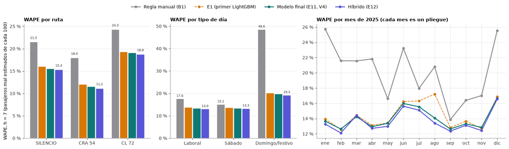

|  |  | Regla manual (B1) | E1 (primer LightGBM) | Modelo final (E11, V4) | Híbrido (E12) |
| --- | --- | --- | --- | --- | --- |
| ruta | SILENCIO | 21,51 | 16,04 | 15,52 | 15,32 |
|  | CRA 54 | 17,97 | 12,04 | 11,54 | 11,15 |
|  | CL 72 | 24,32 | 19,33 | 19,08 | 18,77 |
| tipo de día | Laboral | 17,62 | 13,87 | 13,36 | 13,03 |
|  | Sábado | 15,10 | 13,60 | 13,45 | 13,27 |
|  | Domingo/festivo | 48,58 | 20,20 | 19,74 | 19,27 |

```python
def wape_por(df, grupo):
    out = {}
    for m, c in MOD.items():
        out[m] = (df["real"] - df[c]).abs().groupby(df[grupo]).sum() / df.groupby(grupo)["real"].sum() * 100
    return pd.DataFrame(out)


POR_RUTA = wape_por(EV, "ruta").loc[ORDEN_RUTAS]
POR_TIPO = wape_por(EV, "tipo_dia").loc[TIPOS]
POR_MES = wape_por(EV, "mes")
CL11 = {B1: ("B1_H7", "B1_h7"), E1M: ("V0_H7", "V0_h7"), V4: ("SEL_H7", "V4_h7")}
REF_RUTA = pd.DataFrame({**{m: {r: R11["horizontes"][h]["por_ruta"][r]["WAPE"] for r in ORDEN_RUTAS} for m, (h, v) in CL11.items()},
                         HB: {r: H12["por_ruta"][r]["WAPE"] for r in ORDEN_RUTAS}})
REF_TIPO = pd.DataFrame({**{m: {t: VAR11[v]["metricas_por_tipo_dia"][t]["WAPE"] for t in TIPOS} for m, (h, v) in CL11.items()},
                         HB: {t: H12["por_tipo_dia"][t]["WAPE"] for t in TIPOS}})
REF_MES = pd.DataFrame({**{m: {k: VAR11[v]["metricas_por_mes"][str(k)]["WAPE"] for k in range(1, 13)} for m, (h, v) in CL11.items()},
                        HB: {k: H12["por_mes"][str(k)]["WAPE"] for k in range(1, 13)}})
for nombre, a, b in [("ruta", POR_RUTA, REF_RUTA), ("tipo de día", POR_TIPO, REF_TIPO), ("mes", POR_MES, REF_MES)]:
    verificar_ref(f"WAPE por {nombre} ({a.size} cifras): diferencia máxima", float((a - b.loc[a.index, a.columns]).abs().max().max()), 0,
                  "E11 resultados.json y E12 resultados/hibrido_V4_chronos2cov.json", tol=1e-9, dec=6)

fig, axes = plt.subplots(1, 3, figsize=(16, 4.6), gridspec_kw={"width_ratios": [1, 1, 1.5]})


def barras(ax, df, titulo):
    n, x = len(df.columns), np.arange(len(df))
    w = 0.82 / n
    for i, m in enumerate(df.columns):
        xs = x + (i - (n - 1) / 2) * w
        ax.bar(xs, df[m].values, width=w * 0.94, color=COL_MOD[m], label=m, edgecolor="white", linewidth=1)
        if m in (B1, HB):
            for xi, v in zip(xs, df[m].values):
                ax.text(xi, v + 0.5, num(v, 1), ha="center", va="bottom", fontsize=7.5, color=TINTA)
    ax.set_xticks(x)
    ax.set_xticklabels(df.index)
    ax.yaxis.set_major_formatter(FMT_PCT)
    ax.set_title(titulo, loc="left")
    ax.grid(axis="x", visible=False)


barras(axes[0], POR_RUTA, "WAPE por ruta")
barras(axes[1], POR_TIPO, "WAPE por tipo de día")
axes[0].set_ylabel("WAPE, h = 7 (pasajeros mal estimados de cada 100)")
for m, c in MOD.items():
    est = dict(ls="--", lw=1.4) if m == E1M else {}
    axes[2].plot(POR_MES.index, POR_MES[m], marker="o", ms=5, color=COL_MOD[m], label=m, **est)
axes[2].set_xticks(range(1, 13))
axes[2].set_xticklabels([x[:3] for x in MESES])
axes[2].yaxis.set_major_formatter(FMT_PCT)
axes[2].set_title("WAPE por mes de 2025 (cada mes es un pliegue)", loc="left")
manejadores, etiquetas = axes[2].get_legend_handles_labels()
fig.legend(manejadores, etiquetas, loc="upper center", ncol=4, bbox_to_anchor=(0.5, 1.02))
fig.tight_layout(rect=(0, 0, 1, 0.94))
plt.show()
TABLA_GRUPOS = pd.concat({"ruta": POR_RUTA, "tipo de día": POR_TIPO})
tabla(TABLA_GRUPOS, dec=2)
```

```python
mejor_mes = POR_MES[V4].idxmin()
peor_mes = POR_MES[V4].idxmax()
md(f"""**Lectura.** El orden de los cuatro métodos se mantiene en cada ruta, tipo de día y casi todos los meses. CRA 54, la ruta más
cargada, es la más fácil ({pct(POR_RUTA.loc['CRA 54', V4], 1)} con el modelo final) y CL 72 la más difícil ({pct(POR_RUTA.loc['CL 72', V4], 1)}).
Donde más falla la regla manual es en **domingos y festivos**: {pct(POR_TIPO.loc['Domingo/festivo', B1], 1)} frente a
{pct(POR_TIPO.loc['Domingo/festivo', V4], 1)} del modelo final, porque el promedio de 8 semanas mezcla domingos con festivos y no sabe
cuándo viene un puente. Por mes, el modelo final va de {pct(POR_MES.loc[mejor_mes, V4], 1)} ({MESES[mejor_mes - 1]}) a
{pct(POR_MES.loc[peor_mes, V4], 1)} ({MESES[peor_mes - 1]}), y la regla manual nunca baja de {pct(POR_MES[B1].min(), 1)}.""")
```

**Lectura.** El orden de los cuatro métodos se mantiene en cada ruta, tipo de día y casi todos los meses. CRA 54, la ruta más cargada, es la más fácil (11,5 % con el modelo final) y CL 72 la más difícil (19,1 %). Donde más falla la regla manual es en **domingos y festivos**: 48,6 % frente a 19,7 % del modelo final, porque el promedio de 8 semanas mezcla domingos con festivos y no sabe cuándo viene un puente. Por mes, el modelo final va de 12,6 % (febrero) a 16,7 % (diciembre), y la regla manual nunca baja de 13,9 %.

### 4.3 Un mes, día a día

Junio de 2025, el mes del pliegue en vivo: pasajeros por día (suma de las 17 horas de salida) de cada ruta, reales y pronosticados una semana antes.

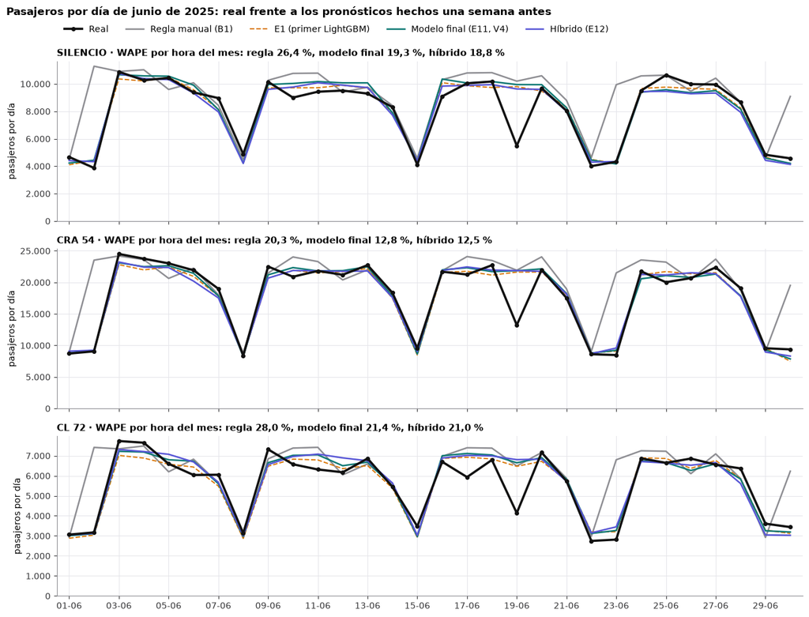

**Lectura.** Los tres modelos siguen la forma semanal (laborales altos, sábados medios, domingos bajos); la regla manual se separa en los domingos y festivos de junio (WAPE de esos días: regla 62,8 %, modelo final 20,3 %, híbrido 19,4 %). Entre el modelo final y el híbrido la diferencia día a día es pequeña: el híbrido corrige unos pocos pasajeros por franja, no la forma.

```python
DIA_MES = EV[EV["mes"] == MES].groupby(["ruta", "dia"])[["real"] + list(MOD.values())].sum().reset_index()
fig, axes = plt.subplots(3, 1, figsize=(13, 10), sharex=True)
for ax, r in zip(axes, ORDEN_RUTAS):
    x = DIA_MES[DIA_MES["ruta"] == r]
    ax.plot(x["dia"], x["real"], color=REAL, lw=2.6, marker="o", ms=4, label="Real", zorder=5)
    for m, c in MOD.items():
        est = dict(lw=1.4, ls="--") if m == E1M else dict(lw=1.8)
        ax.plot(x["dia"], x[c], color=COL_MOD[m], label=m, **est)
    sub = EV[(EV["mes"] == MES) & (EV["ruta"] == r)]
    ax.set_title(f"{r} · WAPE por hora del mes: regla {pct(wape(sub['real'], sub['pred_B1_manual']), 1)}, "
                 f"modelo final {pct(wape(sub['real'], sub['prediccion']), 1)}, híbrido {pct(wape(sub['real'], sub['pred_hibrido']), 1)}", loc="left")
    ax.yaxis.set_major_formatter(FMT_MILES)
    ax.set_ylabel("pasajeros por día")
    ax.set_ylim(0, None)
axes[0].legend(ncol=5, loc="lower left", bbox_to_anchor=(0, 1.12))
axes[-1].set_xlim(INI - pd.Timedelta(hours=12), FIN - pd.Timedelta(hours=12))
axes[-1].xaxis.set_major_locator(mdates.DayLocator(interval=2))
axes[-1].xaxis.set_major_formatter(mdates.DateFormatter("%d-%m"))
fig.suptitle(f"Pasajeros por día de {MESES[MES - 1]} de 2025: real frente a los pronósticos hechos una semana antes", fontweight="bold", x=0.01, ha="left")
fig.tight_layout()
plt.show()

FEST = EV[(EV["mes"] == MES) & (EV["tipo_dia"] == "Domingo/festivo")]
md(f"""**Lectura.** Los tres modelos siguen la forma semanal (laborales altos, sábados medios, domingos bajos); la regla manual se separa
en los domingos y festivos de {MESES[MES - 1]} (WAPE de esos días: regla {pct(wape(FEST['real'], FEST['pred_B1_manual']), 1)},
modelo final {pct(wape(FEST['real'], FEST['prediccion']), 1)}, híbrido {pct(wape(FEST['real'], FEST['pred_hibrido']), 1)}). Entre el modelo
final y el híbrido la diferencia día a día es pequeña: el híbrido corrige unos pocos pasajeros por franja, no la forma.""")
```

### 4.4 Híbrido frente al modelo final, y modelo final frente a E1

¿Las mejoras son reales o azar? Se repite la prueba de E11 y E12: diferencia de WAPE con un intervalo de confianza del 95 % por *bootstrap* pareado de días (se remuestrean los 365 días con reemplazo, 2.000 veces, semilla 42) y cuántos de los 12 meses mejoran.

```python
def bootstrap_dif(df, col_a, col_b, B=2000, semilla=SEMILLA):
    """Diferencia de WAPE (b - a, puntos) con IC 95 % por bootstrap pareado de días."""
    a = df.assign(ea=(df["real"] - df[col_a]).abs(), eb=(df["real"] - df[col_b]).abs()).groupby("dia")[["ea", "eb", "real"]].sum()
    est = (a["eb"].sum() - a["ea"].sum()) / a["real"].sum() * 100
    idx = np.random.default_rng(semilla).integers(0, len(a), size=(B, len(a)))
    bs = (a["eb"].values[idx].sum(1) - a["ea"].values[idx].sum(1)) / a["real"].values[idx].sum(1) * 100
    return est, float(np.percentile(bs, 2.5)), float(np.percentile(bs, 97.5))


D_H = bootstrap_dif(EV, "prediccion", "pred_hibrido")
D_V = bootstrap_dif(EV, "pred_V0_E1", "prediccion")
MM_H = int((POR_MES[HB] < POR_MES[V4]).sum())
MM_V = int((POR_MES[V4] < POR_MES[E1M]).sum())
G_H, G_V = H12["vs_V4"], R11["comparacion_vs_V0"]["V4_h7"]
PRUEBAS = pd.DataFrame([
    {"comparación": "Híbrido − modelo final", "diferencia (puntos)": D_H[0], "IC 95 % (este cuaderno)": ic(D_H[1], D_H[2]),
     "IC 95 % guardado": ic(G_H["ic_inf"], G_H["ic_sup"]), "meses mejor": f"{MM_H} de 12", "meses mejor guardado": f"{G_H['meses_mejor']} de 12"},
    {"comparación": "Modelo final − E1", "diferencia (puntos)": D_V[0], "IC 95 % (este cuaderno)": ic(D_V[1], D_V[2]),
     "IC 95 % guardado": ic(G_V["ic_inf"], G_V["ic_sup"]), "meses mejor": f"{MM_V} de 12", "meses mejor guardado": f"{G_V['meses_mejor']} de 12"},
]).set_index("comparación")
tabla(PRUEBAS, dec=3)
verificar("inicio_mejora_hibrido_2025", D_H[0])
verificar_ref("Híbrido − modelo final, diferencia", D_H[0], G_H["dif_pp"], "E12 · hibrido_V4_chronos2cov.json · vs_V4.dif_pp")
verificar_ref("Híbrido: meses mejor que el modelo final", MM_H, G_H["meses_mejor"], "E12 · vs_V4.meses_mejor", dec=0)
verificar_ref("Modelo final − E1, diferencia", D_V[0], G_V["dif_pp"], "E11 · resultados.json · comparacion_vs_V0.V4_h7.dif_pp")
verificar_ref("Modelo final: meses mejor que E1", MM_V, G_V["meses_mejor"], "E11 · comparacion_vs_V0.V4_h7.meses_mejor", dec=0)
md(f"""**Lectura.** Las dos mejoras son pequeñas pero no son azar: el intervalo queda entero por debajo de 0. El modelo final mejora a E1
en {num(D_V[0], 2, True)} puntos {ic(D_V[1], D_V[2])}, en {MM_V} de 12 meses (E11 advierte que buena parte viene de agosto, cuando E1 se quedaba
corto tras las fallas de datos de julio). El híbrido mejora al modelo final en {num(D_H[0], 2, True)} puntos {ic(D_H[1], D_H[2])}, en {MM_H} de 12
meses. Los intervalos de este cuaderno y los guardados difieren a lo sumo en el último decimal porque el sorteo de días no es idéntico;
las diferencias puntuales y los meses coinciden exactamente.""" + (f""" El informe cita para el modelo final frente a E1 el intervalo
{ic(D_V[1], D_V[2])} de la verificación independiente de E11, el mismo que sale aquí.""" if ic(D_V[1], D_V[2]) in INFORME else ""))
```

| comparación | diferencia (puntos) | IC 95 % (este cuaderno) | IC 95 % guardado | meses mejor | meses mejor guardado |
| --- | --- | --- | --- | --- | --- |
| Híbrido − modelo final | −0,320 | [−0,43; −0,22] | [−0,43; −0,22] | 11 de 12 | 11 de 12 |
| Modelo final − E1 | −0,460 | [−0,60; −0,33] | [−0,59; −0,33] | 10 de 12 | 10 de 12 |

**Lectura.** Las dos mejoras son pequeñas pero no son azar: el intervalo queda entero por debajo de 0. El modelo final mejora a E1 en −0,46 puntos [−0,60; −0,33], en 10 de 12 meses (E11 advierte que buena parte viene de agosto, cuando E1 se quedaba corto tras las fallas de datos de julio). El híbrido mejora al modelo final en −0,32 puntos [−0,43; −0,22], en 11 de 12 meses. Los intervalos de este cuaderno y los guardados difieren a lo sumo en el último decimal porque el sorteo de días no es idéntico; las diferencias puntuales y los meses coinciden exactamente. El informe cita para el modelo final frente a E1 el intervalo [−0,60; −0,33] de la verificación independiente de E11, el mismo que sale aquí.

### 4.5 La comparación de 51 modelos (E12) y por qué se recomienda el híbrido

E12 puso a competir decenas de candidatos con el mismo protocolo, la misma semana de antelación, las mismas franjas y los mismos pesos: otros árboles (XGBoost, CatBoost, Random Forest…), redes neuronales (TFT, N-HiTS, una CNN sobre la cuadrícula del año), modelos fundacionales sin reentrenar (Chronos de Amazon, TimesFM de Google), estadísticos clásicos (ETS, ARIMA, Prophet) y combinaciones. La regla de selección se fijó antes de ver resultados. Los finalistas se repitieron en 2024 como prueba fuera de la muestra de selección. Aquí se muestra el mejor de cada familia desde `ranking.csv` y `resultados.json` de E12.

| familia amplia | modelo | WAPE 2025 (%) | diferencia con el modelo final (puntos) | IC 95 % frente al modelo final | meses mejor | cumple la regla | modelos |
| --- | --- | --- | --- | --- | --- | --- | --- |
| Ensambles fijados de antemano | ens_conj_c_nnls_todos | 13,39 | −0,55 | [−0,69; −0,41] | 12 | sí | 5 |
| Ensambles hallados después de ver 2025 | ens_adhoc_V4_tft_nnls | 13,48 | −0,46 | [−0,59; −0,34] | 12 | sí | 3 |
| Híbrido LightGBM + fundacional | hibrido_V4_chronos2cov | 13,62 | −0,32 | [−0,43; −0,22] | 11 | sí | 1 |
| Ensambles de una sola familia | ens_arboles_media_gbm | 13,76 | −0,18 | [−0,23; −0,12] | 11 | sí | 4 |
| Otros árboles de decisión | lgbm_tweedie | 13,91 | −0,03 | [−0,08; +0,02] | 6 | no | 7 |
| Modelo final E11 (referencia) | V4_lightgbm | 13,94 | 0,00 | — | 0 | no | 1 |
| Redes neuronales | tft_global | 14,19 | 0,26 | [+0,01; +0,50] | 5 | no | 5 |
| Clásicos de E4 (referencia) | E4_E_GLM_SARIMA | 14,34 | 0,40 | [+0,17; +0,65] | 3 | no | 5 |
| E1 (referencia) | V0_E1 | 14,40 | 0,46 | [+0,33; +0,60] | 2 | no | 1 |
| Estadísticos clásicos | autoets_cal | 14,62 | 0,68 | [+0,38; +1,04] | 2 | no | 8 |
| Fundacionales sin reentrenar | chronos2_cov | 14,71 | 0,77 | [+0,47; +1,14] | 2 | no | 18 |
| Líneas base (regla manual) | B1_manual | 20,04 | 6,11 | [+4,77; +7,65] | 0 | no | 2 |

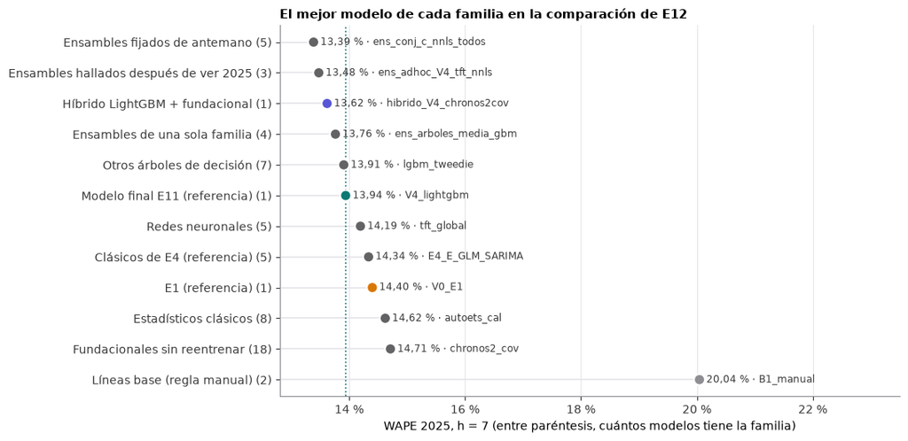

```python
RK = pd.read_csv(E12 / "ranking.csv")


def familia_amplia(f):
    reglas = [("ensamble conjunto", "Ensambles fijados de antemano"), ("ensamble ad hoc", "Ensambles hallados después de ver 2025"),
              ("ensamble (", "Ensambles de una sola familia"), ("híbrido", "Híbrido LightGBM + fundacional"),
              ("árboles (referencia)", "Modelo final E11 (referencia)"), ("árboles (base)", "E1 (referencia)"),
              ("árboles", "Otros árboles de decisión"), ("red neuronal", "Redes neuronales"),
              ("fundacional", "Fundacionales sin reentrenar"), ("estadístico", "Estadísticos clásicos"),
              ("E4 clásicos", "Clásicos de E4 (referencia)"), ("línea base", "Líneas base (regla manual)")]
    return next((n for k, n in reglas if str(f).startswith(k)), str(f))


RK["familia amplia"] = RK["familia"].map(familia_amplia)
MEJOR = RK.loc[RK.groupby("familia amplia")["WAPE"].idxmin()].copy()
MEJOR["modelos"] = MEJOR["familia amplia"].map(RK.groupby("familia amplia").size())
MEJOR = MEJOR.sort_values("WAPE").set_index("familia amplia")
MEJOR["IC 95 % frente al modelo final"] = [ic(a, b) if np.isfinite(a) and mod != "V4_lightgbm" else "—"
                                          for a, b, mod in zip(MEJOR["ic_inf"], MEJOR["ic_sup"], MEJOR["modelo"])]
tabla(MEJOR[["modelo", "WAPE", "dif_vs_V4_pp", "IC 95 % frente al modelo final", "meses_mejor", "cumple_regla", "modelos"]]
      .rename(columns={"WAPE": "WAPE 2025 (%)", "dif_vs_V4_pp": "diferencia con el modelo final (puntos)", "meses_mejor": "meses mejor",
                       "cumple_regla": "cumple la regla"}), dec=2, enteros=("meses mejor", "modelos"))

COL_FAM = {"Híbrido LightGBM + fundacional": INDIGO, "Modelo final E11 (referencia)": TURQ, "E1 (referencia)": AMBAR,
           "Líneas base (regla manual)": GRIS}
m = MEJOR.sort_values("WAPE", ascending=False)
fig, ax = plt.subplots(figsize=(11, 5.4))
y = np.arange(len(m))
ax.hlines(y, 12.8, m["WAPE"], color="#e5e5ea", lw=1.2, zorder=1)
ax.scatter(m["WAPE"], y, s=90, c=[COL_FAM.get(f, "#636366") for f in m.index], zorder=3, edgecolor="white", linewidth=1.5)
for yi, (w, mod) in enumerate(zip(m["WAPE"], m["modelo"])):
    ax.text(w + 0.12, yi, f"{pct(w, 2)} · {mod}", va="center", fontsize=8.5, color=TINTA)
ax.axvline(GLOB.loc[V4, "WAPE (%)"], color=TURQ, ls=":", lw=1.2)
ax.set_yticks(y)
ax.set_yticklabels([f"{f} ({n})" for f, n in zip(m.index, m["modelos"])])
ax.set_xlim(12.8, 23.5)
ax.xaxis.set_major_formatter(FMT_PCT)
ax.set_xlabel("WAPE 2025, h = 7 (entre paréntesis, cuántos modelos tiene la familia)")
ax.set_title("El mejor modelo de cada familia en la comparación de E12", loc="left")
ax.grid(axis="y", visible=False)
fig.tight_layout()
plt.show()

RKG = R12["ranking"]
for k, c in [("candidatos", "n_candidatos"), ("resultados", "n_resultados"), ("elegibles", "n_elegibles"), ("cumplen_regla", "n_cumplen")]:
    verificar("modelo_comparacion_51", RKG[c], k)
RKM = RK.set_index("modelo")
for mod in ("lgbm_tweedie", "lgbm_v4_bag5", "hgb_poisson", "xgboost_poisson"):
    verificar("modelo_otros_arboles", RKM.loc[mod, "WAPE"], mod)
for mod in ("cnn_cuadricula", "nhits_global"):
    verificar("modelo_redes", RKM.loc[mod, "WAPE"], mod)
for mod in ("autoets_cal", "prophet_semanal", "E4_E_GLM_SARIMA"):
    verificar("modelo_clasicos", RKM.loc[mod, "WAPE"], mod)
for k in ("p_holm", "ic_bonf_inf", "ic_bonf_sup", "sobrevive_bonferroni"):
    verificar("modelo_correccion_multiple", RKM.loc["hibrido_V4_chronos2cov", k], k)
verificar_ref("WAPE del híbrido en ranking.csv = calculado aquí", RKM.loc["hibrido_V4_chronos2cov", "WAPE"], GLOB.loc[HB, "WAPE (%)"],
              "E12 · ranking.csv", tol=1e-9)
```

```python
# Validación en 2024 (fuera de la muestra con que se eligió) de los finalistas y otros candidatos
V24 = pd.DataFrame(R12["resumen"]["validacion_2024"]).T
V24["WAPE 2025 (%)"] = RKM.loc[V24.index, "WAPE"].values
V24["IC 95 % en 2024"] = [ic(a, b) for a, b in V24["ic"]]
V24 = V24.rename(columns={"dif": "diferencia con el modelo final en 2024 (puntos)", "meses": "meses mejor en 2024", "cumple": "cumple la regla en 2024"})
V24 = V24.sort_values("WAPE 2025 (%)")
V24["diferencia con el modelo final en 2024 (puntos)"] = V24["diferencia con el modelo final en 2024 (puntos)"].astype(float)
V24["cumple la regla en 2024"] = V24["cumple la regla en 2024"].astype(bool)
tabla(V24[["WAPE 2025 (%)", "diferencia con el modelo final en 2024 (puntos)", "IC 95 % en 2024", "meses mejor en 2024", "cumple la regla en 2024"]],
      dec=2)
REF24 = R12["validacion_2024"]["referencia_validacion_2024_hibrido"]
verificar("modelo_hibrido_wape_2024", REF24["hibrido"]["WAPE"], "WAPE_hibrido")
verificar("modelo_hibrido_wape_2024", REF24["V4"]["WAPE"], "WAPE_V4")
verificar("modelo_hibrido_wape_2024", REF24["dif_pp"], "dif")
verificar("modelo_final_2024", R12["validacion_2024"]["V4"]["WAPE"])

GAN = RKG["ganador"]
N_MIEMBROS = len(R12["registro"]["ensambles"][GAN]["miembros"])
FINAL_OK = [k for k in RKG["finalistas"] if V24.loc[k, "cumple la regla en 2024"]]
md(f"""**Lectura.** **Ningún modelo solo le gana al LightGBM del modelo final**: los otros árboles empatan (XGBoost
{pct(RKM.loc['xgboost_poisson', 'WAPE'], 2)}, LightGBM Tweedie {pct(RKM.loc['lgbm_tweedie', 'WAPE'], 2)}), y las redes, los fundacionales y los
clásicos quedan peor (el mejor fundacional, {MEJOR.loc['Fundacionales sin reentrenar', 'modelo']}, en {pct(MEJOR.loc['Fundacionales sin reentrenar', 'WAPE'], 2)}).
Lo que sí mejora es **combinar modelos que se equivocan distinto**. De {RKG['n_candidatos']} candidatos, {RKG['n_cumplen']} cumplen la regla
(«{RKG['regla'].split('. ')[0]}»).

El ganador formal es `{GAN}` ({pct(RKM.loc[GAN, 'WAPE'], 2)}), un apilamiento de {N_MIEMBROS} modelos que no se pudo repetir en 2024. Entre los
finalistas, en 2024 se sostienen {' y '.join(f'`{k}`' for k in FINAL_OK)}. **Se recomienda el híbrido** (`{R12['produccion']['recomendacion']}`):
{pct(GLOB.loc[HB, 'WAPE (%)'], 2)} en 2025, {num(REF24['dif_pp'], 2, True)} puntos {ic(REF24['ic_inf'], REF24['ic_sup'])} frente al modelo final
en 2024 ({pct(REF24['hibrido']['WAPE'], 2)} frente a {pct(REF24['V4']['WAPE'], 2)}), y es la misma cadena del modelo final con 4 columnas más.
El motivo, tal como lo dejó E12: *«{R12['produccion']['motivo']}»*""")
mostrar_verif()
```

|  | WAPE 2025 (%) | diferencia con el modelo final en 2024 (puntos) | IC 95 % en 2024 | meses mejor en 2024 | cumple la regla en 2024 |
| --- | --- | --- | --- | --- | --- |
| ens_conj_c_nnls_diverso | 13,42 | −0,23 | [−0,49; +0,09] | 10 | no |
| ens_adhoc_V4_tft_nnls | 13,48 | −0,10 | [−0,48; +0,42] | 11 | no |
| ens_conj_a_media_V4_mejor_familia | 13,59 | −0,49 | [−0,71; −0,26] | 10 | sí |
| hibrido_V4_chronos2cov | 13,62 | −0,33 | [−0,50; −0,14] | 10 | sí |
| ens_adhoc_V4_prophet_semanal_nnls | 13,72 | −0,17 | [−0,38; +0,04] | 7 | no |
| ens_V4_chronos2_cov_nnls | 13,79 | −0,20 | [−0,48; +0,19] | 10 | no |
| lgbm_tweedie | 13,91 | 0,00 | [−0,07; +0,06] | 3 | no |
| catboost_poisson | 14,01 | 0,82 | [+0,57; +1,07] | 1 | no |
| tft_global | 14,19 | 1,74 | [+1,16; +2,46] | 3 | no |
| autoets_cal | 14,62 | 0,17 | [−0,19; +0,60] | 4 | no |
| prophet_semanal | 14,67 | 0,74 | [+0,40; +1,09] | 3 | no |
| chronos2_cov | 14,71 | 0,55 | [+0,14; +1,09] | 2 | no |
| timesfm25_xreg | 14,96 | 0,72 | [+0,36; +1,12] | 1 | no |

**Lectura.** **Ningún modelo solo le gana al LightGBM del modelo final**: los otros árboles empatan (XGBoost 13,94 %, LightGBM Tweedie 13,91 %), y las redes, los fundacionales y los clásicos quedan peor (el mejor fundacional, chronos2_cov, en 14,71 %). Lo que sí mejora es **combinar modelos que se equivocan distinto**. De 51 candidatos, 12 cumplen la regla («Gana el candidato con menor WAPE h = 7 cuyo IC 95 % de la diferencia con V4 (bootstrap pareado de días, 2.000 réplicas, semilla 42) queda entero bajo 0 y que mejora a V4 en al menos 7 de 12 meses»).

El ganador formal es `ens_conj_c_nnls_todos` (13,39 %), un apilamiento de 40 modelos que no se pudo repetir en 2024. Entre los finalistas, en 2024 se sostienen `ens_conj_a_media_V4_mejor_familia` y `hibrido_V4_chronos2cov`. **Se recomienda el híbrido** (`hibrido_V4_chronos2cov`): 13,62 % en 2025, −0,33 puntos [−0,50; −0,14] frente al modelo final en 2024 (15,40 % frente a 15,73 %), y es la misma cadena del modelo final con 4 columnas más. El motivo, tal como lo dejó E12: *«Única mejora frente a V4 confirmada fuera de la muestra de selección con costo casi igual al de V4 (−0,32 en 2025 y −0,33 en 2024; sin GPU). (a) rinde igual (sin diferencia significativa en 2025 ni en 2024) con 4 cadenas más y el doble de sesgo; los apilamientos NNLS con TFT (el diverso y el ad hoc V4 + TFT) no se sostuvieron en 2024, y el ganador formal exige 40 modelos y no se pudo validar en otro año.»*

**Contraste de las cifras de esta sección:** 48 de 48 coinciden con su referencia.

| cifra | qué es | calculado | referencia | fuente de la referencia | coincide |
| --- | --- | --- | --- | --- | --- |
| inicio_error_regla_manual | Pasajeros mal estimados de cada 100 por la regla manual de Sobusa (promedio de las 8 semanas an… | 20,0447 | 20,0447 | app/DATOS.md | sí |
| inicio_error_e1 | Error del primer modelo (E1, LightGBM con calendario y demanda reciente), a una semana | 14,3989 | 14,3989 | app/DATOS.md | sí |
| inicio_error_modelo_final | Pasajeros mal estimados de cada 100 por el modelo final (LightGBM V4 de E11), a una semana | 13,939 | 13,939 | app/DATOS.md | sí |
| inicio_error_hibrido | Pasajeros mal estimados de cada 100 por el híbrido LightGBM + Chronos-2 (recomendado para produ… | 13,6186 | 13,6186 | app/DATOS.md | sí |
| demanda_wape_total_diario · B1 | Error del total diario por ruta (agregando las 17 horas) | 12,7516 | 12,7516 | app/DATOS.md | sí |
| demanda_wape_total_diario · E1_V0 | Error del total diario por ruta (agregando las 17 horas) | 5,5491 | 5,5491 | app/DATOS.md | sí |
| demanda_wape_total_diario · E11_V4 | Error del total diario por ruta (agregando las 17 horas) | 4,8571 | 4,8571 | app/DATOS.md | sí |
| demanda_wape_total_diario · hibrido | Error del total diario por ruta (agregando las 17 horas) | 4,9194 | 4,9194 | app/DATOS.md | sí |
| demanda_sesgo · E11_V4_pct | Sesgo del pronóstico (pronosticado − real, sobre el real, 2025, h = 7) | 1,4194 | 1,4195 | app/DATOS.md | sí |
| demanda_sesgo · E11_V4_pax_franja | Sesgo del pronóstico (pronosticado − real, sobre el real, 2025, h = 7) | 9,8156 | 9,8156 | app/DATOS.md | sí |
| demanda_sesgo · B1_pct | Sesgo del pronóstico (pronosticado − real, sobre el real, 2025, h = 7) | 0,9789 | 0,9789 | app/DATOS.md | sí |
| modelo_hibrido_sesgo · 2025_pct | Sesgo del híbrido | 1,447 | 1,447 | app/DATOS.md | sí |
| demanda_wape_h1 · B1 | Error a un día de antelación (h = 1) | 20,0447 | 20,0447 | app/DATOS.md | sí |
| demanda_wape_h1 · E1_V0 | Error a un día de antelación (h = 1) | 14,0981 | 14,0981 | app/DATOS.md | sí |
| demanda_wape_h1 · E11_V4 | Error a un día de antelación (h = 1) | 13,8311 | 13,8311 | app/DATOS.md | sí |
| demanda_protocolo · pliegues | Cómo se mide: 12 pliegues mensuales de 2025, entrenamiento estrictamente anterior, 18.615 franj… | 12 | 12 | app/DATOS.md | sí |
| demanda_protocolo · franjas_prueba | Cómo se mide: 12 pliegues mensuales de 2025, entrenamiento estrictamente anterior, 18.615 franj… | 18.615 | 18.615 | app/DATOS.md | sí |
| modelo_final_seleccion | Ganancia de la variante elegida frente a E1 | −0,4598 | −0,4598 | app/DATOS.md | sí |
| WAPE por ruta (12 cifras): diferencia máxima |  | 0,000000 | 0,000000 | E11 resultados.json y E12 resultados/hibrido_V4_chronos2cov.json | sí |
| WAPE por tipo de día (12 cifras): diferencia máxima |  | 0,000000 | 0,000000 | E11 resultados.json y E12 resultados/hibrido_V4_chronos2cov.json | sí |
| WAPE por mes (48 cifras): diferencia máxima |  | 0,000000 | 0,000000 | E11 resultados.json y E12 resultados/hibrido_V4_chronos2cov.json | sí |
| inicio_mejora_hibrido_2025 | Mejora del híbrido frente al modelo final en 2025 (puntos de WAPE, IC 95 % por bootstrap paread… | −0,3204 | −0,3204 | app/DATOS.md | sí |
| Híbrido − modelo final, diferencia |  | −0,3204 | −0,3204 | E12 · hibrido_V4_chronos2cov.json · vs_V4.dif_pp | sí |
| Híbrido: meses mejor que el modelo final |  | 11 | 11 | E12 · vs_V4.meses_mejor | sí |
| Modelo final − E1, diferencia |  | −0,4598 | −0,4598 | E11 · resultados.json · comparacion_vs_V0.V4_h7.dif_pp | sí |
| Modelo final: meses mejor que E1 |  | 10 | 10 | E11 · comparacion_vs_V0.V4_h7.meses_mejor | sí |
| modelo_comparacion_51 · candidatos | Comparación ampliada: cuántos candidatos, cuántos cumplen la regla y cuál gana formalmente | 51 | 51 | app/DATOS.md | sí |
| modelo_comparacion_51 · resultados | Comparación ampliada: cuántos candidatos, cuántos cumplen la regla y cuál gana formalmente | 55 | 55 | app/DATOS.md | sí |
| modelo_comparacion_51 · elegibles | Comparación ampliada: cuántos candidatos, cuántos cumplen la regla y cuál gana formalmente | 48 | 48 | app/DATOS.md | sí |
| modelo_comparacion_51 · cumplen_regla | Comparación ampliada: cuántos candidatos, cuántos cumplen la regla y cuál gana formalmente | 12 | 12 | app/DATOS.md | sí |
| modelo_otros_arboles · lgbm_tweedie | Otros árboles (empatan con V4) | 13,9066 | 13,9066 | app/DATOS.md | sí |
| modelo_otros_arboles · lgbm_v4_bag5 | Otros árboles (empatan con V4) | 13,9242 | 13,9242 | app/DATOS.md | sí |
| modelo_otros_arboles · hgb_poisson | Otros árboles (empatan con V4) | 13,9345 | 13,9345 | app/DATOS.md | sí |
| modelo_otros_arboles · xgboost_poisson | Otros árboles (empatan con V4) | 13,9363 | 13,9363 | app/DATOS.md | sí |
| modelo_redes · cnn_cuadricula | Redes neuronales | 15,0647 | 15,0647 | app/DATOS.md | sí |
| modelo_redes · nhits_global | Redes neuronales | 15,1742 | 15,1742 | app/DATOS.md | sí |
| modelo_clasicos · autoets_cal | Modelos clásicos | 14,6222 | 14,6222 | app/DATOS.md | sí |
| modelo_clasicos · prophet_semanal | Modelos clásicos | 14,6657 | 14,6657 | app/DATOS.md | sí |
| modelo_clasicos · E4_E_GLM_SARIMA | Modelos clásicos | 14,3351 | 14,3351 | app/DATOS.md | sí |
| modelo_correccion_multiple · p_holm | El híbrido sobrevive la corrección por comparaciones múltiples (51 candidatos) | 0,002 | 0,002 | app/DATOS.md | sí |
| modelo_correccion_multiple · ic_bonf_inf | El híbrido sobrevive la corrección por comparaciones múltiples (51 candidatos) | −0,5065 | −0,5065 | app/DATOS.md | sí |
| modelo_correccion_multiple · ic_bonf_sup | El híbrido sobrevive la corrección por comparaciones múltiples (51 candidatos) | −0,1441 | −0,1441 | app/DATOS.md | sí |
| modelo_correccion_multiple · sobrevive_bonferroni | El híbrido sobrevive la corrección por comparaciones múltiples (51 candidatos) | sí | sí | app/DATOS.md | sí |
| WAPE del híbrido en ranking.csv = calculado aquí |  | 13,6186 | 13,6186 | E12 · ranking.csv | sí |
| modelo_hibrido_wape_2024 · WAPE_hibrido | Error del híbrido en 2024 y mejora frente a V4 | 15,4047 | 15,4047 | app/DATOS.md | sí |
| modelo_hibrido_wape_2024 · WAPE_V4 | Error del híbrido en 2024 y mejora frente a V4 | 15,7338 | 15,7338 | app/DATOS.md | sí |
| modelo_hibrido_wape_2024 · dif | Error del híbrido en 2024 y mejora frente a V4 | −0,3291 | −0,3291 | app/DATOS.md | sí |
| modelo_final_2024 | Error del modelo final en 2024 (prueba fuera de la muestra de selección de E12) | 15,7338 | 15,7338 | app/DATOS.md | sí |

## 5. La decisión: el optimizador D5

**Qué hace D5.** Para cada ruta y día resuelve un problema de **programación entera mixta** (MILP): para cada hora de salida de 4 a 20 h elige exactamente un número de salidas, el que minimiza la suma de

- el costo de operar (conductor por bus-hora y costo evitable por km),
- el tiempo de espera de los pasajeros (valorado en pesos por hora),
- una penalidad por cada pasajero esperado por encima de la capacidad del bus (con la carga del tramo crítico como variable aleatoria lognormal),
- los pasajes que se pierden o se ganan cuando cambian las salidas, según una elasticidad,

con intervalos mínimo y máximo entre buses, cambios suaves de una hora a la siguiente y la flota disponible (los buses en ruta en cada cuarto de hora no pueden pasar de la flota usable). El costo no lineal de cada nivel se precalcula, así que el problema es lineal y se resuelve de forma exacta con CBC (`experimentos/D5_optimizacion_milp/milp.py`).

**Con qué costos.** Los de `costos/` con fuente pública a precios de 2026 (el plan que **reasigna**), no los supuestos iniciales de D5, con los que el plan **recortaba** (la tabla de parámetros muestra los dos juegos). `sistema_tiempo_real/plan_base.py` arma los insumos de una fecha y llama al MILP sin modificarlo; `plan_dia(fecha)` devuelve el plan por hora de las tres rutas.

### 5.1 Un día en vivo: martes 3 de junio de 2025

```python
SECCION = "5 · Decisión"
sys.path.insert(0, str(RAIZ / "sistema_tiempo_real"))
import comun as CS                                   # sistema_tiempo_real/comun.py
import plan_base as PB                               # sistema_tiempo_real/plan_base.py
P = CS.param_d5()                                    # costos con fuente (si su caché no vale, los recalcula desde costos/)
P0 = CS.param_d5(fuente=False)                       # supuestos iniciales de D5 (el plan que recorta)
get_ipython().run_line_magic("matplotlib", "inline")  # costos/ fija el backend Agg al importarse: se vuelve al de figuras en línea
warnings.filterwarnings("ignore")

PARAM = pd.DataFrame([
    ("Conductor por bus-hora en ruta (pago por hora)", num(P["COSTO_BUS_HORA"], 2), num(P0["COSTO_BUS_HORA"], 0), "COP", "costos/ · salario 2026, 182 h/mes"),
    ("Costo evitable por km", num(P["COSTO_KM"], 2), num(P0["COSTO_KM"], 0), "COP", "costos/ · ACPM, mantenimiento, llantas, lubricantes"),
    ("Ingreso neto por pasajero", num(P["TARIFA"], 0), num(P0["TARIFA"], 0), "COP", "costos/ · tarifa 2026 menos lo que no retiene el operador"),
    ("Valor de una hora de espera", num(P["VALOR_TIEMPO_ESPERA"], 0), num(P0["VALOR_TIEMPO_ESPERA"], 0), "COP/h", "supuesto de D5"),
    ("Penalidad por pasajero sobre la capacidad", num(P["PENALIDAD_SOBRECARGA"], 0), num(P0["PENALIDAD_SOBRECARGA"], 0), "COP", "supuesto de D5"),
    ("Elasticidad con que optimiza el plan (e)", num(P["ELASTICIDAD"], 2), num(P0["ELASTICIDAD"], 2), "—", "literatura (TCRP Report 95)"),
    ("Capacidad del bus", num(P["CAPACIDAD"], 0), num(P0["CAPACIDAD"], 0), "pasajeros", "D1; confirmada con el reporte de flota"),
    ("Intervalo mínimo / máximo (laboral, sábado, domingo)",
     f"{num(P['INTERVALO_MIN'], 0)} / " + " · ".join(num(P["INTERVALO_MAX"][t], 0) for t in TIPOS),
     f"{num(P0['INTERVALO_MIN'], 0)} / " + " · ".join(num(P0["INTERVALO_MAX"][t], 0) for t in TIPOS), "min", "D5"),
    ("Fracción de la flota que se puede usar", num(P["FACTOR_FLOTA"], 2), num(P0["FACTOR_FLOTA"], 2), "—", "D5"),
], columns=["Parámetro", "Costos con fuente (plan que reasigna)", "Supuestos iniciales de D5 (plan que recorta)", "Unidad", "Fuente"]).set_index("Parámetro")
display(PARAM)
verificar("inicio_costo_bus_hora", P["COSTO_BUS_HORA"])
verificar("inicio_costo_km", P["COSTO_KM"])
verificar("inicio_tarifa_neta", P["TARIFA"])
for k in ("VALOR_TIEMPO_ESPERA", "PENALIDAD_SOBRECARGA", "CAPACIDAD", "INTERVALO_MIN"):
    verificar("horario_parametros_milp", P[k], k)

FECHA = pd.Timestamp("2025-06-03")
t = time.time()
PLANES = PB.plan_dia(FECHA)                          # MILP de D5 para las tres rutas, en vivo
T_PLAN = time.time() - t
filas = []
for r in ORDEN_RUTAS:
    v, tb = PLANES[r], PLANES[r]["tabla"]
    filas.append({"ruta": r, "tipo de día": v["tipo_dia"], "solver": v["estado_solver"], "flota disponible": v["flota"],
                  "pasajeros previstos (E1)": tb["pax_pred"].sum(), "pasajeros reales": tb["real"].sum(),
                  "salidas válidas hoy": tb["n_S0"].sum(), "salidas del plan": tb["x_plan"].sum(), "salidas a programar": tb["programar"].sum(),
                  "D5 con los supuestos (recorta)": tb["x_D5"].sum(), "óptimo con la demanda que llegó": tb["x_oraculo"].sum(),
                  "plan = referencia guardada": bool(tb["coincide_ref"].all())})
RES_DIA = pd.DataFrame(filas).set_index("ruta")
NUMS = [c for c in RES_DIA.columns if pd.api.types.is_numeric_dtype(RES_DIA[c]) and not pd.api.types.is_bool_dtype(RES_DIA[c])
        and c != "flota disponible"]
TOT_DIA = RES_DIA[NUMS].sum()
RES_VER = RES_DIA.assign(**{"plan = referencia guardada": RES_DIA["plan = referencia guardada"].map({True: "sí", False: "NO"})})
tabla(pd.concat([RES_VER, TOT_DIA.to_frame("Total").T]).fillna({"tipo de día": "", "solver": "", "plan = referencia guardada": ""}), dec=0)
FUENTE_PRON = PLANES["CRA 54"]["tabla"]["fuente_pronostico"].iloc[0]
verificar_ref("Plan en vivo = plan guardado (x_corrida_1), 51 horas", all(RES_DIA["plan = referencia guardada"]), True,
              "costos/resultados/d5_reoptimizado_decisiones.parquet")
verificar("ciudad_3jun_pronostico", TOT_DIA["pasajeros previstos (E1)"], "pax_previsto")
verificar("ciudad_3jun_pronostico", TOT_DIA["pasajeros reales"], "pax_real_tabla")
verificar("ciudad_3jun_pronostico", TOT_DIA["salidas válidas hoy"], "salidas_validas_real")
verificar("ciudad_3jun_pronostico", TOT_DIA["salidas del plan"], "salidas_plan")
verificar("inicio_hallazgo_3jun", TOT_DIA["salidas del plan"], "salidas_plan")
verificar("inicio_hallazgo_3jun", TOT_DIA["salidas a programar"], "salidas_programar")
```

| Parámetro | Costos con fuente (plan que reasigna) | Supuestos iniciales de D5 (plan que recorta) | Unidad | Fuente |
| --- | --- | --- | --- | --- |
| Conductor por bus-hora en ruta (pago por hora) | 26.400,22 | 60.000 | COP | costos/ · salario 2026, 182 h/mes |
| Costo evitable por km | 1.991,24 | 1.500 | COP | costos/ · ACPM, mantenimiento, llantas, lubricantes |
| Ingreso neto por pasajero | 3.182 | 3.000 | COP | costos/ · tarifa 2026 menos lo que no retiene el operador |
| Valor de una hora de espera | 7.000 | 7.000 | COP/h | supuesto de D5 |
| Penalidad por pasajero sobre la capacidad | 10.000 | 10.000 | COP | supuesto de D5 |
| Elasticidad con que optimiza el plan (e) | 0,50 | 0,50 | — | literatura (TCRP Report 95) |
| Capacidad del bus | 50 | 50 | pasajeros | D1; confirmada con el reporte de flota |
| Intervalo mínimo / máximo (laboral, sábado, domingo) | 2 / 10 · 10 · 15 | 2 / 10 · 10 · 15 | min | D5 |
| Fracción de la flota que se puede usar | 0,85 | 0,85 | — | D5 |

|  | tipo de día | solver | flota disponible | pasajeros previstos (E1) | pasajeros reales | salidas válidas hoy | salidas del plan | salidas a programar | D5 con los supuestos (recorta) | óptimo con la demanda que llegó | plan = referencia guardada |
| --- | --- | --- | --- | --- | --- | --- | --- | --- | --- | --- | --- |
| SILENCIO | Laboral | Optimal | 45 | 10.305 | 10.882 | 168 | 136 | 160 | 124 | 128 | sí |
| CRA 54 | Laboral | Optimal | 79 | 22.578 | 24.511 | 302 | 259 | 285 | 231 | 238 | sí |
| CL 72 | Laboral | Optimal | 45 | 6.975 | 7.735 | 95 | 112 | 131 | 105 | 116 | sí |
| Total |  |  | — | 39.858 | 43.128 | 565 | 507 | 576 | 460 | 482 |  |

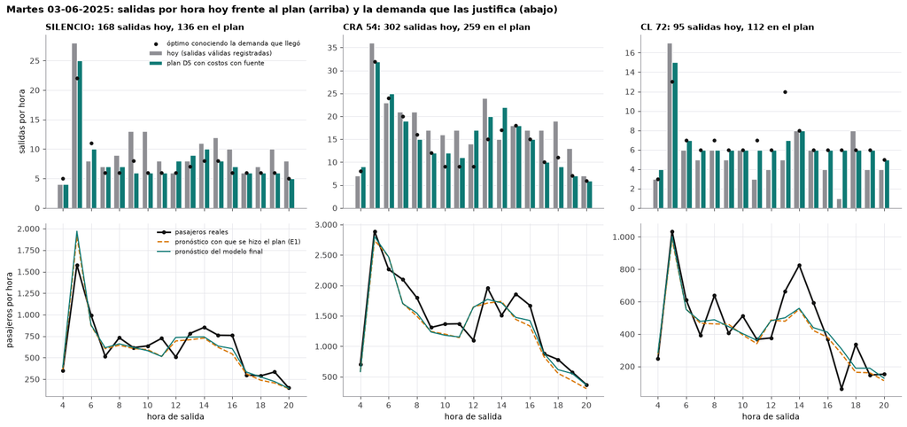

**Lectura.** El MILP de las tres rutas se resolvió en vivo en 1,1 s y reproduce hora a hora el plan guardado por `costos/reoptimizar_d5.py` (sí en las 51 horas). Ese martes el plan pone **507 salidas válidas** frente a 565 que hizo Sobusa (hay que programar 576 porque una parte de las salidas no queda válida). No recorta parejo: en CRA 54 pone más salidas que hoy en las horas 4, 6, 12 y 14 h y menos en 5, 7, 8, 9, 10, 11, 13, 16, 17, 18, 19 y 20 h; en CL 72 sube de 95 a 112 salidas porque la regla de intervalo máximo obliga a no dejar más de 10 min entre buses. El pronóstico con que se hizo el plan fue el de **E1 fuera de muestra, h = 7 días**: previó 39.858 pasajeros y llegaron 43.128 (volveremos a esto en la sección 6).

```python
fig, axes = plt.subplots(2, 3, figsize=(16, 7.6), sharex=True)
for j, r in enumerate(ORDEN_RUTAS):
    tb = PLANES[r]["tabla"].sort_values("hora")
    h = tb["hora"].values
    ax = axes[0, j]
    ax.bar(h - 0.2, tb["n_S0"], width=0.38, color=GRIS, label="hoy (salidas válidas registradas)", edgecolor="white", linewidth=1)
    ax.bar(h + 0.2, tb["x_plan"], width=0.38, color=TURQ, label="plan D5 con costos con fuente", edgecolor="white", linewidth=1)
    ax.scatter(h, tb["x_oraculo"], color=REAL, s=14, zorder=3, label="óptimo conociendo la demanda que llegó")
    ax.set_title(f"{r}: {num(tb['n_S0'].sum())} salidas hoy, {num(tb['x_plan'].sum())} en el plan", loc="left")
    ax.grid(axis="x", visible=False)
    a2 = axes[1, j]
    v4 = EV[(EV["dia"] == FECHA) & (EV["ruta"] == r)].sort_values("hora")
    a2.plot(h, tb["real"], color=REAL, marker="o", ms=4, label="pasajeros reales")
    a2.plot(h, tb["pax_pred"], color=AMBAR, ls="--", lw=1.6, label="pronóstico con que se hizo el plan (E1)")
    a2.plot(v4["hora"], v4["prediccion"], color=TURQ, lw=1.4, label="pronóstico del modelo final")
    a2.yaxis.set_major_formatter(FMT_MILES)
    a2.set_xticks(range(4, 21, 2))
    a2.set_xlabel("hora de salida")
axes[0, 0].set_ylabel("salidas por hora")
axes[1, 0].set_ylabel("pasajeros por hora")
axes[0, 0].legend(loc="upper right", fontsize=8)
axes[1, 0].legend(loc="upper right", fontsize=8)
fig.suptitle(f"Martes {FECHA:%d-%m-%Y}: salidas por hora hoy frente al plan (arriba) y la demanda que las justifica (abajo)",
             fontweight="bold", x=0.01, ha="left")
fig.tight_layout()
plt.show()

tc = PLANES["CRA 54"]["tabla"]
MAS = tc.loc[tc["x_plan"] > tc["n_S0"], "hora"].tolist()
MENOS_H = tc.loc[tc["x_plan"] < tc["n_S0"], "hora"].tolist()
tl = PLANES["CL 72"]["tabla"]
md(f"""**Lectura.** El MILP de las tres rutas se resolvió en vivo en {num(T_PLAN, 1)} s y reproduce hora a hora el plan guardado por
`costos/reoptimizar_d5.py` ({'sí' if all(RES_DIA['plan = referencia guardada']) else 'NO'} en las 51 horas). Ese martes el plan pone
**{num(TOT_DIA['salidas del plan'])} salidas válidas** frente a {num(TOT_DIA['salidas válidas hoy'])} que hizo Sobusa (hay que programar
{num(TOT_DIA['salidas a programar'])} porque una parte de las salidas no queda válida). No recorta parejo: en CRA 54 pone más salidas que hoy
en las horas {horas_txt(MAS)} y menos en {horas_txt(MENOS_H)}; en CL 72 sube de {num(tl['n_S0'].sum())} a {num(tl['x_plan'].sum())} salidas
porque la regla de intervalo máximo obliga a no dejar más de {num(P['INTERVALO_MAX']['Laboral'], 0)} min entre buses. El pronóstico con que
se hizo el plan fue el de **{FUENTE_PRON}**: previó {num(TOT_DIA['pasajeros previstos (E1)'])} pasajeros y llegaron
{num(TOT_DIA['pasajeros reales'])} (volveremos a esto en la sección 6).""")
```

### 5.2 El plan de todo 2025

El mismo MILP se resolvió para los 365 días de 2025 con el pronóstico a una semana (`costos/reoptimizar_d5.py`). Sus salidas por hora están en `costos/resultados/d5_reoptimizado_decisiones.parquet` (columna `x_corrida_1`) y sus totales en `d5_reoptimizado.csv`, fila «D5 costos nuevos, pago por hora, e=0,5». La operación de hoy se resume en `experimentos/D5_optimizacion_milp/escenarios.csv` (escenario S0).

```python
REO = leer_csv_es(COSTOS / "d5_reoptimizado.csv").set_index("corrida")
CORR_B = "D5 costos nuevos, pago por hora, e=0,5"
FB = REO.loc[CORR_B]
DEC = pd.read_parquet(COSTOS / "d5_reoptimizado_decisiones.parquet")
ESC = pd.read_csv(EXP / "D5_optimizacion_milp" / "escenarios.csv")
S0 = ESC[(ESC["ruta"] == "Todas") & (ESC["tipo_dia"] == "Todos") & (ESC["escenario"] == "S0 oferta real")].iloc[0]
ND = DEC["dia"].nunique()
SAL_HOY, SAL_PLAN = DEC["n_S0"].sum() / ND, DEC["x_corrida_1"].sum() / ND
PAX_DIA = DEC["real"].sum() / ND
BH_CAMBIO = (FB["buses_hora_dia"] / S0["buses_hora_dia"] - 1) * 100

ANUAL = pd.DataFrame({
    "hoy (operación real 2025)": [SAL_HOY, S0["buses_hora_dia"], S0["espera_media_min"], S0["pax_sobre_capacidad_dia"], S0["pct_horas_fc_mayor_1"]],
    "plan que reasigna": [SAL_PLAN, FB["buses_hora_dia"], FB["espera_media_min"], FB["pax_sobre_capacidad_dia"], FB["pct_horas_fc_mayor_1"]],
}, index=["salidas válidas por día", "buses-hora por día", "espera media (min)", "pasajeros sobre la capacidad por día",
          "horas con factor de carga > 1 (%)"])
ANUAL["cambio (%)"] = (ANUAL["plan que reasigna"] / ANUAL["hoy (operación real 2025)"] - 1) * 100
ANUAL.index.name = f"promedio de los {ND} días de 2025, tres rutas"
tabla(ANUAL, dec=2)

NDT = DEC.groupby("tipo_dia")["dia"].nunique()
RT = DEC.groupby(["ruta", "tipo_dia"])[["n_S0", "x_corrida_1"]].sum().div(NDT, axis=0, level="tipo_dia")
RT = RT.rename(columns={"n_S0": "salidas por día hoy", "x_corrida_1": "salidas por día con el plan"}).reindex(
    pd.MultiIndex.from_product([ORDEN_RUTAS, TIPOS], names=["ruta", "tipo de día"]))
RT["cambio"] = RT["salidas por día con el plan"] - RT["salidas por día hoy"]
RR = DEC.groupby("ruta")[["n_S0", "x_corrida_1"]].sum().div(ND).loc[ORDEN_RUTAS]
tabla(RT, dec=1)

verificar("inicio_salidas_dia_hoy", SAL_HOY)
verificar("inicio_salidas_dia_plan", SAL_PLAN)
verificar_ref("Salidas por día hoy: decisiones = escenarios.csv (S0)", SAL_HOY, S0["salidas_dia"], "D5 · escenarios.csv", tol=1e-9)
verificar_ref("Salidas por día del plan: decisiones = d5_reoptimizado.csv", SAL_PLAN, FB["salidas_dia"], "costos · d5_reoptimizado.csv", tol=1e-9)
verificar("inicio_pax_dia_2025", PAX_DIA)
verificar("inicio_buses_hora_hoy", S0["buses_hora_dia"])
verificar("inicio_buses_hora_plan", FB["buses_hora_dia"])
verificar("inicio_espera_hoy", S0["espera_media_min"])
verificar("inicio_espera_plan", FB["espera_media_min"])
verificar("inicio_sobrecapacidad_hoy", S0["pax_sobre_capacidad_dia"])
verificar("inicio_sobrecapacidad_plan", FB["pax_sobre_capacidad_dia"])
verificar("inicio_horas_fc_mayor_1", S0["pct_horas_fc_mayor_1"], "hoy")
verificar("inicio_horas_fc_mayor_1", FB["pct_horas_fc_mayor_1"], "plan")
```

| promedio de los 365 días de 2025, tres rutas | hoy (operación real 2025) | plan que reasigna | cambio (%) |
| --- | --- | --- | --- |
| salidas válidas por día | 459,88 | 450,90 | −1,95 |
| buses-hora por día | 1.731,69 | 1.722,52 | −0,53 |
| espera media (min) | 4,43 | 4,30 | −2,90 |
| pasajeros sobre la capacidad por día | 317,10 | 266,62 | −15,92 |
| horas con factor de carga > 1 (%) | 11,67 | 6,79 | −41,78 |

| ruta | tipo de día | salidas por día hoy | salidas por día con el plan | cambio |
| --- | --- | --- | --- | --- |
| SILENCIO | Laboral | 143,9 | 137,5 | −6,4 |
|  | Sábado | 131,5 | 112,3 | −19,2 |
|  | Domingo/festivo | 89,9 | 65,3 | −24,6 |
| CRA 54 | Laboral | 271,8 | 258,9 | −12,9 |
|  | Sábado | 242,4 | 219,4 | −23,0 |
|  | Domingo/festivo | 161,1 | 116,5 | −44,6 |
| CL 72 | Laboral | 87,9 | 114,5 | 26,6 |
|  | Sábado | 81,8 | 102,1 | 20,3 |
|  | Domingo/festivo | 54,4 | 65,9 | 11,4 |

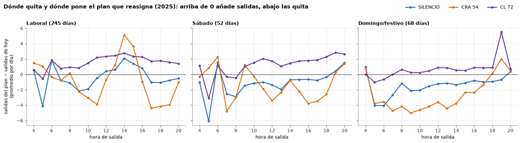

**Lectura.** En el promedio de 2025, el plan pone 450,9 salidas válidas por día frente a 459,9 de hoy, con casi los mismos buses-hora (−0,5 %), **menos espera** (4,43 → 4,30 min) y **menos pasajeros por encima de la capacidad** (317 → 267 por día). No es un recorte: es una **reasignación**. Quita salidas en los valles de CRA 54 laboral (las horas 9, 10, 11, 17, 18, 19 y 20 h pierden al menos una salida por día en promedio), en SILENCIO y en los domingos y festivos, y las pone en CRA 54 en las horas 4, 5, 13, 14 y 15 h y en CL 72, que pasa de 80,8 a 103,7 salidas por día.

```python
DIF_H = (DEC.assign(d=DEC["x_corrida_1"] - DEC["n_S0"]).groupby(["tipo_dia", "ruta", "hora"])["d"].sum()
         .div(NDT, level="tipo_dia"))
fig, axes = plt.subplots(1, 3, figsize=(16, 4.4), sharey=True)
for ax, t in zip(axes, TIPOS):
    for r in ORDEN_RUTAS:
        s = DIF_H.loc[t, r].reindex(range(4, 21))
        ax.plot(s.index, s.values, marker="o", ms=4, color=COL_RUTA[r], label=r)
    ax.axhline(0, color=TINTA, lw=0.9)
    ax.set_title(f"{t} ({NDT[t]} días)", loc="left")
    ax.set_xticks(range(4, 21, 2))
    ax.set_xlabel("hora de salida")
axes[0].set_ylabel("salidas del plan − salidas de hoy\n(promedio por día)")
manejadores, etiquetas = axes[0].get_legend_handles_labels()
fig.legend(manejadores, etiquetas, loc="upper right", ncol=3, bbox_to_anchor=(0.99, 1.0))
fig.suptitle("Dónde quita y dónde pone el plan que reasigna (2025): arriba de 0 añade salidas, abajo las quita", fontweight="bold", x=0.01, ha="left")
fig.tight_layout(rect=(0, 0, 1, 0.97))
plt.show()

lab = DIF_H.loc["Laboral", "CRA 54"]
LAB_MAS, LAB_MENOS = lab[lab >= 1].index.tolist(), lab[lab <= -1].index.tolist()
md(f"""**Lectura.** En el promedio de 2025, el plan pone {num(SAL_PLAN, 1)} salidas válidas por día frente a {num(SAL_HOY, 1)} de hoy, con
casi los mismos buses-hora ({pct(BH_CAMBIO, 1, True)}), **menos espera** ({num(S0['espera_media_min'], 2)} → {num(FB['espera_media_min'], 2)} min) y
**menos pasajeros por encima de la capacidad** ({num(S0['pax_sobre_capacidad_dia'], 0)} → {num(FB['pax_sobre_capacidad_dia'], 0)} por día). No es
un recorte: es una **reasignación**. Quita salidas en los valles de CRA 54 laboral (las horas {horas_txt(LAB_MENOS)} pierden al
menos una salida por día en promedio), en SILENCIO y en los domingos y festivos, y las pone en CRA 54 en las horas {horas_txt(LAB_MAS)}
y en CL 72, que pasa de {num(RR.loc['CL 72', 'n_S0'], 1)} a {num(RR.loc['CL 72', 'x_corrida_1'], 1)} salidas por día.""")
```

### 5.3 El canje y la elasticidad β

Quitar una salida ahorra operación pero puede perder pasajeros; añadirla cuesta operación pero puede ganarlos. Cuánto se pierde depende de la **elasticidad β** de los pasajeros a las salidas: con 10 % menos salidas en una franja se pierde β × 10 % de sus pasajeros. E7 la midió con un experimento natural (viajes que se registraron y no salieron por fallas imprevistas).

Hay dos formas de contar:

- **Conservadora:** solo cuentan los pasajeros perdidos donde se quitan salidas; los que se ganan donde se añaden no se cuentan (no se han medido).
- **Simétrica:** los ganados cuentan igual que los perdidos.

| plan que reasigna, β = 0,70, conductor pagado por hora | conservadora | simétrica |
| --- | --- | --- |
| ahorro en operación (M COP/año) | 501,1 | 501,1 |
| pasajes perdidos (M COP/año) | −3.326,3 | −3.326,3 |
| pasajes de los pasajeros ganados (M COP/año) | 0,0 | 4.425,3 |
| saldo (M COP/año) | −2.825,1 | 1.600,2 |
| pasajeros en riesgo por día | 2.863,9 | 2.863,9 |
| pasajeros netos por día | −2.863,9 | 946,3 |

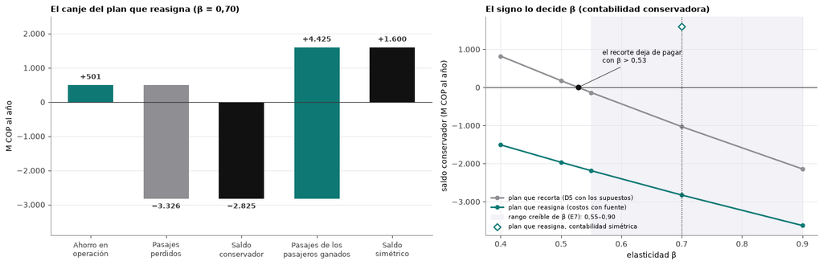

```python
AHORRO = FB["ahorro_operativo_pago_hora_Mcop"]
NETO_C, NETO_S = FB["neto_pago_hora_beta070_Mcop"], FB["neto_simetrico_pago_hora_beta070_Mcop"]
PAX_RIESGO, PAX_NETOS = FB["pax_perdidos_dia_central"], FB["pax_netos_dia_simetrico_beta070"]
PAX_GANADOS = PAX_NETOS + PAX_RIESGO
PERD_M, GAN_M = AHORRO - NETO_C, NETO_S - NETO_C
verificar_ref("Pasajes perdidos = pasajeros en riesgo × tarifa × días (M COP)", PAX_RIESGO * P["TARIFA"] * ND / 1e6, PERD_M,
              "costos · d5_reoptimizado.csv (ahorro − saldo conservador)", tol=0.01, dec=2)
verificar_ref("Pasajes ganados = pasajeros ganados × tarifa × días (M COP)", PAX_GANADOS * P["TARIFA"] * ND / 1e6, GAN_M,
              "costos · d5_reoptimizado.csv (simétrico − conservador)", tol=0.01, dec=2)

E7 = leer_json(EXP / "E7_elasticidad" / "resultados.json")
BETA, (BETA_LO, BETA_HI) = E7["sintesis"]["beta_central"], E7["sintesis"]["beta_rango"]
BETA_HORA, BETA_HORA_IC = E7["diseno_A"][0]["beta_vi"], E7["diseno_A"][0]["ic95_vi"]
BEQ = leer_csv_es(COSTOS / "beta_equilibrio.csv").set_index("clave")
BETA_EQ = a_float(BEQ.loc["D5", "pago por hora"])
AHO = leer_csv_es(COSTOS / "ahorros_por_escenario.csv").set_index("clave")
NETO_A = AHO.loc["D5", "neto_pago_por_hora"] * 1e-6
SENS = leer_csv_es(RAIZ / "simulacion_ahorro" / "resultados" / "sensibilidad_beta.csv")

CANJE = pd.DataFrame({
    "conservadora": [AHORRO, -PERD_M, 0.0, NETO_C, PAX_RIESGO, -PAX_RIESGO],
    "simétrica": [AHORRO, -PERD_M, GAN_M, NETO_S, PAX_RIESGO, PAX_NETOS],
}, index=["ahorro en operación (M COP/año)", "pasajes perdidos (M COP/año)", "pasajes de los pasajeros ganados (M COP/año)",
          "saldo (M COP/año)", "pasajeros en riesgo por día", "pasajeros netos por día"])
CANJE.index.name = f"plan que reasigna, β = {num(BETA, 2)}, conductor pagado por hora"
tabla(CANJE, dec=1)

fig, (a1, a2) = plt.subplots(1, 2, figsize=(15, 4.9), gridspec_kw={"width_ratios": [1.15, 1]})
pasos = [("Ahorro en\noperación", AHORRO), ("Pasajes\nperdidos", -PERD_M), ("Saldo\nconservador", None),
         ("Pasajes de los\npasajeros ganados", GAN_M), ("Saldo\nsimétrico", None)]
nivel = 0.0
for i, (et, v) in enumerate(pasos):
    if v is None:
        a1.bar(i, nivel, color=REAL, width=0.6)
        val, tope = nivel, nivel
    else:
        a1.bar(i, abs(v), bottom=nivel if v >= 0 else nivel + v, color=TURQ if v >= 0 else GRIS, width=0.6)
        nivel += v
        val, tope = v, nivel if v >= 0 else nivel
    a1.text(i, tope + (120 if tope >= 0 else -120), num(val, 0, True), ha="center", va="bottom" if tope >= 0 else "top",
            fontsize=9.5, color=TINTA, fontweight="bold")
a1.axhline(0, color=TINTA, lw=0.9)
a1.set_xticks(range(len(pasos)))
a1.set_xticklabels([p[0] for p in pasos], fontsize=9)
a1.yaxis.set_major_formatter(FMT_MILES)
a1.set_ylabel("M COP al año")
a1.set_ylim(-3900, 2500)
a1.set_title(f"El canje del plan que reasigna (β = {num(BETA, 2)})", loc="left")
a1.grid(axis="x", visible=False)
for plan, col, nombre in [("a", GRIS, "plan que recorta (D5 con los supuestos)"), ("b", TURQ, "plan que reasigna (costos con fuente)")]:
    s = SENS[SENS["plan"] == plan]
    a2.plot(s["beta"], s["neto_hora_Mcop"], marker="o", ms=5, color=col, label=nombre)
a2.axvspan(BETA_LO, BETA_HI, color="#f2f2f7", zorder=0, label=f"rango creíble de β (E7): {num(BETA_LO, 2)}–{num(BETA_HI, 2)}")
a2.axvline(BETA, color=REAL, lw=1, ls=":")
a2.axhline(0, color=TINTA, lw=0.9)
a2.scatter([BETA_EQ], [0], color=REAL, s=40, zorder=4)
a2.annotate(f"el recorte deja de pagar\ncon β > {num(BETA_EQ, 2)}", (BETA_EQ, 0), xytext=(BETA_EQ + 0.04, 650), fontsize=8.5,
            arrowprops=dict(arrowstyle="-", color=TINTA, lw=0.8))
a2.scatter([BETA], [NETO_S], marker="D", s=40, color="white", edgecolor=TURQ, linewidth=1.6, zorder=4,
           label="plan que reasigna, contabilidad simétrica")
a2.yaxis.set_major_formatter(FMT_MILES)
a2.set_xlabel("elasticidad β")
a2.set_ylabel("saldo conservador (M COP al año)")
a2.set_title("El signo lo decide β (contabilidad conservadora)", loc="left")
a2.legend(loc="lower left", fontsize=8)
fig.tight_layout()
plt.show()

verificar("inicio_ahorro_operativo_plan", AHORRO)
verificar("inicio_saldo_conservador", NETO_C)
verificar("inicio_saldo_simetrico", NETO_S)
verificar("inicio_pax_riesgo_plan", PAX_RIESGO)
verificar("inicio_pax_netos_simetrica", PAX_NETOS)
verificar("inicio_beta", BETA)
verificar("inicio_beta_rango", BETA_LO, "inf")
verificar("inicio_beta_rango", BETA_HI, "sup")
verificar("inicio_beta_hora", BETA_HORA)
verificar("inicio_beta_equilibrio_d5", BETA_EQ)
verificar("inicio_recorte_no_paga_d5", NETO_A)
verificar_ref("Simulación por fecha (plan a, β = 0,70) = ahorros_por_escenario.csv (D5)",
              SENS[(SENS["plan"] == "a") & (SENS["beta"] == BETA)]["neto_hora_Mcop"].iloc[0], NETO_A, "simulacion_ahorro · sensibilidad_beta.csv", tol=0.01)
verificar_ref("Simulación por fecha (plan b, β = 0,70) = d5_reoptimizado.csv",
              SENS[(SENS["plan"] == "b") & (SENS["beta"] == BETA)]["neto_hora_Mcop"].iloc[0], NETO_C, "simulacion_ahorro · sensibilidad_beta.csv", tol=0.01)
```

```python
md(f"""**Lectura.** El plan que reasigna ahorra apenas {num(AHORRO, 0)} M COP al año en operación, porque no quita buses: los mueve. El saldo
depende de cómo se cuente. Con la contabilidad **conservadora** deja un saldo de **{num(NETO_C, 0)} M COP al año** y pone en riesgo
{num(PAX_RIESGO, 0)} pasajeros por día en las horas donde quita salidas. Con la **simétrica**, los pasajeros que ganan las horas reforzadas
valen {num(GAN_M, 0)} M y el saldo es **{num(NETO_S, 0, True)} M COP al año**, con {num(PAX_NETOS, 0, True)} pasajeros netos por día.

Las dos cifras usan β = {num(BETA, 2)} (rango creíble {num(BETA_LO, 2)}–{num(BETA_HI, 2)}; medida hora a hora, {num(BETA_HORA, 2)}
con IC 95 % de {num(BETA_HORA_IC[0], 2)} a {num(BETA_HORA_IC[1], 2)}): Sobusa pierde más pasajeros que el promedio de la literatura (≈ {num(P['ELASTICIDAD'], 1)}) cuando
faltan buses, probablemente porque compite en corredores con otras empresas y transporte informal. Con esa β, el plan que **recorta**
(D5 con los supuestos iniciales) deja un saldo de {num(NETO_A, 0)} M COP al año y solo pagaría si β fuera menor que **{num(BETA_EQ, 2)}**. Por eso la
recomendación es reasignar y no recortar, y por eso lo que falta medir es si los buses añadidos ganan pasajeros.""")
mostrar_verif()
```

**Lectura.** El plan que reasigna ahorra apenas 501 M COP al año en operación, porque no quita buses: los mueve. El saldo depende de cómo se cuente. Con la contabilidad **conservadora** deja un saldo de **−2.825 M COP al año** y pone en riesgo 2.864 pasajeros por día en las horas donde quita salidas. Con la **simétrica**, los pasajeros que ganan las horas reforzadas valen 4.425 M y el saldo es **+1.600 M COP al año**, con +946 pasajeros netos por día.

Las dos cifras usan β = 0,70 (rango creíble 0,55–0,90; medida hora a hora, 0,73 con IC 95 % de 0,70 a 0,75): Sobusa pierde más pasajeros que el promedio de la literatura (≈ 0,5) cuando faltan buses, probablemente porque compite en corredores con otras empresas y transporte informal. Con esa β, el plan que **recorta** (D5 con los supuestos iniciales) deja un saldo de −1.029 M COP al año y solo pagaría si β fuera menor que **0,53**. Por eso la recomendación es reasignar y no recortar, y por eso lo que falta medir es si los buses añadidos ganan pasajeros.

**Contraste de las cifras de esta sección:** 42 de 42 coinciden con su referencia.

| cifra | qué es | calculado | referencia | fuente de la referencia | coincide |
| --- | --- | --- | --- | --- | --- |
| inicio_costo_bus_hora | Costo evitable de conductor por bus-hora en ruta (pago por hora, 182 h/mes, precios 2026) | 26.400 | 26.400 | app/DATOS.md | sí |
| inicio_costo_km | Costo evitable por km (ACPM 898 + mantenimiento 736 + llantas 231 + lubricantes 126) | 1.991 | 1.991 | app/DATOS.md | sí |
| inicio_tarifa_neta | Ingreso neto por pasajero (tarifa 3.700 × 0,86 que retiene el operador) | 3.182 | 3.182 | app/DATOS.md | sí |
| horario_parametros_milp · VALOR_TIEMPO_ESPERA | Parámetros comunes del MILP de D5 que usa el planificador | 7.000 | 7.000 | app/DATOS.md | sí |
| horario_parametros_milp · PENALIDAD_SOBRECARGA | Parámetros comunes del MILP de D5 que usa el planificador | 10.000 | 10.000 | app/DATOS.md | sí |
| horario_parametros_milp · CAPACIDAD | Parámetros comunes del MILP de D5 que usa el planificador | 50 | 50 | app/DATOS.md | sí |
| horario_parametros_milp · INTERVALO_MIN | Parámetros comunes del MILP de D5 que usa el planificador | 2 | 2 | app/DATOS.md | sí |
| Plan en vivo = plan guardado (x_corrida_1), 51 horas |  | sí | sí | costos/resultados/d5_reoptimizado_decisiones.parquet | sí |
| ciudad_3jun_pronostico · pax_previsto | Pronóstico que tenía el plan ese día frente a lo que llegó | 39.858 | 39.858 | app/DATOS.md | sí |
| ciudad_3jun_pronostico · pax_real_tabla | Pronóstico que tenía el plan ese día frente a lo que llegó | 43.128 | 43.128 | app/DATOS.md | sí |
| ciudad_3jun_pronostico · salidas_validas_real | Pronóstico que tenía el plan ese día frente a lo que llegó | 565 | 565 | app/DATOS.md | sí |
| ciudad_3jun_pronostico · salidas_plan | Pronóstico que tenía el plan ese día frente a lo que llegó | 507 | 507 | app/DATOS.md | sí |
| inicio_hallazgo_3jun · salidas_plan | Hallazgo honesto del 3 de junio (laboral cargado): el plan pone 507 salidas frente a 600 reales… | 507 | 507 | app/DATOS.md | sí |
| inicio_hallazgo_3jun · salidas_programar | Hallazgo honesto del 3 de junio (laboral cargado): el plan pone 507 salidas frente a 600 reales… | 576 | 576 | app/DATOS.md | sí |
| inicio_salidas_dia_hoy | Salidas válidas por día que hace Sobusa hoy (promedio de los 365 días de 2025, tres rutas) | 459,879 | 459,879 | app/DATOS.md | sí |
| inicio_salidas_dia_plan | Salidas válidas por día con el plan que reasigna (D5 reoptimizado con costos con fuente, e = 0,… | 450,904 | 450,904 | app/DATOS.md | sí |
| Salidas por día hoy: decisiones = escenarios.csv (S0) |  | 459,8795 | 459,8795 | D5 · escenarios.csv | sí |
| Salidas por día del plan: decisiones = d5_reoptimizado.csv |  | 450,9041 | 450,9041 | costos · d5_reoptimizado.csv | sí |
| inicio_pax_dia_2025 | Pasajeros por día en las tres rutas (viajes válidos, 2025) | 35.266,85 | 35.266,85 | app/DATOS.md | sí |
| inicio_buses_hora_hoy | Buses-hora por día de la operación real 2025 | 1.731,69 | 1.731,69 | app/DATOS.md | sí |
| inicio_buses_hora_plan | Buses-hora por día con el plan que reasigna (−0,5 % frente a hoy) | 1.722,52 | 1.722,52 | app/DATOS.md | sí |
| inicio_espera_hoy | Espera media estimada hoy (intervalos del punto medio con la irregularidad de D4) | 4,4299 | 4,4299 | app/DATOS.md | sí |
| inicio_espera_plan | Espera media con el plan que reasigna | 4,3016 | 4,3016 | app/DATOS.md | sí |
| inicio_sobrecapacidad_hoy | Pasajeros por día por encima de la capacidad (50) en el tramo crítico, hoy | 317,104 | 317,104 | app/DATOS.md | sí |
| inicio_sobrecapacidad_plan | Pasajeros por día por encima de la capacidad con el plan que reasigna (−16 %) | 266,615 | 266,615 | app/DATOS.md | sí |
| inicio_horas_fc_mayor_1 · hoy | Horas con factor de carga > 1, hoy frente al plan | 11,6709 | 11,6709 | app/DATOS.md | sí |
| inicio_horas_fc_mayor_1 · plan | Horas con factor de carga > 1, hoy frente al plan | 6,795 | 6,795 | app/DATOS.md | sí |
| Pasajes perdidos = pasajeros en riesgo × tarifa × días (M COP) |  | 3.326,26 | 3.326,26 | costos · d5_reoptimizado.csv (ahorro − saldo conservador) | sí |
| Pasajes ganados = pasajeros ganados × tarifa × días (M COP) |  | 4.425,34 | 4.425,34 | costos · d5_reoptimizado.csv (simétrico − conservador) | sí |
| inicio_ahorro_operativo_plan | Ahorro en operación del plan que reasigna (km + conductor por hora) | 501,128 | 501,128 | app/DATOS.md | sí |
| inicio_saldo_conservador | Saldo anual del plan que reasigna con la contabilidad conservadora (ahorro operativo − pasajes … | −2.825,13 | −2.825,13 | app/DATOS.md | sí |
| inicio_saldo_simetrico | Saldo anual del plan que reasigna con la contabilidad simétrica | 1.600,21 | 1.600,21 | app/DATOS.md | sí |
| inicio_pax_riesgo_plan | Pasajeros por día en riesgo con el plan que reasigna (contabilidad conservadora: solo los perdi… | 2.863,93 | 2.863,93 | app/DATOS.md | sí |
| inicio_pax_netos_simetrica | Pasajeros netos por día si los ganados donde se añaden salidas cuentan igual que los perdidos (… | 946,317 | 946,317 | app/DATOS.md | sí |
| inicio_beta | Elasticidad β: con 10 % menos salidas en una franja se pierde β × 10 % de sus pasajeros | 0,7 | 0,7 | app/DATOS.md | sí |
| inicio_beta_rango · inf | Rango creíble de β | 0,55 | 0,55 | app/DATOS.md | sí |
| inicio_beta_rango · sup | Rango creíble de β | 0,9 | 0,9 | app/DATOS.md | sí |
| inicio_beta_hora | β medida por hora con variables instrumentales (diseño A principal) | 0,7259 | 0,7259 | app/DATOS.md | sí |
| inicio_beta_equilibrio_d5 | β por encima de la cual el plan que recorta (D5 original) deja de pagar, con costos con fuente … | 0,5285 | 0,5285 | app/DATOS.md | sí |
| inicio_recorte_no_paga_d5 | Saldo anual del plan que recorta (D5 original con sus supuestos), revalorado con costos con fue… | −1.029,12 | −1.029,12 | app/DATOS.md | sí |
| Simulación por fecha (plan a, β = 0,70) = ahorros_por_escenario.csv (D5) |  | −1.029,1157 | −1.029,1157 | simulacion_ahorro · sensibilidad_beta.csv | sí |
| Simulación por fecha (plan b, β = 0,70) = d5_reoptimizado.csv |  | −2.825,1282 | −2.825,1282 | simulacion_ahorro · sensibilidad_beta.csv | sí |

## 6. Lo honesto: lo que el plan todavía no sabe

Tres cosas que no hay que esconder:

1. **El plan de 2025 se calculó con el pronóstico de E1**, no con el modelo final ni con el híbrido: D5 se construyó antes que E11 y E12, y sus insumos (`experimentos/D5_optimizacion_milp/decisiones_2025.parquet`) traen la predicción fuera de muestra de E1. El plan sería algo mejor con el pronóstico final, pero no se ha recalculado.
2. **El modelo persona a persona de la vista 3D da un saldo peor.** `sistema_tiempo_real/calles.py` sortea cada pasajero de los conteos reales, lo deja esperar en su paradero y lo sube al primer bus del plan que pasa. A diferencia de D5, que reparte la carga de una hora entre sus buses, no limita el cupo de cada bus, y deja ver dónde el plan se queda corto. Además cuenta las salidas reconstruidas del GPS (548 válidas el 3 de junio), no las de la tabla de modelado (565 en la sección 5.1).
3. **Los pasajeros ganados no se han medido**, y de ellos depende el signo del saldo (sección 5.3).

```python
SECCION = "6 · Lo honesto"
DD = pd.read_parquet(EXP / "D5_optimizacion_milp" / "decisiones_2025.parquet")
E1C = pd.read_parquet(EXP / "E1_lgbm_salida" / "predicciones_2025.parquet")
E1C = E1C[E1C["horizonte"] == 7]
X = DD[["ruta", "dia", "hora", "real", "prediccion"]].merge(E1C[["ruta", "dia", "hora", "prediccion"]], on=["ruta", "dia", "hora"],
                                                            suffixes=("", "_e1"), validate="one_to_one")
WAPE_PLAN = wape(DD["real"], DD["prediccion"])
README11 = (E11 / "README.md").read_text(encoding="utf-8")
verificar_ref("El pronóstico de D5 es el archivo de E1 (dif. máx.)", float(np.abs(X["prediccion"] - X["prediccion_e1"]).max()), 0,
              "experimentos/E1_lgbm_salida/predicciones_2025.parquet")
verificar_ref("WAPE del pronóstico de D5 = el que E11 documenta para la variante (c) de E1", f"guarda la variante (c), con WAPE {pct(WAPE_PLAN, 2)}" in README11,
              True, "experimentos/E11_modelo_mejorado/README.md")

d3 = EV[EV["dia"] == FECHA]
TOT3 = {"E1 (usado por el plan)": DD.loc[DD["dia"] == FECHA, "prediccion"].sum(), "Modelo final (E11, V4)": d3["prediccion"].sum(),
        "Híbrido (E12)": d3["pred_hibrido"].sum()}
REAL3 = d3["real"].sum()
PRON = pd.DataFrame({"WAPE 2025, h = 7 (%)": [WAPE_PLAN, GLOB.loc[V4, "WAPE (%)"], GLOB.loc[HB, "WAPE (%)"]],
                     f"pasajeros previstos el {FECHA:%d-%m}": list(TOT3.values()),
                     f"error del total del {FECHA:%d-%m} (%)": [(v / REAL3 - 1) * 100 for v in TOT3.values()]}, index=list(TOT3))
PRON.index.name = f"pronóstico (real del {FECHA:%d-%m}: {num(REAL3)} pasajeros)"
tabla(PRON, dec={"WAPE 2025, h = 7 (%)": 2, f"pasajeros previstos el {FECHA:%d-%m}": 0, f"error del total del {FECHA:%d-%m} (%)": 1})
```

| pronóstico (real del 03-06: 43.128 pasajeros) | WAPE 2025, h = 7 (%) | pasajeros previstos el 03-06 | error del total del 03-06 (%) |
| --- | --- | --- | --- |
| E1 (usado por el plan) | 14,38 | 39.858 | −7,6 |
| Modelo final (E11, V4) | 13,94 | 41.003 | −4,9 |
| Híbrido (E12) | 13,62 | 41.287 | −4,3 |

```python
CAL = leer_csv_es(RAIZ / "sistema_tiempo_real" / "replay" / "dias" / "calles" / "resumen_2025.csv")


def saldos(g):
    r, p = g[g["lado"] == "real"].iloc[0], g[g["lado"] == "plan"].iloc[0]
    ahorro = r["costo_Mcop"] - p["costo_Mcop"]
    cons = ahorro - p["pasajes_perdidos_Mcop"]
    return pd.Series({"días": r["dias"], "salidas reales": r["salidas"], "salidas válidas reales": r["salidas_validas"],
                      "salidas del plan": p["salidas"], "ahorro en operación (M COP)": ahorro, "pasajes perdidos (M COP)": p["pasajes_perdidos_Mcop"],
                      "pasajeros ganados (simétrica)": p["ganados_simetrico"], "saldo conservador (M COP)": cons,
                      "saldo simétrico (M COP)": cons + p["ganados_simetrico"] * P["TARIFA"] / 1e6,
                      "pasajeros en riesgo por día": (p["perdidos_beta"] + p["perdidos_sin_bus"]) / r["dias"],
                      "sobre la capacidad por día, real": r["sobre_capacidad"] / r["dias"], "sobre la capacidad por día, plan": p["sobre_capacidad"] / r["dias"]})


P2P = pd.DataFrame({k: saldos(g) for k, g in CAL.groupby("grupo", sort=False)}).T
tabla(P2P, dec=1, enteros=("días", "salidas reales", "salidas válidas reales", "salidas del plan"))
T25 = P2P.loc["Todo 2025"]
DIAS_P2P = int(T25["días"])
COMPARA = pd.DataFrame({
    f"contabilidad D5 / costos ({ND} días)": [NETO_C, NETO_S, NETO_C / ND, NETO_S / ND, PAX_RIESGO],
    f"persona a persona, vista 3D ({DIAS_P2P} días con GPS)": [T25["saldo conservador (M COP)"], T25["saldo simétrico (M COP)"],
                                                              T25["saldo conservador (M COP)"] / DIAS_P2P, T25["saldo simétrico (M COP)"] / DIAS_P2P,
                                                              T25["pasajeros en riesgo por día"]],
}, index=["saldo conservador del periodo (M COP)", "saldo simétrico del periodo (M COP)", "saldo conservador por día (M COP)",
          "saldo simétrico por día (M COP)", "pasajeros en riesgo por día"])
tabla(COMPARA, dec=2)

J3 = leer_calles(FECHA.date())["resumen"]["dia"]
D3 = pd.DataFrame({"real": J3["real"], "plan": J3["plan"]}).loc[
    ["salidas", "salidas_validas", "salidas_programar", "buses_hora", "km", "pax", "espera_media_min", "sobre_capacidad", "costo_Mcop",
     "perdidos_beta", "perdidos_sin_bus", "ganados_simetrico", "pasajes_perdidos_Mcop"]]
D3.index = D3.index.map({"salidas": "salidas registradas", "salidas_validas": "salidas válidas con GPS", "salidas_programar": "salidas a programar",
                          "buses_hora": "buses-hora", "km": "km recorridos", "pax": "pasajeros", "espera_media_min": "espera media (min)",
                          "sobre_capacidad": "personas sobre la capacidad", "costo_Mcop": "costo de operación (M COP)",
                          "perdidos_beta": "pasajeros perdidos por la regla de β", "perdidos_sin_bus": "pasajeros sin bus del plan en 20 min",
                          "ganados_simetrico": "pasajeros ganados (contabilidad simétrica)", "pasajes_perdidos_Mcop": "pasajes perdidos (M COP)"})
D3.index.name = f"{FECHA:%d-%m-%Y}, persona a persona"
display(D3.map(lambda v: num(v, 2) if isinstance(v, float) and not float(v).is_integer() else num(v, 0)))
AH3 = J3["real"]["costo_Mcop"] - J3["plan"]["costo_Mcop"]
PERD3 = J3["plan"]["perdidos_beta"] + J3["plan"]["perdidos_sin_bus"]

verificar("inicio_persona_a_persona_saldo", T25["ahorro en operación (M COP)"], "ahorro_operacion_Mcop")
verificar("inicio_persona_a_persona_saldo", T25["pasajes perdidos (M COP)"], "pasajes_perdidos_Mcop")
verificar("inicio_persona_a_persona_saldo", T25["saldo conservador (M COP)"], "saldo_conservador_Mcop")
verificar("inicio_persona_a_persona_saldo", T25["pasajeros ganados (simétrica)"], "ganados_simetrico_pax")
verificar("inicio_dias_gps_2025", DIAS_P2P)
for k, v in [("salidas_real", J3["real"]["salidas"]), ("salidas_validas_real", J3["real"]["salidas_validas"]),
             ("salidas_plan", J3["plan"]["salidas"]), ("salidas_programar", J3["plan"]["salidas_programar"])]:
    verificar("inicio_hallazgo_3jun", v, k)
verificar("ciudad_3jun_balance", AH3, "ahorro_operacion_Mcop")
verificar("ciudad_3jun_balance", J3["plan"]["pasajes_perdidos_Mcop"], "pasajes_perdidos_Mcop")
verificar("ciudad_3jun_balance", AH3 - J3["plan"]["pasajes_perdidos_Mcop"], "saldo_conservador_Mcop")
verificar("ciudad_3jun_balance", J3["plan"]["ganados_simetrico"] * P["TARIFA"] / 1e6, "valor_ganados_Mcop")
verificar_ref("Salidas del plan del 3 de junio en la vista 3D = MILP en vivo", J3["plan"]["salidas"], TOT_DIA["salidas del plan"],
              "sistema_tiempo_real/replay/dias/calles/2025-06-03.js", dec=0)
```

|  | días | salidas reales | salidas válidas reales | salidas del plan | ahorro en operación (M COP) | pasajes perdidos (M COP) | pasajeros ganados (simétrica) | saldo conservador (M COP) | saldo simétrico (M COP) | pasajeros en riesgo por día | sobre la capacidad por día, real | sobre la capacidad por día, plan |
| --- | --- | --- | --- | --- | --- | --- | --- | --- | --- | --- | --- | --- |
| Todo 2025 | 353 | 173.349 | 159.598 | 159.341 | 1.384,4 | 4.596,1 | 1.735.830,3 | −3.211,7 | 2.311,7 | 4.091,8 | 387,6 | 2.742,1 |
| Domingo/festivo | 65 | 22.670 | 19.477 | 16.081 | 1.230,8 | 902,1 | 127.145,7 | 328,7 | 733,3 | 4.361,6 | 30,7 | 547,7 |
| Laboral | 237 | 126.003 | 117.303 | 121.138 | −204,7 | 3.019,2 | 1.424.385,4 | −3.223,9 | 1.308,5 | 4.003,5 | 518,9 | 3.474,1 |
| Sábado | 51 | 24.676 | 22.818 | 22.122 | 358,2 | 674,8 | 184.299,2 | −316,6 | 269,8 | 4.158,5 | 232,6 | 2.137,5 |

|  | contabilidad D5 / costos (365 días) | persona a persona, vista 3D (353 días con GPS) |
| --- | --- | --- |
| saldo conservador del periodo (M COP) | −2.825,13 | −3.211,70 |
| saldo simétrico del periodo (M COP) | 1.600,21 | 2.311,71 |
| saldo conservador por día (M COP) | −7,74 | −9,10 |
| saldo simétrico por día (M COP) | 4,38 | 6,55 |
| pasajeros en riesgo por día | 2.863,93 | 4.091,80 |

| 03-06-2025, persona a persona | real | plan |
| --- | --- | --- |
| salidas registradas | 600 | 507 |
| salidas válidas con GPS | 548 | — |
| salidas a programar | — | 576 |
| buses-hora | 2.214,11 | 1.961,68 |
| km recorridos | 35.246,85 | 31.271,73 |
| pasajeros | 46.980 | 41.101 |
| espera media (min) | 3,05 | 3,88 |
| personas sobre la capacidad | 516 | 3.838 |
| costo de operación (M COP) | 128,64 | 114,06 |
| pasajeros perdidos por la regla de β | 0 | 4.974 |
| pasajeros sin bus del plan en 20 min | 0 | 905 |
| pasajeros ganados (contabilidad simétrica) | 0 | 3.580,78 |
| pasajes perdidos (M COP) | 0 | 18,71 |

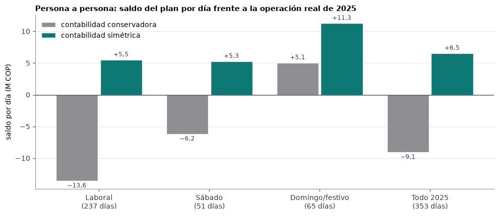

**Lectura.** (1) El plan de todo 2025 usó el pronóstico de E1 (14,38 % de WAPE), no el del modelo final (13,94 %) ni el del híbrido (13,62 %). El 03-06 se notó: E1 previó 39.858 pasajeros, −7,6 % frente a los 43.128 que llegaron; el modelo final habría previsto 41.003 (−4,9 %).

(2) Con el modelo persona a persona, en los 353 días de 2025 con GPS el plan ahorra 1.384 M COP de operación pero pierde 4.596 M en pasajes: saldo de **−3.212 M COP** con la contabilidad conservadora y +2.312 M con la simétrica (con la contabilidad de D5 eran −2.825 y +1.600 M en 365 días). Pone en riesgo 4.092 pasajeros por día, no 2.864, y las personas por encima de la capacidad suben de 388 a 2.742 por día. Solo los domingos y festivos dejan saldo positivo con la cuenta conservadora. El 03-06 es el caso extremo: el plan pone 507 salidas frente a 600 reales (548 válidas con GPS), pierde 5.879 pasajeros y las personas sobre la capacidad pasan de 516 a 3.838. D5 no lo ve porque reparte la carga de la hora entre los buses de la hora; falta una restricción de cupo por bus.

(3) Las dos contabilidades difieren en miles de millones y el signo lo decide algo que no se ha medido: cuántos pasajeros se pierden con un recorte **planificado** y cuántos se ganan con un refuerzo. **Por eso, antes de cambiar la operación, hace falta el piloto.**

**Contraste de las cifras de esta sección:** 16 de 16 coinciden con su referencia.

| cifra | qué es | calculado | referencia | fuente de la referencia | coincide |
| --- | --- | --- | --- | --- | --- |
| El pronóstico de D5 es el archivo de E1 (dif. máx.) |  | 0,0000 | 0,0000 | experimentos/E1_lgbm_salida/predicciones_2025.parquet | sí |
| WAPE del pronóstico de D5 = el que E11 documenta para la variante (c) de E1 |  | sí | sí | experimentos/E11_modelo_mejorado/README.md | sí |
| inicio_persona_a_persona_saldo · ahorro_operacion_Mcop | Saldo de todo 2025 (353 días con GPS) con el modelo persona a persona de la vista 3D: ahorro de… | 1.384,4 | 1.384,4 | app/DATOS.md | sí |
| inicio_persona_a_persona_saldo · pasajes_perdidos_Mcop | Saldo de todo 2025 (353 días con GPS) con el modelo persona a persona de la vista 3D: ahorro de… | 4.596,1 | 4.596,1 | app/DATOS.md | sí |
| inicio_persona_a_persona_saldo · saldo_conservador_Mcop | Saldo de todo 2025 (353 días con GPS) con el modelo persona a persona de la vista 3D: ahorro de… | −3.211,7 | −3.211,7 | app/DATOS.md | sí |
| inicio_persona_a_persona_saldo · ganados_simetrico_pax | Saldo de todo 2025 (353 días con GPS) con el modelo persona a persona de la vista 3D: ahorro de… | 1.735.830,3 | 1.735.830,3 | app/DATOS.md | sí |
| inicio_dias_gps_2025 | Días de 2025 que se pueden reproducir (todos menos el último de cada mes, que no tiene GPS) | 353 | 353 | app/DATOS.md | sí |
| inicio_hallazgo_3jun · salidas_real | Hallazgo honesto del 3 de junio (laboral cargado): el plan pone 507 salidas frente a 600 reales… | 600 | 600 | app/DATOS.md | sí |
| inicio_hallazgo_3jun · salidas_validas_real | Hallazgo honesto del 3 de junio (laboral cargado): el plan pone 507 salidas frente a 600 reales… | 548 | 548 | app/DATOS.md | sí |
| inicio_hallazgo_3jun · salidas_plan | Hallazgo honesto del 3 de junio (laboral cargado): el plan pone 507 salidas frente a 600 reales… | 507 | 507 | app/DATOS.md | sí |
| inicio_hallazgo_3jun · salidas_programar | Hallazgo honesto del 3 de junio (laboral cargado): el plan pone 507 salidas frente a 600 reales… | 576 | 576 | app/DATOS.md | sí |
| ciudad_3jun_balance · ahorro_operacion_Mcop | Balance del 3 de junio: ahorro de operación menos pasajes perdidos (conservadora) y con la simé… | 14,5795 | 14,5795 | app/DATOS.md | sí |
| ciudad_3jun_balance · pasajes_perdidos_Mcop | Balance del 3 de junio: ahorro de operación menos pasajes perdidos (conservadora) y con la simé… | 18,707 | 18,707 | app/DATOS.md | sí |
| ciudad_3jun_balance · saldo_conservador_Mcop | Balance del 3 de junio: ahorro de operación menos pasajes perdidos (conservadora) y con la simé… | −4,1275 | −4,1275 | app/DATOS.md | sí |
| ciudad_3jun_balance · valor_ganados_Mcop | Balance del 3 de junio: ahorro de operación menos pasajes perdidos (conservadora) y con la simé… | 11,394 | 11,394 | app/DATOS.md | sí |
| Salidas del plan del 3 de junio en la vista 3D = MILP en vivo |  | 507 | 507 | sistema_tiempo_real/replay/dias/calles/2025-06-03.js | sí |

```python
TT = P2P.loc[TIPOS]
fig, ax = plt.subplots(figsize=(10, 4.4))
x = np.arange(len(TIPOS) + 1)
cons = list(TT["saldo conservador (M COP)"] / TT["días"]) + [T25["saldo conservador (M COP)"] / DIAS_P2P]
sim = list(TT["saldo simétrico (M COP)"] / TT["días"]) + [T25["saldo simétrico (M COP)"] / DIAS_P2P]
ax.bar(x - 0.2, cons, width=0.38, color=GRIS, label="contabilidad conservadora", edgecolor="white", linewidth=1)
ax.bar(x + 0.2, sim, width=0.38, color=TURQ, label="contabilidad simétrica", edgecolor="white", linewidth=1)
for xi, a, b in zip(x, cons, sim):
    ax.text(xi - 0.2, a + (0.3 if a >= 0 else -0.3), num(a, 1, True), ha="center", va="bottom" if a >= 0 else "top", fontsize=8.5, color=TINTA)
    ax.text(xi + 0.2, b + (0.3 if b >= 0 else -0.3), num(b, 1, True), ha="center", va="bottom" if b >= 0 else "top", fontsize=8.5, color=TINTA)
ax.axhline(0, color=TINTA, lw=0.9)
ax.set_xticks(x)
ax.set_xticklabels([f"{t}\n({int(n)} días)" for t, n in zip(TIPOS, TT["días"])] + [f"Todo 2025\n({DIAS_P2P} días)"])
ax.set_ylabel("saldo por día (M COP)")
ax.set_title("Persona a persona: saldo del plan por día frente a la operación real de 2025", loc="left")
ax.grid(axis="x", visible=False)
ax.legend(loc="upper left")
fig.tight_layout()
plt.show()

md(f"""**Lectura.** (1) El plan de todo 2025 usó el pronóstico de E1 ({pct(WAPE_PLAN, 2)} de WAPE), no el del modelo final
({pct(GLOB.loc[V4, 'WAPE (%)'], 2)}) ni el del híbrido ({pct(GLOB.loc[HB, 'WAPE (%)'], 2)}). El {FECHA:%d-%m} se notó: E1 previó
{num(TOT3['E1 (usado por el plan)'])} pasajeros, {pct(PRON.iloc[0, 2], 1)} frente a los {num(REAL3)} que llegaron; el modelo final habría previsto
{num(TOT3['Modelo final (E11, V4)'])} ({pct(PRON.iloc[1, 2], 1, True)}).

(2) Con el modelo persona a persona, en los {DIAS_P2P} días de 2025 con GPS el plan ahorra {num(T25['ahorro en operación (M COP)'], 0)} M COP de
operación pero pierde {num(T25['pasajes perdidos (M COP)'], 0)} M en pasajes: saldo de **{num(T25['saldo conservador (M COP)'], 0)} M COP** con la
contabilidad conservadora y {num(T25['saldo simétrico (M COP)'], 0, True)} M con la simétrica (con la contabilidad de D5 eran {num(NETO_C, 0)} y
{num(NETO_S, 0, True)} M en {ND} días). Pone en riesgo {num(T25['pasajeros en riesgo por día'], 0)} pasajeros por día, no
{num(PAX_RIESGO, 0)}, y las personas por encima de la capacidad suben de {num(T25['sobre la capacidad por día, real'], 0)} a
{num(T25['sobre la capacidad por día, plan'], 0)} por día. Solo los domingos y festivos dejan saldo positivo con la cuenta conservadora. El
{FECHA:%d-%m} es el caso extremo: el plan pone {num(J3['plan']['salidas'])} salidas frente a {num(J3['real']['salidas'])} reales
({num(J3['real']['salidas_validas'])} válidas con GPS), pierde {num(PERD3)} pasajeros y las personas sobre la capacidad pasan de
{num(J3['real']['sobre_capacidad'])} a {num(J3['plan']['sobre_capacidad'])}. D5 no lo ve porque reparte la carga de la hora entre los buses de la
hora; falta una restricción de cupo por bus.

(3) Las dos contabilidades difieren en miles de millones y el signo lo decide algo que no se ha medido: cuántos pasajeros se pierden con un
recorte **planificado** y cuántos se ganan con un refuerzo. **Por eso, antes de cambiar la operación, hace falta el piloto.**""")
mostrar_verif()
```

## 7. El piloto para medir β (P2)

**Diseño** (`experimentos/P2_piloto_beta/`): durante varias semanas, en días laborales y domingos sorteados (días alternos, sin anunciarlo al público), CRA 54 y CL 72 cambian sus salidas en unas pocas franjas: **recortes** en los valles y **refuerzos** en las horas cargadas, con una franja de control que nunca cambia. Comparar los pasajeros de los días tratados con los de control mide β para un recorte planificado (no para una falla imprevista, como E7) y mide por fin si los buses añadidos ganan pasajeros. El estimador es de variables instrumentales (la asignación sorteada es el instrumento de las salidas realizadas). P2 simuló cientos de pilotos con el ruido real de 2025 para saber qué tan precisa saldría la medición.

| franja | qué se cambia | papel | horas | salidas habituales | salidas el día tratado | intervalo habitual → tratado (min) |
| --- | --- | --- | --- | --- | --- | --- |
| R1 | CRA 54 laboral 9-11 h (valle de la mañana) | recorte | 9, 10, 11 | 16 / 15 / 16 | 13 / 12 / 13 | 3,8→4,6 / 4,0→5,0 / 3,8→4,6 |
| R2 | CRA 54 laboral 17-19 h (valle de la tarde) | recorte | 17, 18, 19 | 16 / 14 / 13 | 12 / 10 / 9 | 3,8→5,0 / 4,3→6,0 / 4,6→6,7 |
| R3 | CRA 54 domingo 9-13 h | recorte | 9, 10, 11, 12, 13 | 14 / 14 / 12 / 12 / 14 | 10 / 10 / 8 / 8 / 10 | 4,3→6,0 / 4,3→6,0 / 5,0→7,5 / 5,0→7,5 / 4,3→6,0 |
| F1 | CRA 54 laboral 14-15 h (pico de carga) | refuerzo | 14, 15 | 18 / 17 | 22 / 21 | 3,3→2,7 / 3,5→2,9 |
| F2 | CL 72 laboral 12-15 h | refuerzo | 12, 13, 14, 15 | 5 / 6 / 6 / 5 | 7 / 8 / 8 / 7 | 12,0→8,6 / 10,0→7,5 / 10,0→7,5 / 12,0→8,6 |
| C | CRA 54 laboral 7 h (control: nunca cambia) | control | 7 | 19 | 19 | 3,2→3,2 |

| 2026-10-19 a 2026-12-13: 8 semanas, 37 laborales, 8 domingos | días tratados | días de control |
| --- | --- | --- |
| R1 | 18 | 19 |
| R2 | 18 | 19 |
| R3 | 4 | 4 |
| F1 | 20 | 17 |
| F2 | 19 | 18 |

| Piloto P2 | Valor |
| --- | --- |
| Pilotos simulados (β verdadero = 0,70) | 500 |
| β estimada en promedio: variables instrumentales / MCO ingenuo | 0,703 / 0,575 |
| Error estándar de la β conjunta de recorte: simulado / analítico | 0,066 / 0,056 |
| Potencia para distinguir β = 0,70 de 0,53: simulada / analítica | 0,894 / 0,918 |
| Pasajeros en riesgo durante el piloto (β = 0,70 / β = 1) | 22.904 / 31.420 |
| … como % de los pasajeros de CRA 54 en un año | 0,30 % |
| Saldo del piloto: conservador / simétrico (M COP) | −51,9 / +22,1 |

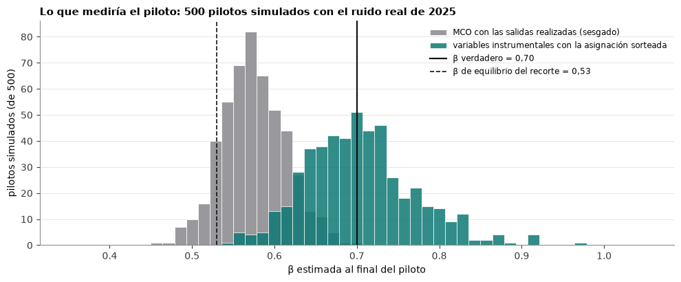

```python
SECCION = "7 · Piloto"
P2 = leer_json(EXP / "P2_piloto_beta" / "resultados.json")
FR = pd.DataFrame([{"franja": k, "qué se cambia": v["nombre"], "papel": v["rol"], "horas": ", ".join(map(str, v["horas"])),
                    "salidas habituales": " / ".join(num(s) for s in v["salidas_habituales"]),
                    "salidas el día tratado": " / ".join(num(s) for s in v["salidas_dia_tratado"]),
                    "intervalo habitual → tratado (min)": " / ".join(f"{num(a, 1)}→{num(b, 1)}" for a, b in zip(v["intervalo_habitual_min"], v["intervalo_tratado_min"]))}
                   for k, v in P2["franjas_piloto"].items()]).set_index("franja")
display(FR)
CALP = P2["calendario"]
CALT = pd.DataFrame({"días tratados": CALP["dias_tratados"], "días de control": CALP["dias_control"]})
CALT.index.name = f"{CALP['inicio']} a {CALP['fin']}: {CALP['semanas']} semanas, {CALP['dias_laborales']} laborales, {CALP['domingos']} domingos"
tabla(CALT, enteros=("días tratados", "días de control"))

REP = pd.read_parquet(EXP / "P2_piloto_beta" / "simulacion_replicas.parquet")
XR = REP[(REP["escenario"] == "principal") & (REP["beta_verdadero"] == BETA) & (REP["franja"] == "recorte conjunta")]
EQ = P2["parametros"]["beta_equilibrio_costos_fuente"]
EE_SIM = float(XR["beta_iv"].std())
POT_SIM = float(((XR["beta_iv"] - EQ) / XR["ee_iv"] > XR["t_crit1"]).mean())
POT = P2["potencia"]["diseno_propuesto"]["recorte conjunta"]
TOTP = P2["riesgo_costo"]["totales_piloto"]
PREC = pd.DataFrame([
    ("Pilotos simulados (β verdadero = " + num(BETA, 2) + ")", num(len(XR))),
    ("β estimada en promedio: variables instrumentales / MCO ingenuo", f"{num(XR['beta_iv'].mean(), 3)} / {num(XR['beta_mco'].mean(), 3)}"),
    ("Error estándar de la β conjunta de recorte: simulado / analítico", f"{num(EE_SIM, 3)} / {num(POT['ee_2025'], 3)}"),
    (f"Potencia para distinguir β = {num(BETA, 2)} de {num(EQ, 2)}: simulada / analítica", f"{num(POT_SIM, 3)} / {num(POT['potencia_070_vs_053_una_cola'], 3)}"),
    (f"Pasajeros en riesgo durante el piloto (β = {num(BETA, 2)} / β = 1)", f"{num(TOTP['pax_riesgo_piloto_beta070'])} / {num(TOTP['pax_riesgo_piloto_beta100'])}"),
    ("… como % de los pasajeros de CRA 54 en un año", pct(TOTP["pax_riesgo_piloto_pct_pax_anual_cra54"], 2)),
    ("Saldo del piloto: conservador / simétrico (M COP)", f"{num(TOTP['neto_total_piloto_Mcop_conservador'], 1)} / {num(TOTP['neto_total_piloto_Mcop_simetrico'], 1, True)}"),
], columns=["Piloto P2", "Valor"]).set_index("Piloto P2")
display(PREC)

fig, ax = plt.subplots(figsize=(10, 4.2))
bins = np.linspace(0.35, 1.05, 50)
ax.hist(XR["beta_mco"], bins=bins, color=GRIS, alpha=0.9, label="MCO con las salidas realizadas (sesgado)", edgecolor="white", linewidth=0.6)
ax.hist(XR["beta_iv"], bins=bins, color=TURQ, alpha=0.85, label="variables instrumentales con la asignación sorteada", edgecolor="white", linewidth=0.6)
ax.axvline(BETA, color=REAL, lw=1.6, label=f"β verdadero = {num(BETA, 2)}")
ax.axvline(EQ, color=REAL, lw=1.2, ls="--", label=f"β de equilibrio del recorte = {num(EQ, 2)}")
ax.set_xlabel("β estimada al final del piloto")
ax.set_ylabel(f"pilotos simulados (de {len(XR)})")
ax.set_title(f"Lo que mediría el piloto: {num(len(XR))} pilotos simulados con el ruido real de 2025", loc="left")
ax.legend(loc="upper right", fontsize=8.5)
ax.grid(axis="x", visible=False)
fig.tight_layout()
plt.show()

verificar("inicio_piloto_resumen", P2["parametros"]["semanas_piloto"], "semanas")
verificar("inicio_piloto_resumen", EE_SIM, "ee_simulado")
verificar("inicio_piloto_resumen", POT["ee_2025"], "ee_analitico")
verificar("inicio_piloto_resumen", POT_SIM, "potencia_simulada")
verificar_ref("Error estándar simulado = el de P2", EE_SIM, P2["simulacion"]["ee_analitico_vs_empirico"]["recorte conjunta"]["ee_empirico_simulacion"],
              "P2 · resultados.json", tol=1e-9)
for k in ("pax_riesgo_piloto_beta070", "pax_riesgo_piloto_beta100", "pasajes_riesgo_piloto_Mcop", "ahorro_operativo_recortes_piloto_Mcop"):
    verificar("piloto_totales", TOTP[k], k)
verificar("piloto_calendario", CALP["semanas"], "semanas")
verificar("piloto_calendario", CALP["dias_laborales"], "dias_laborales")
```

```python
md(f"""**Lectura.** En {CALP['semanas']} semanas ({CALP['inicio']} a {CALP['fin']}), con {CALP['dias_laborales']} días laborales y
{CALP['domingos']} domingos sorteados, la β conjunta de los recortes se mediría con un error estándar de **{num(EE_SIM, 3)}** (simulado;
{num(POT['ee_2025'], 3)} analítico) y una potencia de **{num(POT_SIM, 2)}** para distinguir β = {num(BETA, 2)} del equilibrio {num(EQ, 2)}. El
estimador instrumental recupera β sin sesgo (media {num(XR['beta_iv'].mean(), 2)}); el ingenuo que usa las salidas realizadas la subestima
(media {num(XR['beta_mco'].mean(), 2)}), porque las salidas que de verdad corren responden a la demanda. El costo es acotado:
{num(TOTP['pax_riesgo_piloto_beta070'])} pasajeros en riesgo ({pct(TOTP['pax_riesgo_piloto_pct_pax_anual_cra54'], 2)} de los de CRA 54 en un año) y
un saldo entre {num(TOTP['neto_total_piloto_Mcop_conservador'], 0)} y {num(TOTP['neto_total_piloto_Mcop_simetrico'], 0, True)} M COP, con reglas de
parada si se pierde más de lo proporcional o hay hacinamiento. Si la β de un recorte planificado resulta menor que {num(EQ, 2)}, los recortes
moderados pagan; si ronda {num(BETA, 2)}, solo se reasigna; y los refuerzos dirán cuál de las dos contabilidades es la correcta.""")
mostrar_verif()
```

**Lectura.** En 8 semanas (2026-10-19 a 2026-12-13), con 37 días laborales y 8 domingos sorteados, la β conjunta de los recortes se mediría con un error estándar de **0,066** (simulado; 0,056 analítico) y una potencia de **0,89** para distinguir β = 0,70 del equilibrio 0,53. El estimador instrumental recupera β sin sesgo (media 0,70); el ingenuo que usa las salidas realizadas la subestima (media 0,57), porque las salidas que de verdad corren responden a la demanda. El costo es acotado: 22.904 pasajeros en riesgo (0,30 % de los de CRA 54 en un año) y un saldo entre −52 y +22 M COP, con reglas de parada si se pierde más de lo proporcional o hay hacinamiento. Si la β de un recorte planificado resulta menor que 0,53, los recortes moderados pagan; si ronda 0,70, solo se reasigna; y los refuerzos dirán cuál de las dos contabilidades es la correcta.

**Contraste de las cifras de esta sección:** 11 de 11 coinciden con su referencia.

| cifra | qué es | calculado | referencia | fuente de la referencia | coincide |
| --- | --- | --- | --- | --- | --- |
| inicio_piloto_resumen · semanas | Piloto de 8 semanas para medir β en la calle: error estándar de la β conjunta de recorte, poten… | 8 | 8 | app/DATOS.md | sí |
| inicio_piloto_resumen · ee_simulado | Piloto de 8 semanas para medir β en la calle: error estándar de la β conjunta de recorte, poten… | 0,0664 | 0,0664 | app/DATOS.md | sí |
| inicio_piloto_resumen · ee_analitico | Piloto de 8 semanas para medir β en la calle: error estándar de la β conjunta de recorte, poten… | 0,056 | 0,056 | app/DATOS.md | sí |
| inicio_piloto_resumen · potencia_simulada | Piloto de 8 semanas para medir β en la calle: error estándar de la β conjunta de recorte, poten… | 0,894 | 0,894 | app/DATOS.md | sí |
| Error estándar simulado = el de P2 |  | 0,0664 | 0,0664 | P2 · resultados.json | sí |
| piloto_totales · pax_riesgo_piloto_beta070 | Totales del piloto: pasajeros en riesgo (y como % del año de CRA 54), pasajes, ahorro de los re… | 22.903,92 | 22.903,92 | app/DATOS.md | sí |
| piloto_totales · pax_riesgo_piloto_beta100 | Totales del piloto: pasajeros en riesgo (y como % del año de CRA 54), pasajes, ahorro de los re… | 31.419,65 | 31.419,65 | app/DATOS.md | sí |
| piloto_totales · pasajes_riesgo_piloto_Mcop | Totales del piloto: pasajeros en riesgo (y como % del año de CRA 54), pasajes, ahorro de los re… | 72,8803 | 72,8803 | app/DATOS.md | sí |
| piloto_totales · ahorro_operativo_recortes_piloto_Mcop | Totales del piloto: pasajeros en riesgo (y como % del año de CRA 54), pasajes, ahorro de los re… | 92,7932 | 92,7932 | app/DATOS.md | sí |
| piloto_calendario · semanas | Calendario: 8 semanas, días laborales, festivos dentro, domingos y días tratados/control por fr… | 8 | 8 | app/DATOS.md | sí |
| piloto_calendario · dias_laborales | Calendario: 8 semanas, días laborales, festivos dentro, domingos y días tratados/control por fr… | 37 | 37 | app/DATOS.md | sí |

## 8. Conclusiones y recomendaciones para Sobusa

Todo el texto de esta sección se genera con los valores calculados en las celdas anteriores. Debajo está el contraste de cada cifra con `app/DATOS.md` y con el informe de resultados.

```python
SECCION = "8 · Conclusiones"
g = GLOB["WAPE (%)"]
md(f"""### Conclusiones

1. **El pronóstico mejora claramente a la regla manual.** A una semana de antelación, la regla de las 8 semanas se equivoca en
   {pct(g[B1], 2)} de los pasajeros por hora de salida; el primer modelo (E1), en {pct(g[E1M], 2)}; el **modelo final** (LightGBM de Poisson,
   variante V4 de E11), en **{pct(g[V4], 2)}**, y el **híbrido** con Chronos-2 (E12), en **{pct(g[HB], 2)}**. El modelo final quita
   {pct((1 - g[V4] / g[B1]) * 100, 0)} del error y donde más ayuda es en domingos y festivos ({pct(POR_TIPO.loc['Domingo/festivo', B1], 1)} → {pct(POR_TIPO.loc['Domingo/festivo', V4], 1)}).
2. **El modelo es reproducible y sencillo de entender.** Entrenado aquí para {MESES[MES - 1]} de 2025 en {num(T_ENTRENAR, 1)} s, da las mismas
   predicciones que guardó E11. Es la demanda reciente de la misma franja (la media de las 4 mismas semanas y la regla de 8 semanas suman
   {pct(IMP.iloc[:2].sum(), 0)} de la ganancia) corregida por el calendario y entrenada sin aprender de los datos rotos.
3. **Para producción se recomienda el híbrido.** De {RKG['n_candidatos']} candidatos de E12, ningún modelo solo supera al LightGBM; el ganador
   formal combina {N_MIEMBROS} modelos y no se pudo validar en 2024. El híbrido mejora al modelo final en {num(D_H[0], 2, True)} puntos
   {ic(G_H['ic_inf'], G_H['ic_sup'])} en 2025 ({MM_H} de 12 meses) y en {num(REF24['dif_pp'], 2, True)} {ic(REF24['ic_inf'], REF24['ic_sup'])} en 2024,
   con la misma cadena del modelo final y sin GPU.
4. **La decisión es reasignar, no recortar.** Con costos con fuente, el optimizador D5 programa {num(SAL_PLAN, 0)} salidas válidas por día frente a
   {num(SAL_HOY, 0)} de hoy, con los mismos buses-hora ({pct(BH_CAMBIO, 1, True)}), menos espera ({num(S0['espera_media_min'], 2)} → {num(FB['espera_media_min'], 2)} min)
   y menos pasajeros sobre la capacidad ({num(S0['pax_sobre_capacidad_dia'], 0)} → {num(FB['pax_sobre_capacidad_dia'], 0)} por día): quita en los valles
   y en los domingos y refuerza CRA 54 laboral en las horas {horas_txt(LAB_MAS)} y CL 72. Resuelto en vivo para el {FECHA:%d-%m-%Y}, reproduce el plan guardado.
5. **El canje depende de β y de cómo se cuente.** Con β = {num(BETA, 2)} (rango {num(BETA_LO, 2)}–{num(BETA_HI, 2)}), el plan que reasigna
   deja un saldo de {num(NETO_C, 0)} M COP al año con la contabilidad conservadora ({num(PAX_RIESGO, 0)} pasajeros en riesgo por día) y de
   {num(NETO_S, 0, True)} M con la simétrica ({num(PAX_NETOS, 0, True)} pasajeros netos por día). El plan que recorta deja de pagar con β > {num(BETA_EQ, 2)}.
6. **Lo honesto.** El plan del año se calculó con el pronóstico de E1 ({pct(WAPE_PLAN, 2)}), no con el modelo final ni con el híbrido. El modelo
   persona a persona da un saldo peor ({num(T25['saldo conservador (M COP)'], 0)} M COP conservador y {num(T25['saldo simétrico (M COP)'], 0, True)} M
   simétrico en {DIAS_P2P} días) y muestra días como el {FECHA:%d-%m} en que el plan se queda corto ({num(PERD3)} pasajeros perdidos).
7. **El piloto mide lo que falta.** {CALP['semanas']} semanas en CRA 54 y CL 72 por días sorteados: error estándar {num(EE_SIM, 3)} y potencia
   {num(POT_SIM, 2)} para distinguir {num(BETA, 2)} de {num(EQ, 2)}, con {num(TOTP['pax_riesgo_piloto_beta070'])} pasajeros en riesgo
   ({pct(TOTP['pax_riesgo_piloto_pct_pax_anual_cra54'], 2)} del año de CRA 54) y un saldo entre {num(TOTP['neto_total_piloto_Mcop_conservador'], 0)}
   y {num(TOTP['neto_total_piloto_Mcop_simetrico'], 0, True)} M COP.

### Recomendaciones para Sobusa

1. **Planificar cada semana con el pronóstico, no con el promedio de 8 semanas.** Usar el híbrido (con el modelo final de E11 como respaldo,
   que no necesita Chronos-2), reentrenado cada semana con los datos nuevos para seguir el nivel de 2026.
2. **Reasignar salidas con el optimizador y los costos con fuente; no recortar.** Mover salidas de los valles de CRA 54 y de los domingos a las
   horas cargadas y a CL 72, y fijar por escrito el intervalo máximo, que decide cuántos buses necesita CL 72.
3. **Recalcular el plan del año con el pronóstico final y añadir al optimizador un cupo por bus**, para que no se repitan días como el
   {FECHA:%d-%m} en que el plan deja demasiada gente por encima de la capacidad.
4. **Correr el piloto P2 antes de cambiar la operación** y decidir con su β: si es baja, los recortes moderados pagan; si ronda {num(BETA, 2)},
   solo se reasigna.
5. **Despachar con la consola de tiempo real, primero en modo sombra**: su valor está en la hora exacta de cada salida, en cerrar huecos y en
   detectar fallas de datos, no en cambiar cuántos buses salen.
6. **Aclarar los datos y los costos**: la marca `cancelada` (muchos viajes «cancelados» sí corrieron y llevaron pasajeros), los costos reales de
   combustible y mantenimiento, la forma de pago de los conductores y `progvehiculos` de 2026.""")
```

Conclusiones

1. **El pronóstico mejora claramente a la regla manual.** A una semana de antelación, la regla de las 8 semanas se equivoca en 20,04 % de los pasajeros por hora de salida; el primer modelo (E1), en 14,40 %; el **modelo final** (LightGBM de Poisson, variante V4 de E11), en **13,94 %**, y el **híbrido** con Chronos-2 (E12), en **13,62 %**. El modelo final quita 30 % del error y donde más ayuda es en domingos y festivos (48,6 % → 19,7 %).

2. **El modelo es reproducible y sencillo de entender.** Entrenado aquí para junio de 2025 en 7,0 s, da las mismas predicciones que guardó E11. Es la demanda reciente de la misma franja (la media de las 4 mismas semanas y la regla de 8 semanas suman 83 % de la ganancia) corregida por el calendario y entrenada sin aprender de los datos rotos.

3. **Para producción se recomienda el híbrido.** De 51 candidatos de E12, ningún modelo solo supera al LightGBM; el ganador formal combina 40 modelos y no se pudo validar en 2024. El híbrido mejora al modelo final en −0,32 puntos [−0,43; −0,22] en 2025 (11 de 12 meses) y en −0,33 [−0,50; −0,14] en 2024, con la misma cadena del modelo final y sin GPU.

4. **La decisión es reasignar, no recortar.** Con costos con fuente, el optimizador D5 programa 451 salidas válidas por día frente a 460 de hoy, con los mismos buses-hora (−0,5 %), menos espera (4,43 → 4,30 min) y menos pasajeros sobre la capacidad (317 → 267 por día): quita en los valles y en los domingos y refuerza CRA 54 laboral en las horas 4, 5, 13, 14 y 15 h y CL 72. Resuelto en vivo para el 03-06-2025, reproduce el plan guardado.

5. **El canje depende de β y de cómo se cuente.** Con β = 0,70 (rango 0,55–0,90), el plan que reasigna deja un saldo de −2.825 M COP al año con la contabilidad conservadora (2.864 pasajeros en riesgo por día) y de +1.600 M con la simétrica (+946 pasajeros netos por día). El plan que recorta deja de pagar con β > 0,53.

6. **Lo honesto.** El plan del año se calculó con el pronóstico de E1 (14,38 %), no con el modelo final ni con el híbrido. El modelo persona a persona da un saldo peor (−3.212 M COP conservador y +2.312 M simétrico en 353 días) y muestra días como el 03-06 en que el plan se queda corto (5.879 pasajeros perdidos).

7. **El piloto mide lo que falta.** 8 semanas en CRA 54 y CL 72 por días sorteados: error estándar 0,066 y potencia 0,89 para distinguir 0,70 de 0,53, con 22.904 pasajeros en riesgo (0,30 % del año de CRA 54) y un saldo entre −52 y +22 M COP.

Recomendaciones para Sobusa

1. **Planificar cada semana con el pronóstico, no con el promedio de 8 semanas.** Usar el híbrido (con el modelo final de E11 como respaldo, que no necesita Chronos-2), reentrenado cada semana con los datos nuevos para seguir el nivel de 2026.

2. **Reasignar salidas con el optimizador y los costos con fuente; no recortar.** Mover salidas de los valles de CRA 54 y de los domingos a las horas cargadas y a CL 72, y fijar por escrito el intervalo máximo, que decide cuántos buses necesita CL 72.

3. **Recalcular el plan del año con el pronóstico final y añadir al optimizador un cupo por bus**, para que no se repitan días como el 03-06 en que el plan deja demasiada gente por encima de la capacidad.

4. **Correr el piloto P2 antes de cambiar la operación** y decidir con su β: si es baja, los recortes moderados pagan; si ronda 0,70, solo se reasigna.

5. **Despachar con la consola de tiempo real, primero en modo sombra**: su valor está en la hora exacta de cada salida, en cerrar huecos y en detectar fallas de datos, no en cambiar cuántos buses salen.

6. **Aclarar los datos y los costos**: la marca `cancelada` (muchos viajes «cancelados» sí corrieron y llevaron pasajeros), los costos reales de combustible y mantenimiento, la forma de pago de los conductores y `progvehiculos` de 2026.

### Contraste de cifras

Cada cifra que el cuaderno calculó y que tiene un valor en `app/DATOS.md` (el mapa verificado de las cifras de la app, con su archivo y su clave) se comparó con él con la precisión con que DATOS.md la registra; las desagregaciones se compararon con los archivos de resultados que DATOS.md cita. Después se busca en `documentos/informe_resultados.md` el texto con que se citan las cifras clave de las conclusiones.

```python
VV = pd.DataFrame(VERIF)
N_OK, N_NO, N_SIN = int((VV["coincide"] == True).sum()), int((VV["coincide"] == False).sum()), int(VV["coincide"].isna().sum())  # noqa: E712
RES_V = VV.groupby("sección").agg(cifras=("cifra", "size"), coinciden=("coincide", lambda s: int((s == True).sum())),  # noqa: E712
                                  contra_DATOS_md=("fuente de la referencia", lambda s: int((s == "app/DATOS.md").sum())))
tabla(RES_V, enteros=("cifras", "coinciden", "contra_DATOS_md"))
md(f"**{N_OK} de {len(VV)} cifras coinciden** con su referencia ({int((VV['fuente de la referencia'] == 'app/DATOS.md').sum())} contra "
   f"`app/DATOS.md` y {int((VV['fuente de la referencia'] != 'app/DATOS.md').sum())} contra el archivo de resultados que DATOS.md cita); "
   f"{N_NO} no coinciden y {N_SIN} no tienen valor de referencia.")
if N_NO:
    display(VV[VV["coincide"] == False])  # noqa: E712
```

| sección | cifras | coinciden | contra_DATOS_md |
| --- | --- | --- | --- |
| 1 · Problema y datos | 11 | 11 | 10 |
| 2 · Tabla de modelado | 12 | 12 | 10 |
| 3 · Modelo en vivo | 11 | 11 | 8 |
| 4 · Evaluación | 48 | 48 | 40 |
| 5 · Decisión | 42 | 42 | 35 |
| 6 · Lo honesto | 16 | 16 | 13 |
| 7 · Piloto | 11 | 11 | 10 |

**151 de 151 cifras coinciden** con su referencia (126 contra `app/DATOS.md` y 25 contra el archivo de resultados que DATOS.md cita); 0 no coinciden y 0 no tienen valor de referencia.

```python
CLAVE_INF = [
    ("Error de la regla manual", pct(g[B1], 2)), ("Error de E1", pct(g[E1M], 2)), ("Error del modelo final", pct(g[V4], 2)),
    ("Error del híbrido", pct(g[HB], 2)),
    ("Modelo final frente a E1 [IC 95 % del bootstrap de este cuaderno]", f"{num(D_V[0], 2, True)} {ic(D_V[1], D_V[2])}"),
    ("Híbrido frente al modelo final, 2025 [IC 95 %]", f"{num(G_H['dif_pp'], 2, True)} {ic(G_H['ic_inf'], G_H['ic_sup'])}"),
    ("Híbrido frente al modelo final, 2024 [IC 95 %]", f"{num(REF24['dif_pp'], 2, True)} {ic(REF24['ic_inf'], REF24['ic_sup'])}"),
    ("Error del modelo final en 2024", pct(REF24["V4"]["WAPE"], 2)), ("Error del ganador formal de E12", pct(RKM.loc[GAN, "WAPE"], 2)),
    ("Candidatos de E12", f"{RKG['n_candidatos']} candidatos"),
    ("Salidas por día del plan", f"{num(SAL_PLAN, 0)} salidas"), ("Salidas del plan el 3 de junio", f"{num(TOT_DIA['salidas del plan'])} salidas"),
    ("Saldo conservador del plan que reasigna (M COP/año)", num(NETO_C, 0)), ("Saldo simétrico (M COP/año)", num(NETO_S, 0, True)),
    ("Pasajeros en riesgo por día (conservadora)", num(PAX_RIESGO, 0)), ("Pasajeros netos por día (simétrica)", num(PAX_NETOS, 0, True)),
    ("β central y rango", f"{num(BETA, 2)} ({num(BETA_LO, 2)}–{num(BETA_HI, 2)})"), ("β de equilibrio del recorte", num(BETA_EQ, 2)),
    ("Saldo del plan que recorta (M COP/año)", num(NETO_A, 0)),
    ("Persona a persona: saldo conservador", num(T25["saldo conservador (M COP)"], 0)),
    ("Persona a persona: saldo simétrico", num(T25["saldo simétrico (M COP)"], 0, True)),
    ("Pasajeros perdidos el 3 de junio", num(PERD3)), ("Piloto: pasajeros en riesgo", num(TOTP["pax_riesgo_piloto_beta070"])),
    ("Piloto: error estándar", num(EE_SIM, 3)), ("Piloto: potencia", num(POT_SIM, 2)),
]
CI = pd.DataFrame(CLAVE_INF, columns=["cifra de las conclusiones", "texto calculado"])
CI["aparece en el informe"] = [t in INFORME for t in CI["texto calculado"]]
CI = CI.set_index("cifra de las conclusiones")
tabla(CI)
NO_INF = CI.index[~CI["aparece en el informe"]].tolist()
md(f"{int(CI['aparece en el informe'].sum())} de {len(CI)} cifras clave aparecen con el mismo texto en `documentos/informe_resultados.md`. "
   + (f"Las que no ({'; '.join(NO_INF)}) están en `app/DATOS.md` y en la tabla anterior: el informe las cita redondeadas de otra forma o no las cita."
      if NO_INF else ""))
```

| cifra de las conclusiones | texto calculado | aparece en el informe |
| --- | --- | --- |
| Error de la regla manual | 20,04 % | sí |
| Error de E1 | 14,40 % | sí |
| Error del modelo final | 13,94 % | sí |
| Error del híbrido | 13,62 % | sí |
| Modelo final frente a E1 [IC 95 % del bootstrap de este cuaderno] | −0,46 [−0,60; −0,33] | sí |
| Híbrido frente al modelo final, 2025 [IC 95 %] | −0,32 [−0,43; −0,22] | sí |
| Híbrido frente al modelo final, 2024 [IC 95 %] | −0,33 [−0,50; −0,14] | sí |
| Error del modelo final en 2024 | 15,73 % | sí |
| Error del ganador formal de E12 | 13,39 % | sí |
| Candidatos de E12 | 51 candidatos | sí |
| Salidas por día del plan | 451 salidas | sí |
| Salidas del plan el 3 de junio | 507 salidas | sí |
| Saldo conservador del plan que reasigna (M COP/año) | −2.825 | sí |
| Saldo simétrico (M COP/año) | +1.600 | sí |
| Pasajeros en riesgo por día (conservadora) | 2.864 | no |
| Pasajeros netos por día (simétrica) | +946 | no |
| β central y rango | 0,70 (0,55–0,90) | sí |
| β de equilibrio del recorte | 0,53 | sí |
| Saldo del plan que recorta (M COP/año) | −1.029 | sí |
| Persona a persona: saldo conservador | −3.212 | sí |
| Persona a persona: saldo simétrico | +2.312 | sí |
| Pasajeros perdidos el 3 de junio | 5.879 | sí |
| Piloto: pasajeros en riesgo | 22.904 | sí |
| Piloto: error estándar | 0,066 | sí |
| Piloto: potencia | 0,89 | sí |

23 de 25 cifras clave aparecen con el mismo texto en `documentos/informe_resultados.md`. Las que no (Pasajeros en riesgo por día (conservadora); Pasajeros netos por día (simétrica)) están en `app/DATOS.md` y en la tabla anterior: el informe las cita redondeadas de otra forma o no las cita.

```python
SECCION = "Todas"
VVT = pd.DataFrame(VERIF).assign(coincide=lambda d: d["coincide"].map({True: "sí", False: "NO", None: "sin valor"}))
display(VVT.set_index(["sección", "cifra"]))
```

| sección | cifra | qué es | calculado | referencia | fuente de la referencia | coincide |
| --- | --- | --- | --- | --- | --- | --- |
| 1 · Problema y datos | metodo_datos_crudos · viajes_validos | Datos de partida: viajes programados, válidos, pasajeros, vehículos, conductores, días, eventos… | 520.639 | 520.639 | app/DATOS.md | sí |
|  | metodo_datos_crudos · viajes_programados | Datos de partida: viajes programados, válidos, pasajeros, vehículos, conductores, días, eventos… | 564.837 | 564.837 | app/DATOS.md | sí |
|  | metodo_datos_crudos · pasajeros_total | Datos de partida: viajes programados, válidos, pasajeros, vehículos, conductores, días, eventos… | 42.166.279 | 42.166.279 | app/DATOS.md | sí |
|  | Pasajeros de la tabla de modelado = pasajeros del EDA |  | 42.166.279 | 42.166.279 | dashboard_datos.js · kpis.pasajeros_total | sí |
|  | inicio_demanda_por_anio · 2023 | Pasajeros por año en viajes válidos (de 15,31 a 12,87 millones: cae ~8 % al año) | 15.305.192 | 15.305.192 | app/DATOS.md | sí |
| ... | ... | ... | ... | ... | ... | ... |
| 7 · Piloto | piloto_totales · pax_riesgo_piloto_beta100 | Totales del piloto: pasajeros en riesgo (y como % del año de CRA 54), pasajes, ahorro de los re… | 31.419,65 | 31.419,65 | app/DATOS.md | sí |
|  | piloto_totales · pasajes_riesgo_piloto_Mcop | Totales del piloto: pasajeros en riesgo (y como % del año de CRA 54), pasajes, ahorro de los re… | 72,8803 | 72,8803 | app/DATOS.md | sí |
|  | piloto_totales · ahorro_operativo_recortes_piloto_Mcop | Totales del piloto: pasajeros en riesgo (y como % del año de CRA 54), pasajes, ahorro de los re… | 92,7932 | 92,7932 | app/DATOS.md | sí |
|  | piloto_calendario · semanas | Calendario: 8 semanas, días laborales, festivos dentro, domingos y días tratados/control por fr… | 8 | 8 | app/DATOS.md | sí |
|  | piloto_calendario · dias_laborales | Calendario: 8 semanas, días laborales, festivos dentro, domingos y días tratados/control por fr… | 37 | 37 | app/DATOS.md | sí |

151 rows × 5 columns

## 9. Cómo reproducir y dónde está cada cosa

**Reproducir este cuaderno** (desde `EntregaFinal/`): instalar las versiones de `requirements_cuaderno.txt` y ejecutar

```
python -m nbconvert --to notebook --execute --inplace --ExecutePreprocessor.timeout=1800 entrega_final.ipynb
python -m nbconvert --to html entrega_final.ipynb
```

Necesita la carpeta `datos/` del proyecto, que no se versiona porque pesa cientos de MB y es una copia de la base del reto; se regenera desde la base, en solo lectura, con `scripts/exportar_tablas.py`, `agregar_conteo.py`, `consolidar_conteo.py` y `agregar_tramos_control.py` (ETL de la Entrega 1). El cuaderno no se conecta a la base. Lo que entrena y resuelve en vivo (un pliegue del modelo final y el MILP de un día) usa solo la tabla de modelado y los insumos guardados de D5; el resto lee resultados guardados de los experimentos, cada uno con su propio `run.py` y su `README.md`.

**Dónde está cada cosa** (la columna «existe» se comprueba al ejecutar):

```python
SECCION = "9 · Reproducir"
COSAS = [
    ("app.html (+ app/)", "app.html", "La app «Sobusa Despacho»: nueve pantallas con todo el proyecto, sin conexión; sus cifras salen de app/generar_datos_app.py y se verifican con app/verificar_datos_app.py (mapa en app/DATOS.md)."),
    ("EntregaFinal/dash_app/", "EntregaFinal/dash_app", "Laboratorio del modelo en Dash: pronóstico de 2025 por ruta, día y modelo, y el optimizador D5 resuelto en vivo con costos ajustables (python app.py)."),
    ("Informe de resultados", "documentos/informe_resultados.md", "Informe completo con todas las cifras y su experimento."),
    ("Sección de metodología (PDF)", "documentos/metodologia/main.pdf", "Metodología del Entregable 2 en LaTeX, con figuras."),
    ("Entrega 1", "Entrega1", "ETL, EDA e ingeniería de variables: 01_etl, 02_eda y 03_feature_engineering (cuadernos y HTML), tabla de modelado y diccionario."),
    ("Modelo final (E11)", "experimentos/E11_modelo_mejorado", "run.py (12 pliegues y variantes), comun_e11.py (variables, pesos, entrenamiento), modelo_final.py (producción, 2026)."),
    ("Comparación de 51 modelos e híbrido (E12)", "experimentos/E12_comparacion_modelos", "ranking, validación 2024 y modelo_final_hibrido.py (necesita Chronos-2, entorno aparte)."),
    ("Optimizador D5", "experimentos/D5_optimizacion_milp", "milp.py (MILP por ruta y día), run.py, decisiones y escenarios de 2025."),
    ("Costos con fuente", "costos", "parámetros con fuente, línea base 2025, reoptimización de D5 y calculadora en Excel."),
    ("Simulación de ahorro por fecha", "simulacion_ahorro", "ahorro y pasajeros en riesgo de cada día de 2025; página simulador_ahorro.html."),
    ("Despacho en tiempo real", "sistema_tiempo_real", "plan_base.py, motor, backtest y la consola (consola_despacho.html) y vista 3D (vista_3d.html)."),
    ("Elasticidad β (E7)", "experimentos/E7_elasticidad", "medición de β con las fallas imprevistas."),
    ("Piloto P2", "experimentos/P2_piloto_beta", "diseño, potencia, simulación, calendario y planilla del despachador."),
    ("Planificador", "planificador.html", "D5 en el navegador para un día típico, con costos ajustables."),
    ("Este cuaderno", "EntregaFinal/entrega_final.ipynb", "este documento y su HTML (entrega_final.html); requirements_cuaderno.txt con las versiones."),
]
DOND = pd.DataFrame(COSAS, columns=["qué", "dónde", "contenido"])
DOND["existe"] = [(RAIZ / d).exists() for d in DOND["dónde"]]
PDFS = sorted(rel(p) for p in (RAIZ / "EntregaFinal").glob("*.pdf"))
if PDFS:
    DOND.loc[len(DOND)] = ["Informe PDF de la entrega final", ", ".join(PDFS), "Informe final en PDF.", True]
tabla(DOND.set_index("qué"))

import importlib.metadata as im
PAQ = ["numpy", "pandas", "pyarrow", "lightgbm", "scikit-learn", "scipy", "PuLP", "holidays", "python-dateutil", "matplotlib",
       "ipykernel", "nbformat", "nbconvert"]
VERS = pd.DataFrame({"versión": [im.version(p) for p in PAQ]}, index=PAQ)
VERS.loc["python"] = platform.python_version()
VERS.index.name = "paquete"
display(VERS.T)
T_TOTAL = time.time() - T0
md(f"Cuaderno ejecutado completo en **{num(T_TOTAL, 0)} s** (entrenamiento del pliegue: {num(T_ENTRENAR, 1)} s; MILP del día: "
   f"{num(T_PLAN, 1)} s). Semilla {SEMILLA}. {N_OK} de {len(VERIF)} cifras contrastadas coinciden con su referencia.")
```

| qué | dónde | contenido | existe |
| --- | --- | --- | --- |
| app.html (+ app/) | app.html | La app «Sobusa Despacho»: nueve pantallas con todo el proyecto, sin conexión; sus cifras salen de app/generar_datos_app.py y se verifica... | sí |
| EntregaFinal/dash_app/ | EntregaFinal/dash_app | Laboratorio del modelo en Dash: pronóstico de 2025 por ruta, día y modelo, y el optimizador D5 resuelto en vivo con costos ajustables (p... | sí |
| Informe de resultados | documentos/informe_resultados.md | Informe completo con todas las cifras y su experimento. | sí |
| Sección de metodología (PDF) | documentos/metodologia/main.pdf | Metodología del Entregable 2 en LaTeX, con figuras. | sí |
| Entrega 1 | Entrega1 | ETL, EDA e ingeniería de variables: 01_etl, 02_eda y 03_feature_engineering (cuadernos y HTML), tabla de modelado y diccionario. | sí |
| Modelo final (E11) | experimentos/E11_modelo_mejorado | run.py (12 pliegues y variantes), comun_e11.py (variables, pesos, entrenamiento), modelo_final.py (producción, 2026). | sí |
| Comparación de 51 modelos e híbrido (E12) | experimentos/E12_comparacion_modelos | ranking, validación 2024 y modelo_final_hibrido.py (necesita Chronos-2, entorno aparte). | sí |
| Optimizador D5 | experimentos/D5_optimizacion_milp | milp.py (MILP por ruta y día), run.py, decisiones y escenarios de 2025. | sí |
| Costos con fuente | costos | parámetros con fuente, línea base 2025, reoptimización de D5 y calculadora en Excel. | sí |
| Simulación de ahorro por fecha | simulacion_ahorro | ahorro y pasajeros en riesgo de cada día de 2025; página simulador_ahorro.html. | sí |
| Despacho en tiempo real | sistema_tiempo_real | plan_base.py, motor, backtest y la consola (consola_despacho.html) y vista 3D (vista_3d.html). | sí |
| Elasticidad β (E7) | experimentos/E7_elasticidad | medición de β con las fallas imprevistas. | sí |
| Piloto P2 | experimentos/P2_piloto_beta | diseño, potencia, simulación, calendario y planilla del despachador. | sí |
| Planificador | planificador.html | D5 en el navegador para un día típico, con costos ajustables. | sí |
| Este cuaderno | EntregaFinal/entrega_final.ipynb | este documento y su HTML (entrega_final.html); requirements_cuaderno.txt con las versiones. | sí |
| Informe PDF de la entrega final | EntregaFinal/Informe_tecnico_Sobusa.pdf | Informe final en PDF. | sí |

| paquete | numpy | pandas | pyarrow | lightgbm | scikit-learn | scipy | PuLP | holidays | python-dateutil | matplotlib | ipykernel | nbformat | nbconvert | python |
| --- | --- | --- | --- | --- | --- | --- | --- | --- | --- | --- | --- | --- | --- | --- |
| versión | 2.5.2 | 3.0.5 | 25.0.1 | 4.7.0 | 1.9.1 | 1.18.1 | 2.9.0 | 0.105 | 2.9.0.post0 | 3.11.1 | 6.31.0 | 5.11.1 | 7.17.1 | 3.13.3 |

Cuaderno ejecutado completo en **14 s** (entrenamiento del pliegue: 7,0 s; MILP del día: 1,1 s). Semilla 42. 151 de 151 cifras contrastadas coinciden con su referencia.